# 助推2.0（助推如何改变社会和我们的生活？为个人、组织和社会改变的实现提供有效路径,哈佛大学法学院教授、《噪声》《助推》作者卡斯·桑斯坦全新力作）

#### 某些助推是操纵吗

为了处理反对意见，我们需要谈谈操纵这个复杂的概念。仅为了改变人们的行为而提出的倡议不能被称作操纵。警告司机他即将驶入沟渠或撞车，这不是在操纵。同样的，提醒别人账单到期或医生的预约近在眼前，这也不是操纵。

我们目前尚不清楚，操纵是不是一个简单的定义或者一种充分必要条件。它可能是与各种实践相关的总体概念。但是，我们首先可以说，如果选择架构师不尊重人们的反思性选择能力，如试图以隐蔽的方式改变人们的行为或利用人们的弱点，那么这就存在操纵的嫌疑。如果有人通过让你关注毫无意义但令人兴奋的功能，从而说服你购买一部很贵的新手机，那么你就是被操纵了。或者，有人用健美人士变得更加健美的视频来说服你购买一台无用的锻炼仪器，那么你也可以说被操纵了。

谎言可以被视为操纵的极端案例。欺骗也算是操纵的极端情况，即使没有人说谎。如果你暗示说某种事物不健康，但其实不然，那么你就是在操纵。

如果行动缺乏透明度，选择架构师的角色或动机被隐藏了或伪装了，这通常也可能会被视为操纵行为。在《绿野仙踪》的关键场景中，巫师说道：“不要理会帘后那个人。”帘后那个人当然只是一个伪装成伟大巫师的普通人。如果选择架构师隐瞒了自己的角色，那么说他们是在操纵也不为过。

如果试图以破坏人们自觉选择的能力的方式下意识或无意识地影响人们的行为，这也可以被视为操纵。试想一下这样的定义：“操纵是故意并成功地使用妨碍选择的方法来影响他人的一种手段。”<sup>8</sup>当然，妨碍选择这个词不是自定义的，它可能代指那些不会引发或产生有意识的考虑的方法。若真如此，对操纵的反对就在于它“通过颠覆和侮辱受害者的决策权而侵犯他们的自主权”。<sup>9</sup>这种反对也适用于谎言。谎言试图通过使用虚假情况而非真相来改变他人的行为（在这种情况下，虚假情况允许人们进行自主决策）。在更严重的情况中，挑战在于要将颠覆和侮辱的观念具体化。

潜意识广告可能会被视为具有操纵性和侮辱性的，因为它在相关人员的背后进行操作，且不会调用他们的意识。这样，人们绕过了自身的思考能力，从而使决策受到了影响。如果这是潜意识广告的根本性问题，那么我们就能理解为何非自愿催眠也会被视为一种操纵行为。但大多数人都不支持潜意识广告，并且，非自愿催眠并没有多大的吸引力。问题在于，禁忌实践是否能使可获得更广泛支持的干预措施出现在人们面前。

一方面，助推普遍或通常会被视为操纵。哈佛大学哲学教授莎拉·康利（Sarah Conly）认为，助推在发挥作用时，“我们不认为人们有能力做出良好的决策，反而会利用非理性来制服他们，这是更有效的办法。我们承认，如果任由人们自行其是，他们通常不能做出正确的决定，而且这违背了自由主义的基本前提，即人们基本上是理性的、谨慎的，因此可以并且应该自主地指导自己”。<sup>10</sup>控诉非常强烈，但这并不是对大多数助推的公平控诉。请回想一下之前的一些案例：信息披露、提示、警告、默认规则和简化。部分选择架构是基于这样一种认识的：人类受困于有限的理性，但他们并没有诉诸“非理性”，也没有体现出上述判断，即“如果任由人们自行其是，他们通常不能做出正确的决定”。

对此，我们可以参考以下案例。在这些案例中，康利的指控并非是绝对错误的：

1．选择架构师可能会选择使用健康警示图像，这基于一种理论：情绪化的，甚至内脏器官的展示会产生强烈的效果。

2．选择架构师可能会运用框架效应（framing effects），并相应地呈现信息。他们或许会借助损失厌恶来暗示人们，如果拒绝采取某些行动就会损失金钱，而不是暗示人们，如果采取某些行动就会获得金钱。他们或许意识到了，相对于产品含有10%脂肪的说法，产品90%是无脂的说法能产生不同的效果，并且他们会选择能产生目标效果的框架。

3．选择架构师或许会进行战略决策以决定如何呈现社会规范，并且知道正确的呈现能对人们的行为产生很大的影响，如强调当地社区的行为。

4．选择架构师或许会对选项进行排序，如餐厅或表格上的选项，使人们更有可能进行某种选择。

如果说这些情况都与最恶劣的操纵无关，那就太过于轻描淡写了。这里面不涉及欺骗和隐瞒，但是否存在试图颠覆或侮辱人们决策权的情况？我曾说过，政府应该使其所作所为保持透明。政府不应该隐瞒其行为或行为背后的缘由。透明是否能消除关于操纵的指控？在此类情况中，答案并不是显而易见的。

如果健康警示图像是为了激发人们的情绪而非告知事实，那么它有可能是一种操纵。但如果这一警示的公开解释正是这一理由呢？如果警示被使用并且被证明是有效的，只因为它调用了人们的情绪并挽救了生命，那会怎么样呢？如果它正因此而受到相关群体的欢迎，如吸烟者，又会怎么样呢？在战略性运用框架效应、社会规范和顺序效应时，可能会出现类似的问题。奥克兰大学教授T．M．威尔金森（T．M．Wilkinson）指出，认为操纵侵犯自主权可能过于粗鲁，因为“操纵可能是获得了许可的。如果它是被许可的，那么以正确的方式实施的操纵至少与自主权是相符的，并且有可能会加强自主权”。<sup>11</sup>

如果政府的目标是系统1，即可能通过框架或情感激发的手段进行助推，可能是因为系统1已经成为操纵的目标，并损害人们的利益。在香烟案例中，可以说许多过去的和当前的操纵，包括广告和社会规范都对人们产生了影响并使其成为吸烟者。

这样的话，或许我们可以说公职人员应以彼之道还施彼身，但有人会坚持认为别人的错误并不能成为自己犯错的理由。并且，如果政府试图引导人们戒烟，则必须将其视为成年人并调用他们的思考能力。由此产生的争论并没有明确的答案。有些人支持福利主义立场。我们可以粗略地将福利主义理解为尝试最大限度地提高社会福利。有些人则尊崇某些义务论。义务论认可某些原则，如尊重个人，无论这些原则是否会提升社会福利。对于何时及是否可以接受将系统1作为目标或者对人们实施操纵这个问题，福利主义者和义务论者可能会有不同的答案。

可以说，即使是完全透明的，只要选择架构师以情感为目标，或者寻求一种可与人们的直觉或自动思维互动且有效的表达方式，则至少要进行一定程度的操纵。但操纵是分等级的，并且谎言与设计可以吸引人们注意力的替代方案之间存在着巨大的差异。

在日常生活中，如果我们说自己正在认真考虑某个特定的行动方案，朋友或亲人回应以微笑或皱眉，我们不太可能会指责他们是在操纵我们。如果我们使用“操纵”一词来形容那些支持自己所属群体中大多数成员偏爱的方法，或者强调他们所厌恶的替代方法将带来的损失的那些人，则是对操纵一词的扩大化理解。被理解为操纵的行为是连续性的，如果因医生或律师使用肢体语言来支持或破坏替代方案，就认为这是在“颠覆”或“颠倒”患者或客户的思想并提出反对，就显得过于苛刻了。

我们应该能够就以下观点达成一致：从任何相关意义上来说，大多数助推都不是操纵性的。但由于部分助推可以被视为操纵，对其反对或顾虑的程度取决于操纵的程度。无论是出于福利主义者还是非福利主义者的立场，我们都可能会坚持认为，政府撒谎或欺骗公众的行为绝对或几乎绝对是一种禁忌。但毫无疑问，我们应该对情绪呼吁和框架更加宽容。且关键在于这类方法能否产生重大的福利。如果健康警示图像能够挽救很多人的生命，仅因为它被视为一种温和的操纵就不能被接受了吗？福利主义者会为了福利性结果而做出全面的考虑。

诚然，有些人将自主权视为一种独立的利益，他们会在为操纵定案的过程中建立强有力的甚至是结论性的推定。但我希望我已经用足够长的篇幅表明，此处所讨论的最温和的操纵形式限制了操纵概念的界限，将它们排除在可供考虑措施的范围之外实属怪事。

#### 某些助推会阻碍学习吗

做选择就像身体的肌肉，选择的能力可以通过锻炼来增强。如果助推使得肌肉萎缩，我们就会反对它们。此处也一样，需要具体问题具体分析。

主动选择和提示选择基本上不会阻碍学习。信息和提示也不会。相反，它们能促进学习。这里的要点很简单，证据也很有说服力：这类助推能锻炼选择的肌肉。

关于学习，真正的问题在于默认规则。可以说主动选择远比默认规则要好，理由就是选择能够促进学习。例如，试想一下，雇主应该要求雇员对退休计划进行主动选择，还是应该默认这就是适合他们的计划？学习的潜力很可能会有利于主动选择。如果由于默认规则导致某些结果，他们就不能增加知识储备，这可能是一种重大的机会损失。

关于学习的论点与环境有关。对于大多数人而言，在无数关于电脑和手机的决策中最终走向默认设置并不重要，因此他们对于此类设置并没有异议。在其他许多情形中，机构依赖于默认设置而非主动选择的情况也是如此。要想知道选择架构师是否应该利用主动选择，我们需要探索相关情形是否有价值，所有因素是否都被考虑在内，以及选择者在其中能否增加知识储备。

#### 会犯错的选择架构师是反对助推的理由吗

选择架构师也是人，而且有可能具有行为偏差，至少可以说，他们通常是不可靠的。由于选择架构师可能会犯错，那么反对某些助推及某些干预现有选择架构的行为就是合理的。他们或许缺乏重要的信息，哈耶克的追随者强调了他们存在的所谓的知识问题，也就是说公职人员通常缺乏公众整体所掌握的重要信息。选择架构师可能有偏差，这或许是因为他们自身的狭隘利益受到了威胁；许多怀疑论者强调公共选择问题，指向的是自私的私营群体。选择架构师或许自身就带有严重的偏差，如现状偏差、乐观主义偏差或概率轻忽。在民主社会里，公职人员会迅速响应公众观点。如果公众是错的，那么公职人员也可能是错的。

目前尚不清楚这一反对意见是否及在多大程度上符合道德规范，但它确实提出了一个重要的警示性说明。与行政命令和禁令相反，支持助推的一个原因是选择架构师可能会犯错。任何人都不应该否认这个主张，否认这个支持保留选择的方法。如果选择架构师犯了错，至少人们还可以自己选择。

对反对意见的初步反应应该是我们所熟悉的：选择架构是无法避免的。在选择架构师行动时，他们会改变架构；他们不会创造出之前不存在的架构。一部分来自公共机构的助推是不可避免的，希望它的消失是没有意义的。尽管如此，为政府工作的选择架构师可能会认为，依赖自由市场和信任看不见的手的机制通常是最佳选择。若如此，他们会选择或接受体现出这些机制的选择架构。

这个观念会引发许多概念性和实证性问题，此处暂且不表。问题在于它是否真的过于抽象和根植于教条，所以不应该得到支持。诚然，自由市场具有许多优点。但在某些情形下，披露、警告和提示所带来的益处远远多于危害。正如我们之前看到的那样，主动选择有时不如默认规则。如果必须有人决定使用哪种办法，有时候这个角色不可避免地就是政府。确实，对公职人员的不信任会导致对助推的反对，至少在可以不使用助推的时候会如此；但如果助推是教条式的、笼统的，这样的不信任可能会导致公众在福利和自由方面的严重损失。

### 助推的道德问题

助推和选择架构是无法避免的，但选择架构中由选择架构师故意设计的有意改变真的可能会变成道德问题，最典型的就是在潜在目标非法的情况下。事实上，对非法目标的顾虑是对某些助推提出很多合理反对意见的基础。

如果目标是合法的，那么就需要在密切参考情境的前提下对道德问题进行评估。披露准确信息和实事求是的警示通常是不会遭到反对的。如果并没有隐瞒或伪装，助推也不太可能会违反道德约束，至少不会因为它们可以或正在促进明智选择时违反。

默认规则往往会让生活更加容易管理，拒绝这样的规则是不太明智的。与此同时我们必须承认，主动选择可能比默认规则更可取，至少在学习非常重要并且不可以使用“一刀切”策略的情况下是这样。

此外还存在这样的事实：某些可以想象到的助推会被当作操纵，从而引起与自主权和尊严相关的反对意见。这是一个反对助推的点。但操纵的概念包含核心和外围，一些干预措施不仅仅是外围。即便助推的目标是系统1，它也能将操纵的概念纳入这样的分类。对于这一点可以参考图像警示或损失厌恶在教育信息中的应用。如果助推是完全透明和有效的，并且它们的动机没有被隐藏，同时也不限制选择的自由，那么它们不应该因为道德方面的原因而被排除在外，无论道德约束的基础是什么。

# 第9章 助推与控制权

美国电视剧《迷失》（*Lost*）中的主要角色之一约翰·洛克（John Locke）在关键时刻呼吁：“不要告诉我什么是我不能做的！”<sup>1</sup>洛克喜欢做事，但更重要的是他不喜欢被告知自己不能做什么。在每一个转折点，他都坚持自己的能动性。

依我之见，洛克式的呼吁与心理学概念“抵抗”有关，这个概念是指人们往往会去做他们被告知不能做的事情。<sup>2</sup>它证明了一种普遍的现象，而抵抗就是其中一个案例：在很多时候，被理解为行动自由的控制权不仅具有工具价值，还具有内在价值。当人们感觉到自己的控制权被剥夺时，他们通常就会反抗，哪怕行使控制权不能为他们带来利益或者有可能还会带来物质上的损失。

政治社会学奠基人托克维尔为我们提供了一种令人印象深刻的解释：“有些人的心一直紧紧依赖着自由，使他们产生依恋的是自由的内在吸引力，是自由固有的魅力，这与自由的物质利益无关；这就是在上帝和法律的唯一统治下，能无拘无束地发表言论、行动和呼吸的快乐。谁在自由中寻求自由本身以外的其他东西，谁就只配被奴役。”<sup>3</sup>就政治学而言，托克维尔可能是对的，也有可能不对。但他肯定抓住了政治心理学的一个重要方面：坚持个人的自主权或控制权的价值，是为了控制权本身，“与利益无关”。他随后立即补充道，许多人“热爱”自由，并非因为“自由赋予他们的物质利益，而是因为他们认为自由本身就是一种利益”。

心理学家和经济学家都研究过控制权的内在价值，但我们需要了解更多，这不仅仅是因为它对于政治和法律都极其重要。私营或公共机构无论何时阻止选择、干预人们的能动性或被人们认为它们在这样做，就会招致反抗。在一些极端情况下，暴力就有可能会出现。想想这个广为人知的案例：2012年，时任纽约市长的迈克尔·布隆伯格（Michael Bloomberg）尝试禁止苏打饮料和大于16盎司的含糖饮料的销售。这是一个适度的举措，但引起了强烈的反响，部分是来自纽约市民的强烈的、集体的洛克式呼吁。在食物、医保和香烟方面的任何形式的家长主义都存在着产生类似抵抗的风险。当然，国与国之间的区别很大。美国尤其容易出现这样的抵抗。但我们是同一个物种：在每一个人的心中，你都能找到洛克式的呼吁。

由于助推保留了选择的自由，它们比强制和禁止要好得多。我们已经看到，在不同的国家，助推获得了绝大多数人的认可。但即便大多数人都拥抱助推，也有小部分人拒绝它们。在某种程度上，有些助推引发了顾虑，这是因为它们也激发了某种洛克式呼吁，至少在某些圈子里如此。例如，默认规则（如自动加入退休金计划或选择绿色能源）允许人们退出并自主行事。但有人认为它们是在削弱能动性和控制权。更广泛地说，人们甚至有理由认为政治运动，如性别平等运动和同性婚姻运动，以及英国脱欧运动很大程度上都是由洛克式呼吁激发的。在美国，洛克式呼吁在特朗普任期内发挥了重要作用，尤其是在他表明针对移民、北大西洋公约组织和《巴黎协定》的态度时。

控制权的内在价值对商业，以及政治和法律都至关重要。公司应在多大程度上保护选择的自由，并向消费者和雇员强调他们最终拥有自主行事的自由？银行、杂货店、软饮公司、手机公司和汽车制造商每天都面临着这样的问题。各类雇主也面临这种问题。答案极其复杂，因为在许多情况下，控制权的内在价值都被保护稀缺认知和情绪带宽的偏好抵消了，因此进一步被明确的或隐含的不做选择的选择抵消了。在每个人的心里，时不时会发出绝望的恳求：“你来搞定吧！”

这种请求，在人们去新城市购买房子或进入一个有无数选择的商店，或者当人们试图申请福利、许可证、执照而政府网站要求他们登记冗长的表格等级偏好时会被听到。你可能甚至希望政府禁止某类食物或药品，这并不是因为你不珍惜自己的能动性，而是因为政府知道什么是健康的、什么是危险的。公民或许也愿意对他们的政府说：“我们希望你来决定哪种药的预期用途是安全有效的。”鉴于公职人员拥有的信息优势，这很容易成为一种理性的委托。

我们可以把这种潜在的请求（“你来搞定吧！”）称为麦迪逊式呼吁，这是以美国前总统詹姆斯·麦迪逊的名字命名的，他强调共和相对于民主具有诸多好处，在某种程度上是因为在共和的情况下，人们会授权给相关的专业人士，这些专业人士可以做出更优决策。<sup>4</sup>在政治和经济发展历史上，许多人都以各种方式强调过这一点，包括社会学家马克斯·韦伯（Max Weber）和普利策新闻奖得主沃尔特·李普曼（Walter Lippmann）。至于洛克式呼吁，跟麦迪逊式呼吁一样：我们对于什么时候能够听到呼吁及它在什么时候是合理的，都知之甚少。

### 委托人、代理人与理性选择

当有人剥夺你的行动或选择的自由时，最令人反感的否认控制权就会发生。例如，在你认为合适的时候被禁止花钱，或者被禁止接受你想要的工作。但是，必须强调的是，任何当事人都可以自愿选择放弃部分自由。事实上，这也是在行使控制权，并且这对于自由和福利都极为重要。你也许依赖或指认一位代理人，这位代理人可能有着卓越的学识、没有偏见，或能为你减轻把稀缺的时间和有限的认知资源用于做决定的义务，但这会让你承担某种认知税或享乐税。基于这些原因，麦迪逊式呼吁就有了吸引力。其实在退休金和医保领域，很多人通常都愿意进行小部分或大部分的授权。

与此同时，委任代理人可能是一个巨大的错误。任何代理人都有可能学识不足、无视委托人的真正顾虑、具有自身的偏见，或者会受自身利益的影响。意识到这些问题之后，麦迪逊一派的委托人可能会决定不再委任代理人，或把代理人的权利限制在一定的范围内。这样的委托人可能是希望保留退休金和医保方面的控制权。那些具有洛克式倾向的人会怀疑这样的任命将导致控制权的让渡。从心理学角度来说，他们倾向于相信自己的判断，而不相信那些试图代替他们做决策的人，因此就有了事必躬亲者和控制狂这两个词。

在公共领域中，可以将公民视为委托人，将政府视为代理人。例如食品安全、环境保护、工人安全和国家安全的问题。我在之前提到过，监管可能是一种隐含的，甚至是明确的授权；公民可以决定授予政府选择的权力，甚至助推的权力。<sup>5</sup>在任何一个社会中，对于这样的授权是否合理，公民的意见都会出现很大的分歧。

许多关于公职人员应该做什么的辩论涉及洛克式呼吁和麦迪逊式呼吁之间的对立关系。我推测，那些怀疑会出现让渡控制权的人通常会对让他们这样做的人产生一种即时的、直觉上的，甚至是自动的反应，并且这种反应是极其消极的。根据目前的心理学研究发现，这些人的系统1会坚持掌握控制权，哪怕他们的系统2建议赞成授权。

理论上，自己做选择或授权别人代替自己做选择的决策都应该是基于成本—收益分析的，并且是足够审慎的。选择者首先会思考预期的价值：授权是否能让收益更高？选择者或许还会询问节省有限时间和注意力的价值。如果节省出来的价值很大，选择者也许会愿意牺牲某些预期价值。同样重要的是选择本身是否具有收益或成本，因为选择者可能享受或厌恶他们分配给选择的时间。

对于有些人来说，研究最佳投资方案或正确的医保计划的过程是件引人入胜或有趣的事情。但对于其他人而言，这些选择则是不愉快的、累人的，是一种享乐税；如果可以说服（或支付）他人替自己做选择，这将是一种很大的解脱。我们可以比较一下餐馆里的案例，有人喜欢在挑选时与服务员互动，而有的人则不喜欢这个过程，他们会让服务员替他们做选择。<sup>6</sup>在这方面，重要性相对较低的决策和更重要的决策之间存在较大的异质性。有的人特别喜欢琢磨他们的退休金和最佳投资方案；也有的人则痛恨这个过程。有的人喜欢研究抵押贷款，而有的人则不然。

如果个人对结果负责，选择者可能还会考虑奖励的乐趣和损失的痛苦是否会被放大或缩小。研究表明，人们对自己所选择的事物的珍视程度要胜于别人替他们所做的选择。<sup>7</sup>我们不难想象这样的情境，选择者对通过自己的努力获得100美元的喜欢程度，胜于通过别人的努力获得110美元：自己得来的100美元所具有的主观价值可能大于代理人的决策所带来的110美元。从另一方面来说，个人责任可能会放大不良后果的不利影响，因为他们会更强烈地责备自己，其程度甚于由代理人决策时责备自己的程度，哪怕授权的决定是自己做出的。

关于通过立法对行政公职人员进行授权的辩论经常涉及这类问题，因为立法者可能会通过授予行政机构酌情处理权，来试图逃避责任（但可能要对这种授权负责）。从职业安全到气候变化再到移民问题等诸多领域，如果立法者先授权他人，然后又责备他人，那么他们就可以从中受益。他们就是通过这样的方式创造属于自己的麦迪逊式呼吁的。

### 控制权溢价

与洛克式呼吁一致的是，研究发现人们更喜欢允许做进一步选择的选项。<sup>8</sup>同样的，当面临潜在的奖励时，人们愿意为自身收益方面的控制权付出精力和时间，而不愿意授权：这就是控制权溢价。<sup>9</sup>控制感也被证明可以减少面对不良后果时的压力和焦虑。<sup>10</sup>因此，做出选择可能会减少损失厌恶，这使得人们更倾向于找代理人而非授权。

塔莉·沙罗特（Tali Sharot）、塞巴斯蒂安·博瓦迪利亚-苏亚雷斯（Sebastian Bobadilla-Suarez）和我针对人们是否会付款或需要付款才能成为选择者进行了测试。<sup>11</sup>我们进行了多次实验。在每一次实验中，受试者被要求在两种形状之间做出简单的选择，以最大限度地提高回报和减少损失。这个任务需要技巧，受试者可以看到自己的表现。在“收益实验”中，正确的选择可以获得金钱收益而错误的选择则不能。在“损失实验”中，正确的选择不会带来损失而错误的选择则会造成金钱损失。在亲自长时间执行任务后，受试者获得了将决策权授予顾问的机会，他们还将看到顾问是如何表现的。因此顾问的预期价值将在每次实验中显露出来，并且受试者对于自身预期价值的看法也会被引出。这让我们得以检视受试者在面对潜在收益和潜在损失时，是否能根据自己的信念做出理性的授权选择。也就是说，受试者可以对比自身的表现和顾问的表现，并且在看到谁更胜一筹的基础上决定是否授权。

我们的核心发现非常简单：受试者愿意放弃奖励以获得控制自己收益的机会。他们以自己的方式，发出并践行了洛克式呼吁。受试者不仅在面对潜在收益时，而且也在面对损失时都表现出了这种偏好。例如在其中一个实验中，价值最大化者有50%的时间会进行授权，而受试者的平均授权率明显更低。作为控制权溢价的证明，如果不是最佳决策，则受试者更有可能保留代理权，即不会授权。因此，受试者获得的收益远远低于他们的最佳选择所能带来的收益。

重要的是，我们要求受试者对自己的授权选择进行了（次）最优性评估。他们的评估相对准确，这说明他们完全意识到了自己为维持控制权所付出的溢价。我们关于控制权溢价的发现与其他几项研究的结果一致。<sup>12</sup>

### 实施控制的缘由与时机

现有的文献很有启发性，但信息量不足，并且引发了很多争议。其中最重要的一个争议在于控制权溢价的根源。有一种解释是，人们使用了一种形式为心理捷径或推定的洛克式启发，其效果通常很好，但会造成严重的错误：勿将重要选择委以他人。毋庸置疑，人们并没有将洛克式启发应用到所有领域，但肯定应用到了某些重要领域。

与约翰·斯图尔特·穆勒为自由所作的伟大辩护相联系的洛克式启发的最重要原因在于我们自身所选择的结果通常适合自己的偏好，并且对其重视程度高于别人为我们所选择的结果。穆勒坚持认为，个人“是对其自身福利最感兴趣的人”，并且“普通男性或女性获得知识的手段是别的任何人都望尘莫及的”。<sup>13</sup>行为经济学对穆勒关于这些结果的论点提出了一些严肃的问题。但是在某种程度上，它保留了足够的有效性，代表着一种启发式的主张，且将会导致控制权溢价。请注意，在我们的实验中，虽然洛克式启发出了错，但是在合理的假设下，它通常是正确的，至少在很多人们能发现自我的领域中是正确的。

我们可能还会推测，为自己获得的事物提供更高的内在奖励的生物系统可能具有适应性。例如，人们通过自身努力获得100美元所享受到的主观福利要高于人们通过代理人获得110美元的主观福利。如果我们知道某种行为会带来回报，就会在未来重复这种行为，以获得更多这样的回报。但如果我们不执行能够获得回报（或避免伤害）的行为，就会失去未来再次获得回报（或避免伤害）的“蓝图”的机会。跟大多数的进化论观点一样，虽然这个观点具有高度的投机性，但它是合理的。通过自己的付出获得的结果所具备的不断增长的价值，既来自它们的即时效用，也来自它们为后续选择所提供的信息。

但我们也已经看到，对于某些决策，人们并不太关心控制权，且对于另一些决策，人们实际上则很憎恶控制。在外国的餐厅里，你或许会告诉服务员：“你来选吧。”如果要做一个困难的关于药品使用的决定，你可能会让医生帮忙做出决策。控制可能是一种成本，而不是利益。

对于理性的行动者而言，可将相关的考量纳入一个简单的框架，其中包括决策的成本和犯错的成本。假设有一家网站总是问你：“您是否愿意更改隐私设置？”许多人都不喜欢这个问题，这是一种认知税，它强加了决策成本，并且还不太可能降低犯错的次数和程度（因为你觉得现在的设置挺好的）。但如果要决定在一座新的城市的什么位置买房或租房，你或许会欢迎这样的问题，并且可能不会进行很多授权：你对于自己的偏好和价值观有着特殊的接近权，而任何代理都可能犯下高成本的错误。你会欢迎相关信息和建议，但最终的决策是由自己做的。如果有人强行介入，你可以用洛克式呼吁待之。

对有限理性的代理人而言，启发式、偏差及其他可能不相关的因素都会带来并发症。以发出麦迪逊式呼吁的非选择者为例。或许她会拒绝一项有价值的投资，如获得知识。或许她目光短浅，过多地受到了短期选择成本的影响——需要学习并理解长期的收益，而长期的收益可能是巨大的。现状偏差可能会导致人们决定不做选择。也许非选择者会遇到自我控制的问题。她无法放缓速度，专注于不是特别有趣的事情，至少短期内无法做到，但如果这样做了，最终会为她带来许多好处。或许她没有意识到自己的爱好是可塑的。或者说，非选择者可能会受到可用性偏差的不当影响，这是由于她对自己出过错的近期选择产生了过度反应。

在非选择者看来，那些做选择的人或那些表现出极大的控制溢价的人，可能会犯相似的错误（或许就像我们实验中的那样）。例如，现状偏差会促使人们亲自做出决策，即使找一个可靠的代理人才是更合理的。节省带宽并允许其他人代为做选择的决定可能需要很大程度的自我控制。

麦迪逊式呼吁很重要；但依我之见，对于商业、政治和日常生活而言，控制的内在价值和洛克式呼吁更为重要。它们有助于解释许多领域的行为，如消费、教育、就业、环保、储蓄、运动、投票和政治等。这些表明，对于那些有权威的人来说，明确宣布“最终决定权在你”通常是明智的和善良的。

# 第10章 助推与命令

鉴于行为研究结果认为人们偶尔会有犯错的倾向，有些人提出这样的问题：命令和禁令是否拥有了新的立足点？<sup>1</sup>这个问题的动机很明显：如果知道人们的选择会把他们引至错误的方向，我们为何还要坚持选择的自由？在人类的错误面前，坚持自由是不是很奇怪，甚至有点一意孤行？如果我们明知在很多情况下，人们会选择不做选择，这难道不是一件特别奇怪的事吗？

我们应该同意，如果某种命令能明显地促进社会福利，那么它本身就具备了很强的说服力。当然，我们必须明确社会福利的含义，但如果我们能就粗略的定义达成一致就会发现，命令在很多情况下是有意义的。<sup>2</sup>在有人对他人造成伤害的情况下，助推是不够的。没有人相信默认规则能充分解决暴力犯罪问题。没有人会认为人们可以自由地选择盗窃或殴打他人。面对标准市场失灵的情况，命令的颁布具有人们熟知的理由：例如空气污染的问题。诚然，即使是在这样的情况下，默认规则也能发挥重要作用，如默认规则支持绿色能源的案例。但是，对于眼前的问题，默认规则的影响可能会被证明力度不够，而且它们几乎不会启用所有的适当的应对措施。

我们已经看到，行为市场失灵同样存在。如果有人患有不现实的乐观、有限的注意力或自控问题，如果这会让他们的福利遭受严重损失，那么某些公众反应就是存在争议的。如果人们面临着死亡或毁灭生活的高风险，那么强迫他们可能是有意义的。毕竟，人们必须得到某些药物处方，并且即使是在热爱自由的社会中，人们也会被禁止购买某种食品或者避免在工作地点承担某些风险，因为这太过危险了。我们肯定能指出一些把命令或禁令当作最佳措施的案例，因为从社会福利的角度来说，这种选择的优先性高于其他选择，包括默认规则。

### 关于命令的5个反对理由

即便如此，我们也有充分的理由认为，如果以提高社会福利为目标，那么助推具有明显的优势，并且通常是最优的选择。

1．面对异质性，可以保护自由的方法往往是最好的。默认规则允许人们自由选择，从而降低“一刀切”解决方案的相关成本，而这通常是命令所带来的成本。在信用市场中，即使利率很高，有些人也可以从透支保护计划中受益。禁止加入或严格限制加入这种计划，可能会带来损失。对于信用卡和按揭贷款，人们有着不同的喜好和需求，默认规则与命令相比有很大的优势。个性化的默认规则可以减少异质性带来的问题，但我们同样可以看到，设计这样的规则可能具有挑战性。

2．那些赞成助推的人对这样一个重要的事实怀有警惕心理：公职人员的信息有限，并且有可能会在知识问题上犯错。如果助推是以犯错为基础的，那么它所造成的伤害可能比命令所造成的伤害要轻得多，因为人们有忽略助推的自由。诚然，部分助推是能被人接受的，但我们已经看到，很多人在不喜欢助推的时候会选择退出。回到冬季温度默认设置的指导性案例：如果默认设定为下调1摄氏度，人们仍会坚持下去，但如果默认设定为下调2摄氏度，那么其接受程度就会降低。我们将这个案例作为一个隐喻和一个揭示性的案例来说明，在默认规则让人们感到不舒服时，人们会如何拒绝它，这是防范信息不足的选择架构师的一种重要保障。同样，大数据和个性化默认规则的兴起可以减少这样的问题，但我们必须乐观地认为它们可以消除上述问题。

3．助推回应了这样一个事实：公职人员可能会在公共选择问题上受到组织严密的私营机构的影响。即便这些公职人员具有丰富的知识，但他们可能不具备正确的动机，哪怕是在运行良好的民主社会里。有权势的私营机构希望施行某些助推，并且有时候他们能说服公职人员支持自己想要实施的助推。在此情况下，如果人们能够自由选择，那么这能为他们带来真正的保护，至少相对于命令来说是如此。

4．助推具有避免人们在被剥夺选择权时遭受福利损失的优势。在某些情况下，损失是巨大的。正如我们之前看到的那样，人们有时希望进行选择，如果被禁止做选择，他们可能会感到沮丧、生气或者出现更糟糕的情绪。助推能避免这类损失。

5．在实施助推的过程中承认选择的自由可以被看作并且经常被看作一种内在的好处；如果政府重视人们的尊严，那么政府应该尊重选择的自由。有人认为自主权具有独立的价值，而不仅仅是人们喜欢的商品的范畴。如果人们被剥夺了自由，他们就会被婴儿化。助推允许人们自由地选择，如果他们愿意的话。

人们有时会反对，认为助推比命令更隐蔽、更不透明，因此更阴险、更难监督。但助推不需要也不应该具有隐蔽性。自动加入储蓄和医保计划没有什么是隐蔽的。诚然，很多人或许不会关注默认规则或了解它们的效果。但请回想之前的证据，即在面对默认规则时，人们的行为也不会改变，即便被告知这个具体的默认规则（而不是想象出来的默认规则）已经为他们做了选择。

### 有关命令的例证问题

为保护选择而进行的5种辩论在不同的环境中具有不同程度的力量。它们指出了赞成助推而不赞成命令的原因，但这些原因可能不是决定性的。例如在某些情形下，对于选择自由的兴趣具有极大的重要性。而在其他情形中，人们对此不甚关心，并且其内在价值也很一般。请考虑以下例证型问题。

1．假设一所大型大学的打印机长期以来一直选择的是单面打印的默认设置，而现在要决定是否变为双面打印。在详细调查的基础上，假设学校发现至少有80%的学生、教师和其他员工更喜欢双面打印的默认设置，因为他们希望节约用纸。基于这个信息，并且意识到双面打印这一默认设置的经济性和环保理念，学校更改了原来的默认设置。

现在，我们假设学校中的一些热衷于“少数服从多数原则”的大学管理人员提出问题：是否应该强制执行双面打印。这个问题的答案很简单。因为还有大约20%的使用者更喜欢单面打印的默认规则，毫无疑问，单面打印通常在打印PPT或课堂讲义时是最方便的。

如果单面打印会给非使用者带来巨大的成本，如大学的用纸成本或环境成本，那么评估就会出现不同的结果。若如此，还有一些重要的事情要做。但如果打印机使用者的福利是唯一的或主要的变量，那么默认规则明显优于命令。从使用者的角度来说，在面对不同人和不同项目之间的异质性时，命令会带来不必要的成本。因此，这就是一个默认规则优于命令的案例。

2．正如我们之前看到的那样，人们针对自动加入退休计划的效果做了大量的研究。我们已经看到，自动加入会提高参与率，从而增加人们的储蓄，并保护选择自由：到目前为止，情况不错。问题在于，如果使用默认规则时的储蓄比例低于员工自由选择时的储蓄比例（如只有3%，这比许多自动加入计划的比例都要低），那么自动加入的结果可能是降低平均储蓄，因为默认比例能被接受。对于那些希望利用默认规则来增加人们退休福利的人来说，这是一个讽刺性的结果。

然而，正常的反应不是摒弃默认规则去支持命令，而是选择更好的默认规则。有一种可能是自动升级，即逐年提高储蓄比例，直至达到预设的最高值。现实中使用这种办法的人数明显增加了，自动升级越来越流行。另外一种可能是选择更佳的默认储蓄比例。没有人否认默认规则可能会出错。如果出错，挑战就在于把它们纠正过来。

但还有一个更基本的反对，这种反对同时还质疑了选择的自由。假设人们因为不好的原因选择退出退休金计划，而因为自身原因选择退出的决定会让他们的生活更糟。也许相关人士对于这个财务系统或雇主都有一种普遍但并不合理的不信任，因此他们选择少量储蓄或不储蓄。也许他们患有严重的现状偏差。而那些选择退出的人最有可能因此而受到伤害。

这些都是基于经验发出的疑问，但如果那些选择退出的人会受到伤害，那么从福利的角度来看为行政命令而做的辩护会更有力。如果公职人员通过实践知道，行为市场失灵或某些错误正在引导人们犯下自我毁灭的错误，那么他们很可能会认为政府应该强制执行储蓄计划，并取消退出机制。毕竟，大多数民主国家都制订了某些强制退休金计划；也许这些国家应该扩展这些计划，而不是允许或鼓励自愿性补充方案。确实，有些批评者可能会主张公职人员对最优储蓄率进行全面的福利评估，并要求这些公职人员在评估的基础上发布命令。

原则上不能排除这种方法，但我们有充分的理由认为需要谨慎待之。在评估选择退出的人的理性程度时，公职人员可能是错的（例如之前的知识性错误）。与默认规则相比，命令可能会让人进入一个能从参与中获益的系统，但它也可能让人们进入一个会受到严重伤害的系统。了解这两种情况出现的可能性很重要，虽然难度或许也很大。那些选择退出（退休金计划）的人不是出于不好的理由，或者也不是因为忽略了未来的自我，而是因为他们现在需要钱，他们在当前和未来的福利之间进行了合理的权衡。

至少可以说，对最佳储蓄率进行比较性福利评估极其困难，尤其是在面临群体的多样性和长期变化时。对于25岁、30岁、40岁或60岁的人来说，最佳的储蓄率是多少？如果人们需要支付学费贷款或按揭贷款，或者需要承担孩子、年轻人或老人开支的时候，这个比率应该怎么调整？对于收入为3万、6万或10万的人来说，又该如何调整？宏观经济条件改变会产生什么样的影响？

任何此类评估都必须承认，不同的方法对不同的人和时间来说都有意义。举个例子来说，相对于经济增长期，在经济萧条时期更低的储蓄率是更合理的，至少对于相对低收入的人来说如此。同样的，那些要偿还大学学费贷款的人可能不希望在艰难还款的时候进行储蓄，在当前有大量合理开支的人（也许是孩子还小或者孩子在上大学）也可能不希望在这样的时期储蓄太多。这些点都体现了对于个性化的而非一刀切的命令需求。设计这样的方案并不容易，这是一项充满风险的社会工程。

此外，任何形式的命令都至少会造成部分选择者的福利损失，他们希望行使自己的自主权，却一定会沮丧地发现自己不能这样做。并且，如果选择的自由具有内在价值或能促进学习，那么我们就更有理由反对命令。

3．大多数的燃油机动车都会排放污染物，并且汽油的使用增加了国家对外国石油的依赖。从标准经济角度来看，这就存在市场失灵的情况，并且某种纠正税似乎是最好的应对措施，这种税旨在确保司机将其活动的社会成本内化。以行为为依据的监管机构倾向于认为，许多消费者在购买时并没有充分注意到驾驶汽车的成本。即使他们尝试这么做，也无法充分理解这些成本，因为将每升汽油所能行驶的里程数转化为经济和环境后果并不容易。这里有一个显而易见的可以保护选择的自由的办法，那就是披露，即用能源—经济标签来纠正这类行为的市场失灵。

但是，人们也可能会怀疑，这样的标签是否足够有效。这是一个经验性问题。或许很多消费者不会关注标签，因此不会购买能为他们节省一大笔钱的汽车。诚然，纠正税可能有助于解决这个问题，但如果消费者真的在购买时忽略了能源成本，那么最好的办法可能是将税和节能汽车的某种补贴相结合，以克服消费者缺乏远见的问题。并且，如果消费者在购买时真的没有注意到汽车的使用成本，那么这也证明燃油经济性标准可能是合理的（标准经济并不支持这些标准）。

燃油经济标准让消费者可以在两个方面节省开支（这完全不涉及外部性)，那就是金钱和时间。为了支持上述论点，应该直接着眼于两个方面。事实上，燃油经济性标准最近所带来的绝大部分量化效益并非来自于环境改善，而是汽车泵所节省的资金；如果转换成货币等价物，节省的时间也很可观。至于最新和最具雄心的那些标准，美国运输部门发现消费者的经济节省效益约为5290亿美元，时间节省效益约为150亿美元，能源安全效益为250亿美元，降低二氧化碳排放的效益为490亿美元，降低其他空气污染的效益约为140亿美元，同时减少死亡人数可带来不足10亿美元的收益。<sup>3</sup>预计总收益在15年内将达到6330亿美元，其中84%来自汽车泵节省的资金，而不少于86%的节省与时间节省有关。

我在前文中指出，从标准经济的角度来看，目前尚不清楚是否有必要对这些消费者利益进行分析，因为它们纯属私人节省效益，不以任何方式涉及外部性。在决定购买哪辆车时，消费者当然可以考虑节能汽车的私人节省效益；如果选择不买这样的车，可能是因为与其他车辆属性相比（如安全性、美观性和性能），他们并不重视燃油效率。那么市场失灵又是在那里发生的呢？如果问题出在信息匮乏方面，那么标准经济处方与以行为为依据的处方就有了重叠之处：提供信息，以便消费者能够轻易理解这些信息。

然而，在这种情形下存在一种风险，即任何一种保护选择的方法都不够充分。哪怕附带着世界上最好的能源—经济标签，消费者也可能在购买时没有充分意识到这些好处。这不是因为消费者进行了理性判断，认为这些好处不如其他因素，而是因为消费者注意的是其他变量。<sup>4</sup>在决定是否购买节能汽车时，有多少消费者会想到时间方面的节省呢？

这个问题进而引发了很多实证性问题，对此我们缺乏完整的答案。但如果消费者没有充分注意到金钱和时间的节省，那么设计得当的能源—经济行政命令（强硬家长主义而不仅仅是默认规则）就很有可能是合理的，因为它会产生一种结果，这种结果与明智的、注意力集中的消费者当场就能得到的结果相似。如果命令的收益远远超过成本，并且不会造成明显的消费者福利损失（如安全性、性能或美观性的下降），那么命令确实能起到纠正行为市场失灵的作用。事实上，美国政府正是以如下文所述的方式进行解释的。

在这种情况下（以及其他几种情况）的核心难题被称为能源悖论。简而言之，问题在于消费者似乎不会购买符合其经济利益的产品。这里有很强的理论因素可以用来解释这种现象：

· 消费者可能缺乏远见，因此低估了长期价值。

· 消费者可能缺乏信息，或在面对信息时缺乏对信息的充分理解。

· 与未来不确定的能源节省效益相比，消费者可能特别厌恶节能产品的高价格所带来的短期损失，哪怕这些能源节省效益的预期现值高于成本（这就是损失厌恶的行为现象）。

· 即便消费者具备相关的知识，但在购买时，节能汽车的好处对于他们来说可能不够显著，而显著性的缺乏可能会导致消费者忽视这样一个属性，即考虑购买节能汽车是符合他们的利益的。

· 在汽车能源效率的案例中，由于之前提到的一个或多个因素，消费者一旦先选定了其他特性（如车辆类别），那么在购买能源经济性更高的车辆时的可选项就会相对较少。<sup>5</sup>

我们应该对接受与命令或禁令相关的行为论证保持警惕，这是肯定的。行为偏差必须得到证明，而不仅仅是断言；或许大多数消费者确实非常关注节能汽车的益处。<sup>6</sup>政府的数据、预测成本与收益可能是错误的；想想我们之前说过的知识问题就知道了。不同消费者对于汽车的偏好存在高度的差异性，即使节能标准不仅仅包含默认规则，汽车也应该被设计得能够为消费者提供广泛的自由选择空间。燃油经济性平均标准的应用有助于维护这样的空间。

具备这些条件之后，参照行为市场失灵提出的关于燃油经济性标准的论点至少是合理的。在这种情形下，以改良版节能标签为形式的助推和以各类标准为形式的命令可以相辅相成。基于对行为发现的理解，提升消费福利的命令—控制方法，要比纠正税这种标准的经济补救措施好得多。

### 降低风险

燃油经济性的案例非常典型，但不应该被过分解读。可以肯定的是，它并没有确定在人们的错误面前，命令通常比保留选择的其他方法更可取。正如我们之前看到的那样，这种保留选择的方法，尤其是默认规则，可以降低在差异性较大的人群中实施解决方案的成本，降低与政府犯错相关的风险，并能避免和消除与选择的自由相关的许多成本。鉴于命令经常会产生意料之外的，有时可能会是伤害性的影响，默认规则的风险往往更低。

没有人会否认，命令通常最终可以被证明是合理的。但在自由社会中，应该考虑其他侵入性更低、能够保护选择的自由的办法。至少在不涉及标准市场失灵的时候考虑采取一种可反驳的推定。当然，只有在证明命令可以明显改善社会福利的情况下，才能考虑这样做。

# 第11章 助推与评估

在过去的20多年里，行为科学最有趣的发现之一是一个并不友好的概念：“对选项进行联合评估（joint evaluation）和单独评估（separate evaluation）时会出现偏好逆转。”<sup>1</sup>其基本理念在于，如果人们单独评估选项A和选项B，那么他们会选A而不选B；但当他们联合评估这两个选项，则会选B而不选A。人们对这类偏好逆转的关注太少了，但其实它们与许多法律和政策方面的问题都有相关性。它们还引发了关于选择、理性、选择架构，以及选择与福利之间的关系的根本性问题。它们以微妙的方式告诉我们变化在什么时候会发生。

在许多情况下，人们是基于单独评估进行选择的。他们的评估只有一个选项：一件家电、一本书、一部电影、一项政策、一位政治候选人或一段潜在的恋爱关系。他们密切关注的是孤立状态下的选项。在另外一些情况中，人们是基于联合评估进行选择的。他们评估的是两个选项，并且会通过不同的维度对选项进行比较。他们密切关注的是两个选项及它们之间具体的不同维度。

当然，人们或许还会评估3个选项、4个选项或500个选项。如果单独评估的替代方案是多重评估，那么在这种情形下，将单独评估与联合评估区分开来或许是不现实的。此处暂且不表，后文中我将再回到这个问题上。我的中心思想是，在对一个选项进行评估时，人们可能不会将它与其他相近的选项进行比较。

在此，我的主要目标在于说明单独评估和联合评估通常都会导致糟糕的结果，哪怕其原因各不相同。简而言之，单独评估的典型问题就是缺乏相关信息。选项的某些特性很难在孤立状态下得到评估；它们对生活或实际经历的意义并不清晰。为此，这些特征可能会被忽视。相比之下，联合评估的典型问题在于单一因素（或一部分因素）的过度显著。人们会着眼于两个选项之间的差别，无论这些差别对于生活或实际经历而言是否具有很大的意义。

我花了很多篇幅来阐述这些问题，这也说明了为何单独的选择通常会在市场和政治问题上出现错误。与大多数观点相反，我认为没有充分的理由选择单独评估而放弃联合评估，也没有理由选择联合评估从而放弃单独评估。如果目标是为了产生良好的决策和结果，这两种评估模式都会产生严重的问题。我们应该寻找一些架构，来避免出现与这两个模式相关的问题和病症。乍一看来，全局评估（global evaluation）似乎比单独评估或联合评估更好，但这个结论下得过于草率了。这样的架构必须基于对相关目标进行的评估：这会提升消费者福利吗？能更广泛地促进社会福利吗？能确保最佳的威慑力吗？对相关问题和病症的理解为确定适当的架构铺平了道路。

### 消费者的评估

在消费者方面，下文所示即我将重点关注的偏好逆转案例。<sup>2</sup>

**字典A：20万个词条，封皮损坏，其他地方像新的一样。**

**字典B：10万个词条，像新的一样。**

如果单独对上述两个选项进行评估，人们愿意为字典B支付更多的钱；如果进行联合评估，他们则愿意为字典A支付更多的钱。出现这种偏好逆转的一个重要原因是可评估性。<sup>3</sup>在单独评估中，大多数人很难知道字典应该收录多少词条，或者说不清楚10万个词条是多还是少。<sup>4</sup>出于这个原因，在单独评估中，人们很难对10万和20万加以区分，因此会产生基本相同的支付意愿。这些数据没有也不可能有意义，因为人们很难知道它们所代表的含义。相对而言，即便是在单独评估中，“封皮破损”明显是负面的，而“像新的一样”明显是正面的。这使得这些特征之间的差别显得很大。有谁会想要一本封皮破损的字典呢？

对于心理学文献中提及的可评估性问题，可用更常规的经济学术语给出最恰当的解释。可评估性问题指的是缺乏充足的信息，而这些信息的获取是有成本的，且即使没有多少成本，人们也不愿费力去获取。而努力获取这些信息是否理智是另外一个问题，这取决于努力的成本和收益。在单独评估中，信息不足是一个普遍存在的问题。从理论上讲，如字典、手机、工作、人、城市这样的选项的许多特征是毫无意义的。为了与标准实践相一致，我将从始至终使用可评估性这一术语，并将之理解为缺乏足够的信息。

有些难以或无法评估的特征是以数据的形式呈现的，它们的意义取决于相关的情境和背景。在极客跑分<sup>(2)</sup>中，手提电脑的得分可能是3680，但消费者可能很难或无法知道这些数据与他们所关心的事物之间有何联系。对于某些数据（如电池寿命），哪怕是在单独的评估中，许多或大多数消费者应该都能理解。但即使对于这样的数据，单独评估可能也不容易让人们在令人印象深刻的数据（9小时、10小时）或不那么令人印象深刻的数据（6小时、5小时）之间做出适当的区分。为了克服可评估性的问题（可将其理解为信息的缺乏问题），消费者必须做一些功课，但他们经常拒绝这么做。

从这方面来说，可评估性问题与忽视机会成本问题属于同一类别：人们可能愿意为某种商品支付若干美元，但当他们关注到其他需要支付相等数额金钱的东西时，就不会再为第一件商品付钱了。<sup>5</sup>分析后发现，吸引人们关注机会成本与联合评估的情况相似；它扩大了人们的视角，使其将注意力集中在他们原本无视的对比之上。

对于消费品和数不清的选项来说，可评估性向我们提出了一个重大挑战，在进行选择时，可被评估的特征将会主导人们的决策。我们可以用类似的术语来理解现状偏差这一行为现象。<sup>6</sup>当前是很容易进行评估的，而未来通常如在云里雾里。对于事物的未来状况，可评估性带来的挑战可能会导致现状偏差。对于政治和法律领域的选择而言，选项的某些特征的可评估性可能尤其低，我将在下文中对这一点进行讨论。

相对而言，在联合评估中，我们很容易看到10万个词条不如20万个词条好。对于消费者来说，这些数据非常重要，并且在对比的情境中显得更有意义。由于字典的意义在于定义词语，有20万个词条的字典似乎比只有其一半数量词条的字典要好得多。如果一本字典的词条数量是其他字典的两倍，那还有谁会关心它的封皮是否破损呢？

我们也可以看一看这个案例（涉及公认的已过时的技术）。<sup>7</sup>

**多碟机A：可容纳5张光碟；总谐波失真为0.003%。**

**多碟机B：可容纳20张光碟；总谐波失真为0.01%。**

受试者被告知，总谐波失真越小，音质越好。在单独评估中，他们愿意为多碟机B支付更多的钱。但在联合评估中，他们愿意为多碟机A支付更多的钱。<sup>8</sup>在这里，可评估性同样是最合理的解释。即使人们知道总谐波失真的数值越低越好，0.01%从抽象上来说听起来也确实很低，并且它没有具体的意义。在单独评估中，0.01%和0.003%看起是似乎是一样的（低）。但在联合评估中，0.003%则明显要低得多。显然，人们认为对于多碟机而言，最重要的是音质。因此他们愿意牺牲相对不那么重要的方面，如可容纳的光碟的数量，来换取更好的音质。

这里还有更多案例，其中包括一些来自真实市场的数据。<sup>9</sup>

**棒球卡套餐A：10张珍贵的棒球卡，以及3张不太珍贵的棒球卡。**

**棒球卡套餐B：10张珍贵的棒球卡。**

在单独评估中，缺乏经验的棒球卡交易商会为套餐B付更多钱。在联合评估中，他们则会为套餐A付更多钱。有意思的是，经验老到的交易商也会出现反转，但没有那么明显。他们也会在联合评估中为套餐A付更多钱，在单独评估中为套餐B付更多钱，尽管两个价格之间的差距不太明显。对于经验丰富的交易者而言，可以公平地说，相对较小的人群在联合评估中的偏好是套餐A，但在单独评估中没有表现出明显的偏好。

### 政治领域的评估

以下是另一个来自不同领域的案例<sup>11</sup>。

**国会议员候选人A：能创造5000个就业机会；曾被判有轻罪（轻微违法行为）。**

**国会议员候选人B：能创造1000个就业机会；无犯罪记录。**

在单独评估中，人们对候选人B的评价更高；但在联合评估中，他们更喜欢候选人A。对此最好的解释应该也是我们所熟悉的。在抽象环境中，人们很难知道5000个或1000个工作机会是否很多，并且要想对两者进行区分需要开展大量的工作。但轻罪明显是一个非常负面的点，这就解释了为何在单独评估中，相对更多的人会选择候选人B。但在联合评估中，大多数人认为增加4000个工作岗位的收益超过了存在一名犯有轻罪的国会议员的成本，因此候选人A会受到欢迎。

这个案例是高度程式化的，其结果取决于相关群体内部的不同倾向。我们可以轻易地想象到，无论是在联合评估还是单独评估中，有的群体会认为轻罪是至关重要的；我们甚至可以想象有的群体认为，在联合评估中轻罪的分量尤其重。<sup>12</sup>精明的政治顾问应该对不同评估模式给其候选人利益带来影响的可能性保持警惕。我将在下文中回到这个点，因为它会引发对于操纵的恐惧，并给理性的叙述带来挑战。唯一的要点在于，人们在选择候选人或产品时，他们的偏好会在两种模式间切换。

### 全局评估与现实生活

需要强调的是，联合评估不是全局评估；全局评估是指对所有相关选项的所有相关特征进行评估。在上述案例中，联合评估具有两个鲜明的特点：首先，两个选项只在两个方面存在差别。其次，总共只有两个选项。在现实生活中，任何一个选项都具有一系列不同类别的特征，其中可以对某些特征进行单独评估而有些则不能。并且，在现实生活中通常存在无数选项，而不只是两个。

由于这些原因，联合评估和单独评估的实验应该仅仅被看作真实决策的近似情况，可以用来说明决策的特点。在运行良好的市场里，我们或许会倾向于假设存在与全局评估类似的情况。但是这种倾向应该被拒绝。请回想一下棒球卡套餐的案例，其中涉及了真实的市场，而经验丰富的交易商也出现了逆转。实际上，某些选项是被单独评估的，或者差不多是类似情况；人们关注的是购买或不购买某种产品。将精力集中在替代方案上可能会花费很多精力，并且会遇到摩擦；人们或许会避免“比较摩擦”。

这一点有助于解释为何全局评估通常只是一种思维实验。即使我们能对如何定义选择设置达成一致，也无法在脑海中容纳全套的选项设置。当然，许多选择会涉及多种评估而不是联合评估，尤其是当多种选择被明确地摆在人们面前时，如在超市或药店里看到的那样。

同样重要的是要看到在给出的案例中，在进行联合评估时选择另外一个选项几乎都不是随机的。它被刻意设计成使某种重要特征比原先更容易评估，或者让原本不可评估的特征变成可评估的。对于字典、多碟机、政治候选人和棒球卡而言，我们可以想象，在联合评估中不同的选项会强调不同的特征，并使之可被评估。我们将会看到，其中包含着许多操纵的情况。我们可以轻易地想象到测试不是联合评估，而是对3个选项、4个选项或40个选项进行评估。<sup>13</sup>联合评估不是全局评估，且与之相差较远，这个事实同样有着规范性的影响。

同样需要注意的是，在现实生活中，联合评估与单独评估之间存在着连续性，而非尖锐的二元对立关系。<sup>14</sup>在某些情况下，人们会对某个选项本身进行研究；但在其他情况中，则会对背景中有着同样意义的另外一个、两个或多个选项进行研究。人们会在知道可以购买其他手机的情况下去商店购买某一款手机。在一些联合评估的案例中，两个或多个选项是同时可见的，但在其他案例中，选择者要做一些功课才能进行比较，且这些选项并不是并列呈现的。为减少比较摩擦而做的努力是有益的，因为它能使人们不再需要做上述功课。总的来说，联合评估与单独评估之间的分界线或许并不是很清晰。

### 少即是多吗

很多领域中都会出现联合评估与单独评估之间的偏好逆转。<sup>15</sup>我们可以预测这些逆转何时会发生，何时不会。最接近的情况是：如果一个选项具有一些特征X，而这些特征在单独评估中很难得到评估，但在联合评估中更容易得到评估；在单独评估中特征Y会占主导地位（可评估性方面），并且在联合评估中特征X会被认为比特征Y更重要，那么我们就会看到偏好逆转。有时，上述条件是由卖方无意识地提出的。但有时，它们是被那些经济、政治或法律利益相关者刻意制造出来的。

上述情况与极端逆转（extremeness aversion）之间也有关系，也会产生偏好逆转，并且也可以被操纵。<sup>16</sup>例如，在一次双选项比较中，假设我喜欢选项A（一小块巧克力蛋糕），胜于选项B（一款中等尺寸的蛋糕）。但如果我有3种选择：以上两个尺寸和一个大尺寸，那么我会转而选择中等尺寸。这样的结果就是喜欢选项B胜于选项A。其原因是存在着一种启发式，有时被理解为比较效应：选择中间的选项。极端逆转也会使人们容易受到操纵的影响。卖方可以故意增加不太吸引人的选项C，从而使人们的偏好从选项A转移到选项B。他们可以利用比较效应，鼓励选择者选择更贵的选项。政治候选人也会做同样的事情。

关于联合评估与单独评估，我的主要关注点在于规范性问题还没有获得足够的理解。联合评估何时比单独评估更可取，何时反之？其标准是什么？两种评估模式是否都会出现与特征相关的问题？

### 联合评估与单独评估

我们认为对于消费选择而言，主要问题在于能否提升消费者福利。这个最难的问题到底意味着什么，我们暂且不表。即便如此，我们也很容易得出联合评估会更胜一筹的结论，其原因是它使得一个或多个相关考虑因素更容易得到评估。这确实是一个优势，请想一下之前列举的案例。在所有案例中，有一个重要的变量被低估或忽视了，这是因为人们不知道该如何评估它。联合评估补充了相关的信息，并且这个变量得到了人们认为它应该得到的关注。棒球卡的案例是最直接的。在联合评估中，人们能够看到多比少更好。

但是这个结论过于简单了。首先，联合评估可以让某种区别变得显著，但这在实际经验中是无足轻重的。<sup>17</sup>对于字典而言，更多的词条比更少（在限制范围内）要好，但是好多少？可能对于大多数使用者而言，10万个词条的字典与20万个词条的字典一样好。但也存在这样的可能，封面的损坏会带来持久的不悦。其次，生活中大部分都是单独评估（我将会在适当的时候对这一点进行讨论）。多碟机是否能容纳20张光碟可能是非常重要的。并且就听音乐的经验而言，0.003%与0.01%的差别可能是无关紧要的。而单独的数据不会告诉我们这些。诚然，获得4000个工作机会非常重要，并且在国会议员候选人的案例中，联合评估似乎更好。但如果轻罪记录可以预测会引发实际伤害的腐败或不端行为，那么联合评估可能会导致某种错误。

因此，我们可以看到在联合评估中，某些选择反映了决策效用（decision utility）与体验效用（experience utility）之间的差异<sup>18</sup>，或者更简单地说是一种“享乐式的预测错误”，<sup>19</sup>人们基于主观的福利而对自己的选择进行了不准确的预测。其中存在着一个具体的原因：联合评估通常会使人们高度关注某个不太重要的特征。<sup>20</sup>以下是一个人们凭直觉行事的案例。

约翰要在两座房子中做出选择。

**房子A：非常大，但通勤路程很长。**

**房子B：大，通勤路程短。**

在单独评估中，约翰很可能会愿意为房子B支付更多的钱。毕竟，这个房子是大的，而且通勤路程很短。在联合评估中，约翰可能会选择房子A。非常大的房子似乎比大房子要好得多，并且通勤路程可能在他的决策中并不是特别重要。这就是一个享乐式的预测错误，因为约翰低估了长途通勤所带来的日复一日的不便。他没有关注到这种不便，因为他看重的是更加眼前的利益：空间上的实实在在的差别。

这些要点是否适用于消费者选择之外的情形呢？假设目标是要进行一次良好的人员决策，我们有理由认为联合评估更好：如果雇主面临着两个或更多选项，他或许会关注最重要的一些属性，因此联合评估的决策品质更高。

例如：

**潜在员工A：拥有优秀的记录、良好的经验，由朋友推荐，与公司首席执行官就读过同一所大学。**

**潜在员工B：拥有卓越的记录、卓越的经验，由陌生人推荐，毕业于一流大学，公司里没有校友。**

我们可以轻易地想象到，在单独评估中人们会觉得员工A更可取。但在联合评估中，潜在员工B看起来更优秀，并且有可能会被选中。然而，此时同样要谨慎。根据哪些要素对雇主来说重要的特定假设，单独评估可能会产生更好的结果。也许选择者非常看重朋友的推荐，并且在联合评估中这是具有决定性作用的。又或者，选择者可能会非常希望栽培首席执行官，雇用一个上过同一所大学的员工似乎可以做到这一点。如果我们规定潜在员工B更好，那么联合评估可能会导致犯错。

在这种情况下，我们可以提出一个与以下观点相关的问题：在单独评估中，人们会做出情绪化的判断，而在联合评估中，他们的判断更加审慎。<sup>21</sup>诚然，我们可以设计出一些满足这些要点的情境，以得出合理的、由数据支撑的解释：“情绪在独立决策过程中的作用过于强大。”<sup>22</sup>但反过来说也有可能是对的。请看下文关于约会选择的案例。

**对象A：性格超好，有趣，每时每刻都很和善，有吸引力。**

**对象B：性格很好，非常有趣，通常但不是每时每刻都和善，有着极度的吸引力。**

我没有进行数据统计，但是我们可以想象，在单独评估中人们会选择对象A，而在联合评估中则会选择对象B。单独评估是否更情绪化且不那么审慎呢？同样的问题会引发人们对另外一个高度相关的观点的担忧，即在单独评估中，人们关注的是他们“想要”的，而在联合评估中，人们关注的是他们“应该”要的或应该做的。<sup>23</sup>这个观点与某些数据相符。

请看一下这个案例：

**选项A：提升你所在城市的空气质量。**

**选项B：得到一个新手机。**

在单独评估中，人们可能愿意为新手机花费更多，但在联合评估中，他们会愿意为空气质量付出更多。<sup>24</sup>我们可以轻易设计出这样的情形：单独评估会激发愿望，而联合评估会让人们集中注意力，从而产生与自己的规范性判断相关的反应。但我们也可以设计出能产生完全相反的结果的情形。以下是一个关于候选人的案例：

**选项A：有助于偿还国债。**

**选项B：带着你的恋人去享受浪漫的晚餐。**

在某些人群中，选项A的得分在单独评估中更高，而选项B的得分在联合评估中更高。一切都取决于偏好的先行分布和联合评估的重点。

### 如何赢得朋友并影响他人

无论是在单独评估还是联合评估中，卖方及其他人都拥有确定的路径来影响或操纵选择者。适当的设计应该是清晰明了的。

#### 使用单独评估

在单独评估中，卖方应该向选择者展示一项他们能够轻易评估的好的特征，同时展示一项他们无法轻易评估的不那么好的特征。在这些情况中，选项即使存在严重的问题，看起来也是吸引人的。事实上，只要可以在这种可行的方式下进行选择，卖方就应该选择单独评估。

我之前已经强调过，在现实市场中，选项不只有两种特征，它们具备许多特征。许多实验数据都是经过简化的。但核心要点仍然得到了保留。事实上，核心要点被强化了。卖方及其他人可以在一系列容易评估的且具有吸引力的选项中做出选择，并展示许多其他难以或无法评估的不太具有吸引力的选项。众所周知，某些产品属性是被遮掩的，因为它们是隐藏在视野之外的，这或许是因为选择者的关注点是选择性的，也或许是因为这是卖方故意设计的。<sup>25</sup>可评估性问题属于这一类别。没有什么是真正被遮掩的，但选择者不太能准确地理解他们所获得的信息。在真实市场中，他们可能会发现这一问题。实际上，这可能很简单。但是由于存在比较摩擦，即使比较信息是唾手可得的，人们也不愿意去获取这些信息，因此单独评估中的可评估性问题可能会持续存在。

#### 使用联合评估

相对而言，在联合评估中，卖方应该允许选择者在对他们来说显然非常重要的维度上进行简单的比较，哪怕这个维度上的差异与经验或实际上重要的事情相比并不怎么重要或根本不重要。诀窍在于让产品的某个被考虑的特征看起来好或更好，抑或极好。当然，如果在现实中，该特征确实非常重要，这是最好的。但如果不是这样，使用联合评估把焦点放在通过比较而使其吸引力得到提高的特征上，也是一个很好的策略。这适用于消费品和政治候选人的案例，但它应该也适用于所有选择。

我们可以想象这样的案例：市场上推出了一款新电脑，其尺寸更小，屏幕更加精美，重量大大降低了，并且它的屏幕比现有款式的屏幕都更好。如果将现有款式与新款式进行对比，重量和屏幕的差距显而易见，那么它们就能脱颖而出。然而，假设消费者能够接受现有款式的重量和屏幕，且他们发现这些特征只有在进行联合评估时才会落于下风。假设最终新电脑不得不在某个重要的方面做出牺牲，以采用更好的屏幕，如电池续航时间大大减少，或键盘的使用感大不如前。我们很容易想到，在联合评估中，人们会选择（并购买）新电脑，但在单独评估中，他们使用旧款式的体验更好。<sup>26</sup>关于这一点，更普遍的说法是在联合评估中，人们或许会过度看重易于评估的特征或会产生强烈的反应，包括内心的反应。<sup>27</sup>

### 净福利收益

上述论点足以说明，对于联合评估或单独评估能否为消费者带来更好的决策的问题，并没有理论上的答案。没有一个方法是完美的，两者均有可能导致犯错。这两种评估模式都存在与特征相关的问题和病症。对于单独评估而言，最重要的问题是信息的不完整，从而造成可评估性方面的欠缺。对于联合评估而言，最重要的问题是对于某个特征的聚焦，从而导致过度的显著性。

在棒球卡案例中，联合评估的方法明显更优，多比少好。但在字典和多碟机案例中，我们需要更多的信息来判断联合评估是否更好。对于国会议员候选人的案例来说可能也是一样。在消费选择的情境中，问题在于联合评估中的评估选项特征的能力和该特征的显著性能否为消费者带来可产生净福利收益的决策。如果在联合评估中可评估的因素并不重要，而被低估或忽视的因素实际上非常重要，那么单独评估可能更好。

这里存在着心理学皱褶。人们往往认为生活中都是单独评估，这就解释了联合评估为何及何时会导致犯错。<sup>28</sup>但生活中真的都是单独评估吗？这个问题取决于具体的环境和人。假设消费者购买了一本拥有10万个词条的字典，或一台键盘超棒但屏幕差强人意的电脑。如果这位消费者没有想过拥有更多词条的字典或屏幕更好的电脑，她的购买决定看起来就是正确的。如果她的注意力没有放在比较上，她就是生活在单独评估之中。但假设她（至少偶尔）想到了别的产品，然后把注意力聚焦在那本有限词条的字典上或那台屏幕很好（但与她拒绝的另外一台电脑相比屏幕显得暗淡）的电脑上，那么她或多或少是生活在联合评估之中。

在是否进行产品对比方面，人们的习惯各有不同。在对比产品的领域，人们对参考的框架进行了界定，而很多人就是用这样的参考框架来定义自己的体验的。这就解释了为何产品升级可能会给许多已经非常享受现有产品的人带来严重的福利损失。

### 法律与政策

我已经强调过，联合评估与单独评估之间的偏好逆转在法律和政策领域也会出现。偏好逆转的分析领域非常广泛，但研究还处于早期阶段。此处我的目标在于证明我在一开始提出的观点：联合评估与独立评估之间的选择取决于相关任务和企业的潜在目标。因此，结果可能是我们会将两种模式都拒之门外。我们可能只是限制了一些行动的理由，如种族偏见。我们也许会尝试依赖于全局评估或希望使用某种算法。例如，若目标是最优威慑，那么无论是联合评估还是单独评估都没有用处。请看以下这些案例。

#### 歧视

我们暂且规定在许多领域中，有些人会基于法律所不允许的理由进行歧视：种族、性别、宗教、残疾、年龄等。歧视可能是意识偏差的产物，其形式是希望使某些特定的社会群体受益或加重他们的负担。此外，它也可能是无意识偏差，其形式是自动低估人们没有意识到或忽视的事物，否则他们会因为意识到这些事物而感到尴尬。无论是有意识的还是无意识的，都会引发许多关于偏好逆转的困惑。这与联合评估或单独评估有关系吗？如果有关系，哪个更好？正如我们将会看到的那样，没有一个简单的答案是说得通的。但有一个很幸运的限定性条件，那就是如果目标在于阻止歧视，我们可以指出在什么样的具体情境中，联合评估或单独评估更有可能实现这个目标。

哈佛大学教授艾丽斯·伯纳特（Iris Bohnet）等人发现，在联合评估中，人们会根据人物的优点进行决策，但在单独评估中，性别就会变得很重要，因此男性比女性有优势。<sup>29</sup>简单来说，假设人们对两位候选人进行评估：杰克和吉尔。在单独评估中，杰克有优势，因为他是男性；人们自动地就会认为男性的价值高于女性，并且在单独评估中，这种自动评估非常重要。但在联合评估中，这种优势就会消失。人们会对两位候选人进行对比，如果吉尔的胜任条件更好，那么她就会被录取。优点变成了决定性因素。伯纳特等人的核心发现就是：歧视会在单独评估中发生，而优点在联合评估中占主导地位。<sup>30</sup>

这个机制是非常简单明了的。它并不涉及可评估性。如果相关群体怀有一种支持男性的偏见，这就意味着在单独评估中，他们认为男性能做得更好。但是，在某种意义上，人们知道自己不应该怀有歧视；在联合评估中，他们就要直面自己怀有歧视的事实。如果他们意识到自己是在歧视，就会觉得尴尬，然后停止。接下来，如果女性的胜任条件优于男性，女性就会被选中。我们可以轻易地想象到，在种族、宗教、年龄或残疾歧视的情况中也会有同样的发现。

然而，如果通过这个发现就认为可以得出以下结论，即联合评估一般来说是防止歧视的保障，是错误的。只有在某些具体条件下才是这样；在不同的条件下，它可能真的会加重歧视。例如，假设人们拥有某种自我意识的偏见，并且他们并不以此为耻。在联合评估中，拥有这种偏见的人可能会比在单独评估中歧视得更严重，而不是更轻。在单独评估中，性别或种族也许不那么重要，歧视者可能主要关注的是任职资格。但如果对女性或非洲裔美国人存在偏见，他们可能会在联合评估中加深这种歧视，仅仅是因为性别或种族就会排除其他考虑。这就像多碟机案例中的总谐波失真一样。

#### 惩罚性赔偿

在美国的法律系统及其他很多系统中，法官可以通过裁定惩罚性赔偿来惩罚错误行为。其中存在着一个普遍性问题，最高法院有时也会注意到这个问题，即这样的裁定额是否是武断的或者裁定额过高了。<sup>31</sup>在决定是否给予惩罚性赔偿和决定裁定额时，法官不能考虑对比案例，他们是在单独评估中进行决策的。这有影响吗？如果有影响，是怎么影响的呢？以下是一些答案。

##### 1．规范化

请考虑以下两种情况：

**案例A：儿童安全帽失效，导致儿童需要住院治疗。**

**案例B：重新喷漆的汽车被当作新车出售给租赁机构。**

如果人们单独看到这样的两个案例，他们倾向于接受给予相似的惩罚等级（等级范围为1～8）和相似的裁定额。<sup>32</sup>但如果联合起来看这两个案例，案例A的惩罚等级和惩罚裁定额要高得多。<sup>33</sup>其中存在明显的逆转，但机制与我们之前所看到的不同。这并不涉及可评估性问题，至少在相同的意义上不涉及；也不涉及人们认为只在或主要在单独评估中才重要的特征，如性别。如果人们在单独评估中看到人身伤害的案例，会立即把它跟其他人身伤害的案例进行对比从而使之标准化。<sup>34</sup>在人身伤害的范畴内，儿童安全帽失效是不好的，但也不至于很糟糕。如果人们在单独评估中看到涉及财产损失的案例，他们也会进行类似的标准化对比。在这类范畴中，重新喷漆的汽车是不好的，但也不至于很糟糕。因此，两个案例会得到相近的评级和裁定额。

与此同时，人们认为与人身伤害相关的案例通常要比财产损失的案例严重。于是，在联合评估中，失效的安全帽明显更加糟糕，因此相关责任人应该获得更加严重的惩罚。联合评估的作用是使人们摆脱自发使用类别约束的判断，让他们会想得更加广泛。在这类实验中，联合评估具有显著的效应，因为它扩大了人们可联想到的案例的范畴。在性别歧视的案例中也会涉及相关的机制，因为联合评估会产生不同的、更好的思考。

这里有一个关于愤怒的广泛观点。愤怒是受类别约束的，人们感到愤怒的程度将取决于犯罪行为所属的类别。如果有人在机场逾越安全线，或在社交媒体上发表了粗鲁的言论，人们对此愤怒的程度可能会很高。但如果与其他行为相比，如虐待或殴打儿童，人们可能会为自己之前的愤怒感到尴尬，并且之前的愤怒程度会大大降低。惩罚性赔偿的裁定是愤怒的产物。<sup>35</sup>由于愤怒是受类别约束的，偏好逆转基本是不可避免的。

##### 2．多次操纵

此处要提到操纵的问题。在对比案例中，联合评估为操纵提供了充足的机会。假设人们正在思考与人身伤害有关的案例。如果他们面对的是强奸案例，那么财产损失似乎就会变得微不足道，其等级就会明显降低。但如果他们面对的是非法侵害私人财产的轻微行为，财产损失看起来就会更加严重，那么就会获得明显更高的等级。为了看清这一点，我们来对比以下案例：

**案例A：琼斯是一位在美国国家新闻杂志工作的编辑。他对一位女性员工进行了性骚扰。他几次试图在违背对方意愿的情况下亲吻她，并且让她在工作时感到极度不舒服。**

**案例B：史密斯有几张鲁莽驾驶罚单，最近在晚上撞到了一位行人。行人被撞断了5根骨头，并且产生了严重的脑震荡。**

我们可以轻易想象到，在单独评估中，琼斯和史密斯都会受到严重的惩罚，或者琼斯的惩罚甚至会更严重；但在联合评估中，史密斯受到的惩罚会更严重。现在我们将案例B进行替换：

**案例B：史密斯是一位高中生，他加入了一个摇滚乐队，晚上不停地弹奏很吵的音乐，这让他的邻居威尔逊睡不着觉。**

我们可以轻易想到，与独立评估相比，琼斯在替换了案例B后的联合评估中受到的惩罚会更严重。

##### 3．规范性考虑因素

尽管存在一些要点，但对于此类问题，联合评估与单独评估相比具有一个重要的优势：后者会产生一连串让人们在再三考虑后会拒绝的结果。<sup>36</sup>换而言之，单独评估会产生单独评估者认为不连贯的结果。如前所述，惩罚性赔偿裁定额必须被单独评估；现在，法律系统禁止法官考虑对比案例，如果法官的裁定额受到质疑，在司法上有可能会考虑对比案例，但在实际中，这是受到严格限制的。

这似乎是个错误。如果我们寻求连贯的模式，那么联合评估更好。但联合评估也存在问题。首先，它不是全局评估。如果目标是产生有充分理由支撑的结果，并阻止决策者自己都认为不公平的事情发生，他们应该关注案例的一个领域，而非两个或多个领域。其次，在这类案件中，我们可能不希望庆祝任何一种评估模式所产生的结果。在惩罚性赔偿裁定的案例中，若没有与惩罚性赔偿目的相关的理论，我们就无法提供规范性判决。

假设我们采用聚焦于最优威慑的经济学视角，认为惩罚性赔偿是合理的，可以弥补被发现和赔偿的概率低于100%的事实。若如此，问题就在于单独评估和联合评估是否聚焦于如何实现最优威慑。不幸的是，它们都没有这么做。人们在直觉上都主张实施惩罚。<sup>37</sup>他们并不会自然而然地想到最优威慑，并且即使被要求，他们也不愿意这么做（见第14章）。<sup>38</sup>从最优威慑的角度来说，关于联合评估与单独评估的结论很简单：两者都会惹上麻烦。

如果我们能接受惩罚性报应理论，那么联合评估看起来似乎更好。一方面，问题在于如何最好地捕捉到社会的道德愤怒；另一方面，在单独评估中，从社会本身的角度来说受类别约束的思考使这个问题无法得到正确的答案。但我要再次强调，联合评估的主要问题在于它不是全局评估。该观点支持采取一些措施来扩大法官的视野以便根据一系列其他案件来进行判断，同时允许评审法官也这样做，或者制订某种损害赔偿时间表。

这些结论涉及一些哲学问题，其中也出现了偏好逆转。<sup>39</sup>有这样一个故事：大多数人说他们不会将人从桥上推下去，推到火车前面，即使这是改变火车行驶方向，从而拯救火车轨道上的5个人的唯一办法。<sup>40</sup>但大多数人说他们愿意拨动开关，使火车偏离这5个人而撞向1个旁观者。通常这两个问题会被分开进行测试，因为这两种情况下的道德直觉是不同的。

但如果人们对这两个问题进行联合评估会怎样？答案很简单，即他们会对两个问题给出同样的答案：要么说他们会拯救5个人，要么说会拒绝杀害那个旁观者。也许令人惊讶的是，并没有出现强烈的功利主义倾向，即建议救那5个人。但是我们并不清楚如何评估这种转变。甚至在联合评估中，人们也没有表现出道德上的一致性。他们是否这样做取决于从规范的角度来看，人行天桥问题和电车问题是否相同。答案取决于我们接受功利主义还是非功利主义，以及我们是否应该成为功利主义者，这不能由人们在联合评估或单独评估中的反应来决定。

### 条件价值评估法

如果监管者参与成本—收益分析，他们有时不得不重视那些没有在市场上交易或市场证据不可用或不可靠的商品。在此情况下，他们会参与调查，有时这些调查会涉及“陈述偏好法”或“条件价值评估法”。<sup>41</sup>关于这些方法的有用性和可靠性的激烈争议，我们暂且不表，先提出一个简单的问题：人们的评估是否会因是单独还是联合看待案例的而有所不同？<sup>42</sup>

考虑以下情况。在一定范围内，人们被问到针对提供帮助的满意度和支付意愿：

**案例A：改善农场工人皮肤癌检测质量的项目。**

**案例B：资助清理和保护海豚繁殖地点的项目。**

如果人们单独看这两个案例，他们会对资助案例B表现出更高的满意等级，同时对这两个案例的支付意愿相同。<sup>43</sup>但如果他们对这两个案例进行联合评估，就会对资助案例A表现出更高的满意等级，并且他们愿意为案例A支付更多钱。<sup>44</sup>此处的最佳解释与受类别约束的思考方式有关。<sup>45</sup>为农场工人进行皮肤癌检测很重要，但对于人类健康而言，这或许不是最紧要的。保护海豚则会拨动人们的心弦。但两者相比之下，大多数人愿意为前者支付更多的钱。

在条件价值评估中，联合评估会优于单独评估吗，抑或相反？这两种评估都是可靠的吗？对于那些选择条件价值评估方法的人而言，他们的目标在于辨别知情人士对不同商品的估价如何，从而在运作良好的市场中复制支付意愿的理想用法。如果这就是目标，那么单独评估就会面临一个严重的问题，即人们是通过狭隘的视野进行判断的。从这个方面来说，联合评估似乎更好，因为它至少拓宽了视野，这就意味着联合评估不能涉及同一类别的案例。但即使有了这个附加条件，我们从哪个类别找到案例B呢？这其中就包含了操纵的风险，即可以操纵人们对案例A的评价。

全局评估或类似的方法似乎比联合评估更胜一筹，但在实践中设计这样的方法通常是个挑战。如果价值评估的理论大体是合理的，那么偏好逆转给了我们一个强调拓宽参与者视野的重要性的理由。

### 评估助推

人们赞成助推吗？赞成哪一类助推呢？近年来，针对这个问题的文献越来越多。<sup>46</sup>其中一个核心发现就是，在安全、健康和环境领域，人们通常会赞成近年来使用过的或认真考虑过的助推。<sup>47</sup>与此同时，与非教育型助推相比，如默认规则，大多数人往往会更赞成教育型助推，如强制性信息披露。<sup>48</sup>

确实如此吗？哥伦比亚大学管理学教授沙义·大卫戴义（Shai Davidai）和行为科学家埃尔德·沙菲尔（Eldar Shafr）<sup>(3)</sup>证实，在联合评估中情况确实如此，但在单独评估中却不是这样。<sup>49</sup>请看以下程式化的案例：

**政策A：通过让员工自动加入退休金计划来促进储蓄，员工可以选择退出。**

**政策B：清晰、简明地告知员工加入退休金计划的好处，从而促进储蓄。**

在联合评估中，大多数人都更喜欢教育型的助推，并且会在有限范围内让其排在更前面。但在单独评估中，两者的排名相同，或者至少是非常相近的。<sup>50</sup>最佳的解释应该是我们所熟悉的，这与显著性有关。在单独评估中，人们不会特别注意助推是不是教育型的。而在联合评估中，这个方面的区别（是否教育型的）就会非常显著，并且它会左右人们的判断。

联合评估或单独评估哪个更好？请注意，在这种情况下，问题在于我们是否有理由相信这两个评估判断。乍一看来，答案似乎是显而易见的。在规范的基础上，如果联合评估能让针对系统1和系统2的助推产生明显的区别，那么它就更好。如果同时也确实合适，那么联合评估就是最好的，因为它凸显了这种区别。但如果在规范的基础上，这种区别很小或者没有，那么联合评估的显著性就会将人们引至错误的方向上。再次重申：联合评估的问题在于它会把人们的注意力吸引到在规范的基础上或许不值得注意的因素上。

至于对政策的评估，相关观点更加广泛，这与我们在消费品案例中看到的情况一样。在理论上，政策A可能看起来更好或者不好；除非把它的特征放在具体环境中，否则很难对其进行评估。关注政策B能够获得有用的信息，但这可能会让人们把注意力集中到政策A和政策B的区别上，从而赋予其不适当的显著性。同样的，实验者或政治人士可以此为依据进行操纵。全局评估可以做得更好，但正如之前所说的那样，它很难实施。正像大卫戴义和沙菲尔呈现的案例那样，有个规范性问题是无法回避的：在联合评估中得以凸显的区别到底重不重要？对于这个规范性问题必须从其优点着手，而不是询问人们的偏好是什么，以及在联合评估或单独评估中答案会有何不同。在单独评估中，人们不会对某个因素加以关注，但这个因素在联合评估中可能非常关键，强调这一点是很有诱惑性的，但不是错误的。但是，这并不是上述规范性问题的答案。

如果我们试图去发现人们真实的想法或者他们在反思时的想法，会怎么样呢？在这种情况下，我们有理由提问：上述规范性问题是否有答案？为了能在联合评估和单独评估中做出选择，至少出于这样的目的，应该提出这个问题。由于人们的答案是评估类型的产物，所以在一定程度上，他们的偏好是不稳定的。

### 福利与经验

对于消费品而言，核心问题（暂且将外部性放在一边）在于哪种选择会提高选择者的福利。如果出现偏好逆转的情况，问题就在于在单独评估中，选项的某些特征很难或无法得到评估，这就意味着它不会获得应有的关注。对福利或实际经验很重要的特征可能会被忽略。在联合评估中的问题是可评估的特性可能会受到不必要的关注；与福利或实际经验无关的特征可能会被赋予很高的权重。

无论是在单独评估还是在联合评估中，卖方都能操纵选择者，并且操纵的设计现在应该很清楚了。在单独评估中，挑战在于向选择者展示可评估的特征，即好的特征，如字典完好无损的封皮；同时向他们展示一个无法评估的特征，即不那么好的特征，如0.01%的总谐波失真。在联合评估中，挑战在于要允许选择者在某个具有显著重要性的方面进行简单的对比，即使那些方面的差异对于经验或其他重要方面的影响很少或根本没有影响。

如果外部观察者拥有完善的信息，他们当然可以决定选择者应该怎么做。但问题是外部观察者的信息通常是不完善的。除其他事项外，他们往往对选择者的偏好和价值观缺乏全面的了解。即便如此，我们仍然可以轻易地找到单独评估是最佳评估方法的案例，也可以轻易地找到联合评估是最佳评估方法的案例，现在我们就能理解为何评判有些案例是如此之难了。更大的教训是，单独评估和联合评估存在严重的、特征评估方面的缺陷。

对于歧视问题，可以用大致相似的术语进行分析。一般的想法是，与联合评估相比，偏见在单独评估中可能具有更大的权重，其前提是在联合评估中，人们明确意识到做出某项决定的唯一方法是表现出偏见，并且他们会为此感到羞耻或困扰。在不同的假设中，联合评估可能会加重歧视。这一切都取决于人们对自己的歧视倾向的反思性判断。

在惩罚性赔偿案例中，问题在于人们自行产生的参考框架通常仅限于脑海中自发想到的案例类别。联合评估解决了这个问题。但这并不意味着联合评估能产生合理的裁定数额。从最优威慑的角度来说，它不会这么做。从惩罚的角度来说，联合评估确实看起来更好，因为它更好地反映了人们的道德判断。问题在于联合评估并非全局评估。如果将单个类别中的单个案例添加到另一类别中，就会存在操纵的风险。

可以对条件价值评估研究或助推评估进行类似的分析。单独评估会产生严重的风险，因为人们的判断可能会受到类别的限制，或者说他们会忽视各选项的重要特征。联合评估也会产生严重的风险，因为它的选择性属性是无法避免的，或者说它会强调原本不值得过多考虑的选项特征。如果可行，全局评估是最优的。如果不可行，对于单独评估与联合评估之间的选择必须取决于对这一问题的独立判断，即在其中一种评估中被忽视的特征是否在另一种评估中可能是决定性的？这一点确实是值得关注的。

我们可以找到联合评估解决了某种问题的案例。在上述假设下，歧视就是一个案例。但最大的问题不在于此。单独评估会造成严重的麻烦，这是由于存在着可评估问题或与之类似的受类别约束的思维方式问题。联合评估会使人们的注意力集中在不值得被过多关注的产品、人或环境上，从而造成很大的麻烦。卖方、医生、律师和政治人士可以轻而易举地利用这些要点来实现自己的目标。但我们应该避免造成上述两种麻烦。为了产生良好的决策和结果，我们需要超越单独评估和联合评估，设计出能避免这些如影随形的问题和病症的架构。

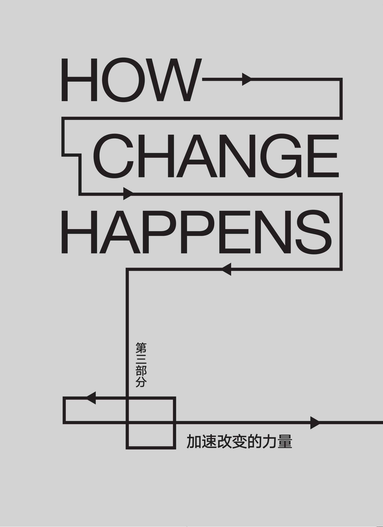

# 第12章 透明度

输出透明度与输入透明度之间是存在差异的。例如，交通部门完成的一项关于减少高速公路事故死亡人数的政策的详尽研究；劳动部门针对工作场所含有硅土而存在的健康风险所进行的一项分析；环保机构出台了一项通过减少机动车的使用来降低温室气体排放量的规定，或是实施了一项对违反水源保护规定的行为采取强制措施的相关政策。这些都属于输出透明度。

政府也可能意识到了一些特定的事实在大部分情况下应该归于输出，至少应被视为某种信息整合过程中的产出。

在以上情形中，与输出相关的透明度都可被视为一种助推。这是可以被设计从而对私营机构产生影响的。例如，通过激励公司更好地经营使社会变得更安全，或者通过向消费者和工人提供帮助来规避风险。当公职人员的表现不尽如人意时，通过曝光公职人员或其服务对象的情况，透明度同样可以为政府提供助推。

假设能源部门的公职人员和环保组织人员已经针对实施什么样的政策才能减少温室气体排放交换了意见；或劳动部门的相关负责人已经加快了针对暴露于含有硅土的工作场所存在的健康风险的讨论，并提出了更好地防范这些风险的相关对策。这些不同的观点便属于输入。

可以肯定的是，一定还存在一些中间的情况。环保部门可能会得出结论：某种物质是具有致癌性的，并且从某种意义上来说结论是一种输出，但是对于随后的监管判定来说这又是一种输入。交通部门可能对于批准修建一条高速公路所带来的环境影响已经取得了确定性的结论。这看起来应属于输出，但这些结论对于是否决定修建这条高速公路而言又应属于输入。《美国国家环境政策法案》（The National Environment Policy Act）可以被视为美国环保局对以环境影响的判定形式来公开输出的一种要求，但这些输出又以法律的形式被输入到了最终该做什么的决策之中。有些输出就是输入。抽象地说，这类情况可能会被归于输出或输入，抑或既是输出也是输入。正如我们所看到的那样，为这些情形定性的适当方法在一定程度上取决于公众是否或如何从这些披露中获益。

若承认这些重要的中间情形的存在，我将提出自己的两个观点。其一，对于输出而言，有关透明度的争论一直是异常激烈的。如果美国政府掌握着博伊西（Boise，美国爱达荷州首府）的犯罪情况、密歇根弗林特地区的水质情况、拉瓜迪亚机场的安全保障情况、特定种类玩具所含有害物质的情况或无人驾驶汽车的影响等，在人们的要求下确实应该对这些信息予以披露。人们想从这些信息中获益，即使在他们没有提出要求的情况下，这些信息也应当被披露。在所有这些情形下，透明度都具有重大意义。有时公众能在自己的日常生活中使用这些信息，同时输出透明度可以使问责制更加明确，进而使透明度得到提升。大部分情况下，输出透明度的成本微不足道；其二，从全世界范围来看，各国政府都理应在输出透明度方面做得更好。特别需要指出的是，除非存在某种特定的原因需要对其保密，否则至少在公众能够或将从中获益的情况下，政府应当让公众可以自由地获取输出信息。

然而，输入透明度却要复杂很多。披露的成本通常都很高昂，而收益却很低。并且在任何情况下，输入透明度在定性的角度上都不同于那些被认定为输出透明度的情形。我们有充足的理由捍卫内部审议过程，最重要的是确保公开、坦诚和信任。除此之外，我们通常无法确定公众是否能从可见输入中获益良多，这不仅是因为输入的庞大体量，且重要的是它与任何其他事情常常是不相关的。在非常规情形之外，公众通常获益甚少，甚至获益为零（除了逸事等情况）。更能将这个观点说清楚的另一种说法是，虽然那些寻求吸引他人眼球或让其政敌难堪的人通常偏爱输入透明度，但公众通常并没有从中获得什么好处。

可以确定的是，输入透明度可以是信息性的，同时输入也可以具有重要的历史价值。如果公众知晓交通部副部长对燃油经济性法规的相关内容的看法与部长不同，我们就会发现这种意见分歧将会破坏内部的一致性。但是准确地说，公众到底知晓多少？公众知晓这些信息又为何重要呢？我们必须承认的一点是，在一些情形中，输入透明度是一种积极的主张。特别是存在腐败或接近腐败的情况下，且当相关输入具有真正的历史重要性（并且当这些披露能够减少错误的发生）时，这一点就更为突出。国家需要对此进行登记。但是，有关输入透明度与输出透明度的争论内容有着很大的差别，输入透明度往往站在了弱势群体的一方。

从以上讨论中我们可以清楚地看到，对于该问题的解决途径，我的意见与福利主义者一致，即透明度的成本与收益是什么？对透明度的成本与收益进行量化可能确实很难，但我的意见是，当透明度或多或少成为必要时，对其成本与收益进行某些估算是不可或缺的。对于那些在该语境下不愿谈及成本与收益的人来说，弄懂这些词条可能是非常有用的。这不是为了形成某种数学意义上的约束，而是为了凸显针对人类竞争的最后结果提出具体问题的重要性。至少对于疑难问题而言，我认为它们要比“合法性”和“知情权”等抽象概念更具现实意义。

### 透明度的作用

经济学家阿玛蒂亚·森（Amartya Sen）认为在世界历史的长河中，具有民主表达和自由选举的社会体系里没有发生过饥荒。<sup>1</sup>森是基于经验对其主张进行说明的。在论述的开始他就认为饥荒是一种社会产物，而不是因食物短缺导致的不可避免的结果。将来是否会发生饥荒，而不仅仅是食物短缺，取决于人们的权利，即人们能够得到什么。即使是在食物有限的情况下，权利依然能够使得食物以某种方式得以分配从而保证无人挨饿。

但是，政府在什么时候会采取必要措施来避免饥荒呢？答案取决于政府的动机。民主体系中，人们有言论自由的权利，政府就会肩负着某种压力，他们要确保人们在一般情况下能够获得食物。但一个没有民主表达和自由选举的非民主体系，政府就有可能会规避公众的问责，进而不必对饥荒负责。政府公职人员将不会被披露，且不会承担失业的风险。

接下来我们将要讨论的是一个有关可自由表达的运行良好的体系、相关信息披露（输出）和公民利益之间的关系的重大课题。言论自由和信息自由算不上什么奢侈品，仅是满足大部分受教育阶层的需求而已。相反，这却提高了政府真切地为人民服务的可能性。这个课题告诉我们，有些美德不仅仅关乎自由，还关乎拥有言论自由和信息自由的经济目标。<sup>2</sup>

近年来，大部分特别突出的透明度举措都与输出有关。一个具有披露性的案例是关于全球定位系统设备的。1993年，美国前总统克林顿选择通过数据公开和可用的方式解锁相关数据。这使得全球定位系统设备成为人们日常生活中的常备工具。数据的可用性以非常重要的方式帮助了无数的人，甚至挽救了很多人的生命。从专业性角度来说，一台全球定位系统设备使我们的生活变得更加具有可导航性。如果我们能够将可导航性看作一个更具普遍性的观点，就能够看到披露输出的诸多价值。与车辆安全座椅、犯罪、空气和水质量等相关的信息都可以被看作全球定位系统设备的类似情况。夸大地说，它们能够告诉人们在其想要去的方向上该如何走。

在美国前总统奥巴马的任期内，其政府一直将透明度放在首要位置，总统在透明度和其他价值之间做了潜在的权衡。我虽对此存在很多的疑虑，但我还是坚持这一观点。美国政府早些时候发布的总统备忘录可以作为这一优先性的标志，为此还特别出台了《信息自由法案》（Freedom of Information Act）。该备忘录确定了“一个明确的假设：在质疑面前，公开性占优”。更为重要的是，该备忘录还补充道：“政府部门应该坚定不移地使信息公开化，而不是非要等到公众提出特定的要求时才这么做。”为此，美国司法部及行政管理和预算局（Offce of Management and Budget）都出台了新的指导性制度，旨在更好地执行该备忘录的指导性原则。

两份结果性的文件都需要人们密切关注，但以我的目的来说，行政管理和预算局的指导性制度值得特别关注。<sup>3</sup>备忘录要求美国政府的各相关部门在互联网上披露信息。同时，备忘录还补充道：“各部门应积极主动地运用现代技术宣传有用信息，而不要等到公众在《信息自由法案》框架下提出特定要求才那么做。”也许更为重要的是，这要求各部门制订一份公开的政府计划公布在官方网站上，旨在“使开放的政府文化被创造出来并得以制度化”。开放的政府计划要求相关部门“在网络上以公开的形式发布至少3组具有高价值的数据”。这些数据被定义为“能够提高各部门的问责制和责任制，能够改善公众对各部门及其管理的认可，能够进一步让各部门履行其核心使命，能够创造出经济发展机会，或能够满足那些通过公共咨询得以确定的公众需求”的信息。

从抽象意义上来看，这一供给是否包含输出透明度或输入透明度还不是很明确，但是到目前为止，前者一直在实践中保持着首要地位。<sup>4</sup>高质量的数据一般与输出有关。从2009年开始，美国相关网站已经成为公布这些数据的重要途径。这在行动上应归于输出透明度。网站目前提供关于农业、金融、医疗、教育、能源等诸多方面的信息和数据。只需要通过点击网站相关内容，用户就能找到“准点数据，即能够体现各航空公司的飞机准点率及航班延误原因的数据”“家庭在儿童身上的支出数据，可用来预测将孩子从出生养育到17岁在主要预算要素上的成本”，或召回产品的详细信息。类似的信息发布还有很多，它们的重点都在于政策制定或信息集聚行为的产出。

因此，私营机构开发了无数的应用程序来为人们提供在实际生活中会用到的信息，例如能够为人们提供实时空气质量信息的应用程序。

美国政府部门数据网站上公布的信息具有两个独立的目的。第一，使人们能够在其日常生活中更好地利用这些信息。如全球定位系统设备，这类信息在大部分情况下可使人们的生活变得更简单也更具导航性。这类信息在手机上的应用产生了超乎想象的具有现实意义的结果。如果从更广泛的角度来看待可导航性，我们可以将信息披露看作一种在无数的领域中帮助人们到达其目的地的方式，可使人们节省开支并减少过程风险。当然，目前该网站的收益尚不能量化，但毋庸置疑的是，我们正在从信息披露中以具体的方式获益。参照全球定位系统设备带来的益处，这些都是很好的具有说服力的案例。

第二，输出信息的发布能够促进私营和公共机构的问责性。大法官路易斯·布兰代斯曾说：“阳光是最好的防腐剂”。<sup>5</sup>如果洛杉矶的空气质量非常糟糕，如果一所特定的大学学费奇高，如果一所营利性大学的学生一毕业即失业，如果圣地亚哥的饮用水不安全，或者如果一家公司已经召回了很多的玩具，透明度就是带来改变的催化剂。透明度为我们提供了问责性，而当人们开始为其行为负责时可能就是一种提高。<sup>6</sup>这一点对于公共和私营机构都是适用的。透明度可以使公民知晓公共机构里的公职人员应采取的行动。例如，应该用多久处理一项审批或公职人员要为美国圣安东尼奥（San Antonio）的空气质量问题负多少责任。同时，透明度还可以告知公民应采取的行动。例如，披露产品召回或安全座椅的评级信息。在任何一个事件中，透明度都可以刺激相关机构或个人改善自身行为。

### 信息披露的根本使命

美国行政管理和预算局备忘录中最为有趣的部分就是让各相关部门考虑是否应通过披露信息来深化自身的“根本使命”。这是一个格外重要的举措，可以使各部门在未来的工作中广泛地使用披露并与其保持密切相关。

在环境政策方面，最著名的案例就是有毒物质排放清单（Toxic Release Inventory）。这一清单最大限度地通过簿记手段确保美国联邦政府可以掌握有毒物质的排放情况。令很多人感到惊讶的是，有毒物质排放清单成了一项成功的规制手段，因为相关公司都不想出现在各州的“排放黑名单”中。<sup>7</sup>问责性在减排方面起到了促进作用。在一定时期内，美国职业安全与健康管理局（Occupational Safety and Health Administration）遵照这一清单在其相关网站的显著位置公布了美国工作场所中员工死亡的信息，并将这些死亡员工所在公司的名字也一并公布了出来。美国环保局也通过相似手段公布了温室气体排放清单来促进减排。这就是我们在前文中所说的助推的应用，相关部门通过助推影响了公司的行为。

在上述所有这些案例中，政府都是将公职人员所掌握的信息披露了出来。当然，我们可以想象一下如下情形，即由公共机构提出适用于私营机构的有关输出透明度的要求。这类要求一般不是通过信息自由的观念被组织起来的，但它们与透明度有关并且也能够改善重要部门的使命。例如，《平价医疗法案》颁布后，美国食品药品监督管理局（Food and Drug Administration）要求所有的餐馆都要将店内所售食物的热量值情况公布出来。从早期的一些成果来看这项措施前景良好，比如可以使确实需要减肥的人群的身体质量指数明显下降。<sup>8</sup>我们也希望这些针对披露的要求能够影响生产者和消费者的行为，并且有证据表明热量清单正在促使餐馆为消费者提供更加健康的食物。

这里只对通过输出透明度来加强各部门职责的信息披露进行少量说明。当然，其中的一个实证问题便是透明度是否强化了各部门的职责。当然在很多情况下，答案是肯定的。<sup>9</sup>因为输出透明度的成本通常很低，所以在这一点上做出的任何推测都可以轻易找到可供支撑的理由。

在讨论问题时，我的论述范围通常比较宽泛，甚至有些过度。我的建议是，在福利背景下，输出的披露都是有正当理由或假设是有正当理由的，虽然实际也并不总是如此。简单地说，我们可以想象倘若输出的披露会产生低收益或提高成本，那么情况就不同了。提及成本，我们可以考虑一下行政管理和预算局备忘录中的话：“该指导文件没有任何内容可以取代那些由行政管理和预算局局长在决策信息之前审阅和澄明的现行规定。这些规定涉及立法、预算、行政管理和其他规范性文件。进一步说，该指导文件没有任何内容建议以公开性的推定来取代关于信息的立法保护，即信息公开会损害国家安全、侵犯个人隐私、违反机密性或损害其他真实存在的利益。”这些确实是行业话术，但是却指出了很多重要的限定条件。

在很多方面，《信息自由法案》都明确了这些限定条件，抑或更多的限定条件。没有人会怀疑政府将会用信息来做一笔大生意，并通过信息披露来危害国家安全。就算可以被看作一种输出，信息也应处于保密状态。同时，政府也掌握着受隐私法保护的“个人身份信息”。通过在透明度和隐私之间的权衡，某些涉及个人隐私的披露是不被允许的。某些披露可能会因贸易机密或其他的特权信息而妥协，不予公布。如果信息披露不是自动的，保证透明度的特定行为将面临金钱和时间方面的成本。

从收益角度做区分也是非常重要的。从原则上来说，如果估算的成本是零，则没有必要坚持所有的输出都披露出来。但是，如果我们以案例为基础进行反问，是否披露特定的输出将可能产生收益呢？例如，针对消费者和工人的一些案例。政府数据网站上发布的数据，有些确实收益甚小或根本没有收益，所以人们通常不会关注这些数据。福利主义者的分析主张以特定的调查来分析问题。当然，问题在于这些调查可能都不具有可处理性。当披露被讨论时，有关收益方面的预测可能是非常困难的。我们并不知道人们会利用信息或其他事物做些什么。私营机构中到处是心思精巧的“炼金术士”。我们无法预测他们在其中能搜寻到什么样的有用信息并将其转化成财富。

从现实中我们可以清楚地看到，各部门会合理地判定出哪些属于高质量数据，并对其进行广泛的解读，然后尽快地将之公布于网上。同时，各部门发布有利于输出披露的一般性推定，并发布针对推定可能会应用到的领域的直觉性理解。值得强调的是，将相关材料按时在网站上公布的自动化程度是非常有益的。

在高质量数据方面，各部门应通过两个问题来进行自查：一是，人们在日常生活中会从这项信息中获益吗？二是，信息的披露是否以改善公共或私营机构的表现形式，提高了其问责性？在2009年的美国总统备忘录中有这样一段话：“政府不应因为公职人员可能因信息披露身陷囹圄或想象中的恐惧感而对信息进行保密。不应基于保护公职人员个人利益的动机而不予披露信息。这实际上会错失使官员各司其职的机会。”这些话重要且正确，但同时也具有关键性的先决条件。接下来我们将对这些先决条件做进一步的讨论。

### 输入透明度

1980年，当我还在为美国前大法官瑟古德·马歇尔（Thurgood Marshall）做书记员时，记者鲍勃·伍德沃德（Bob Woodward）和斯科特·阿姆斯特朗（Scott Armstrong）曾出版过一本有关最高法院的书，书名叫作《三兄弟》（*The Brethren*）。我从来没有与伍德沃德和阿姆斯特朗交谈过，同时我也自信地认为和我一同工作的其他3位书记员也没有。但是许多（大部分或可能是全部）书记员都决定对该书的作者持开放的态度。作者在书中对马歇尔法官进行了极其不准确的描述，这严重损害了其形象。显然，马歇尔本人对此非常失望。我认为，他之所以失望并不是因为书中那些负面的、不公正的、不准确的描述，而主要是因为他把这种描述看作一种对忠诚的亵渎。我认为，将他对我们讲过的话披露出来是忠诚的一种体现。他曾说：“我不会试图去改变与书记员互动的模式，但是你们是否会亵渎我的这种自信，就全凭你们的良心了。”

在我于2012年离开白宫以后，很多记者及新闻界以外的人士曾向我打听白宫内部的情况。谁跟总统说过什么？谁又没有同意谁的意见？如果哪件事情发生了或没有发生，谁希望这件事没有发生或发生呢？谁胜了，谁负了？当然，这些问题我一概没有回答过，但他们这种令人震惊地不断询问、欲知其详的坚持是没有任何错误的。这让我回想起与华盛顿邮报的一位大记者的精彩对话，她一直揪着谁不赞成谁这类问题不放。最后，我建议她将其最感兴趣的问题（如环境政策）的实质性内容写出来。但她似乎对这个建议没什么兴趣。

正如我理解的那样（并与标准说法相一致），输入既具有事前决策性又具有审议性。这些都是独立的要求。之所以说输入具有事前决策性，主要是因为从任何方面看它们本身都不是官方决策，而是先于官方的决策存在的且意在让官方知晓。如果一位就职于环保部门的行政助理建议其领导设定十亿分之六十，而不是十亿分之六十五的标准值，则这样的沟通就具有事前决策的性质。输入具有审议性是指，它们是关于该做些什么这一议题的决策过程的一部分。

我承认，即使有上述说明，我们还是能想到很多难以理解的案例。例如，当对一则“关于二氧化硅相关风险的报告”进行汇编时，这则报告将成为纳入法规的一种输入。如果立法书记员正在交换如何处理一项平权运动争议的备忘录，便是与输入有关了。如果白宫内的人正在讨论有关开放政府备忘录的内容，这就是正在处理输入。如果白宫的公职人员正在与美国食品药品监督管理局的公职人员谈论如何处理特定哮喘药物的使用风险问题，这也是一种与输入有关的行为。

关于输入，针对披露的讨论已发生了显著的变化，并且在两个富有争议的方面也被削弱了。一是，披露的收益通常是非常低的（不是一直如此，但却总是这样）；二是，披露的成本是非常高的。接下来，我会继续讨论很多关于其主要限定条件的明确的观点。

### 谁对谁说了什么

从公众的立场来看，含有输入的内容通常是没有吸引力的。对于那些相信透明度的人来说，具有吸引力的可能是那些看起来富有争议的、不合情理的，甚至是令人震惊的观点。但是，输入的绝对数量及其范围却是令人怀疑的，并且违反了公众将从这些输入的内容中获益的信念。如果这些输入有趣的话，那可能是因为一种并不完全支持披露的原因，即为了讨论的目的，有些人可能会谨慎地给出一个想法，而这个想法无论在过去或现在都确实是个坏主意。我们可以想象，这个想法会被排除掉，所以这永远不会成为一种输出。总而言之，让全世界看到这个想法是重要或明智的吗？

或者让我们来考虑一下美国联邦管理事务的一般性领域，其中最为重要的就是这些管理。一般情况下，每年会有5000件行政管理事务必须通过美国信息与规制事务办公室（Offce of Information and Regulatory Affairs）进行处理。这些事务大部分都没有在报纸或互联网上被公开讨论过。这些内容在发布前往往都要先进行充分的内部讨论，留存相应的书面文件、电子版文件及电子邮件，同时还会遗留部分争议问题和质疑。这是审议过程的典型范例。很多人在此过程中表达了很多的观点。大多数时候，披露审议过程中的内容的收益都微乎其微。

在美国联邦政府内部，与管理过程的正确性相关的很多讨论都是如此，有时甚至更为典型。电子邮件的数量非常大。正如上述助理案例，他们可能会让想法悬而未决，收集一些暂时性的反馈信息并报告给相关人员。除了那些可能对某些确实存在的细枝末节感兴趣的人，或那些企图中伤、损害或使他人尴尬，以期制造出政治骚动或揭露某种丑闻的人，一般情况下，披露根本没有任何目的性。

### 输入透明度出现的两种条件

通常会有两种主要的条件来帮助观察者解释输入透明度出现的原因。我们需要承认，在一些行政管理事务中，这些前提条件中蕴含着或被察觉到将蕴含着大量的权力因素。在腐败的或无效的行政管理中，他们的权力得到了极大的提升。

#### 有关违规或违法的争论

公共披露可以为可论证的违规争论提供一种事前赌注性的威慑，并且还能够提供一种具有前瞻性的事后纠正。至少，这能让公众知道他们是如何被管理的。在最坏的情形下，输入包含了腐败或犯罪，而我们的人民当然有权知道这些。

例如，假设反对一项决定不是因为它本身是个坏想法，而是因为这个想法会触犯行为人或一个强大利益集团的利益，或受到某一知名议员的反对，继而在行政管理中产生不好的结果。确切地说，此类事件会经常出现，并且这也是我们能够想象得到的最坏的输入。我们暂且规定这样的争论是可反驳的，至少公众有知道的权利，原因在于该争论可能会损害对公共利益的追求。披露可能会降低这种反对意见被表达出来的可能性，这可能是一件好事，并且无论如何这都将有助于建立问责制。从这个特定的角度来看，关于信息阳光化收益效应的有吸引力的争论会被应用于输入透明度，也会被应用于输出透明度。该争论在更糟糕的输入情形中是最激烈的（读者可以发挥自己的想象力或在历史中寻找答案）。

可以肯定的是，披露的主要作用是将反对的核心从电子邮件和书面文件转移至电话上。在美国联邦政府内部已经发生了很多类似的事件。如果人们不愿意使其沟通的内容被披露给公众或议会，他们会说：“打电话给我吧。”从我自身的经验来看，这通常是无罪的；这里面没有包含任何违法行为，但是这确实与某些敏感问题有关，如在电子邮件中没有被表达清楚的一些强烈的反对意见。实际上，这里存在着一项重大风险。如果内部讨论潜在地倾向于披露，从书面向口头的转换可能会带来损失。这些损失将通过减少经济、法律或其他方面的精准分析的形式体现出来。确实，输入披露能对其产生“洗白”的有利影响，或者能使所有的事情都变得更清白。

毫无疑问，对于违法或违规输入的担忧将引发有关输入透明度的争论。假设，你坚信，某些过程是存在腐败、丑陋或舞弊——这些会经常出现或者已成为过程中的一个因素；你坚信，强大的私人利益集团正在影响美国联邦政府的管理过程，或者对特定利益群体和集团负责的公职人员只是在符合那些集团利益的方向上推进产出——你当然希望能终止这些现象。然而，如果不能直接终止这些现象，你可能会坚持认为输入透明度是一种使其公之于众的渠道。那么，阳光可能就是最好的防腐剂。<sup>10</sup>

的确存在着一种风险，就是你会简单地把相关影响隐藏起来。但从原则上讲，这是一种次要担忧。至少我们可以说，将内部过程置于公众的审视之下，是一种值得赞赏的做法。对于那些因“水门事件”而进入公众视野的人来说，美国前总统理查德·尼克松的违规行为就是一个范例，一定程度的输入透明度对于查获这些违规行为是非常必要的。

#### 从错误中吸取教训

只要记者和历史学家能对所发生的事情进行记述，他们便可以从所见的相互让步中获益。这可能更像是一种抽象的学术收益，但是人们及公职人员的确能从历史中学到一些东西，并且这种所得也能产生有价值的纠正作用。历史的记载有助于发现曾犯下的错误，而在理解这些历史记载的过程中，输入也是必需的。政府为何会以作为或不作为的形式犯下重大错误？要回答这一问题，输入透明度是必不可少的。它能产生一些与群体渎职、制度盲点及制度改革需要等方面相关的警告性信号。

例如，假设美国政府对于防止种族灭绝所做甚少。<sup>11</sup>如果没有输入的权限，那么我们就很难甚至无法对相关的失败经历进行记录。一旦这些失败被记录了下来，人们在未来就有可能逐步减少类似情况的发生。从这个角度看，输入披露的收益也可以是非常高的，至少在特定的领域是这样的。

但是，还是有一些与上述观点相悖的要点。在很多情况下，输入披露是零收益的，并且也没有降低未来犯错误的风险，甚至还带来了失真的风险。假设人们有进入公职人员（如环保局助理管理员或公民权利助理司法部部长）的电子邮件系统的权限，同时假设电子邮件中含有抱怨环保局管理员、司法部部长和白宫公职人员等的内容。人们会发现，电子邮件可能反映的是特定的某一天的情形或心境——这可能仅是基于作者对事实并不全面的理解，也可能是一种发泄形式，或只反映了一种严重扭曲的观点。

一些记者经常从各种指控和丑闻的传播中获得工作的快感和收益，向公众传播有关内部分歧的披露就变得特别具有吸引力。这确实是属于我们之前提过的八卦新闻的一种形式。受众可能都喜欢八卦新闻，从这个维度上看，这也算是一种收益。但是，指控和丑闻传播对于公众来说却根本没有什么收益。当然若是真实存在的丑闻则另当别论。

### 输入透明度的成本

对于输入透明度而言，最明显的问题就是披露可能会降低思想开放程度和打击公众直率表达诉求的欲望。简而言之，詹姆斯·麦迪逊抓住了其中的一些关键点，其观点如下：

起草宪法的最优惯例便是围坐在一起，因为人们的想法千差万别，所以应在各种想法还没有形成统一的体系之前进行长时间的激烈辩论。同时，各成员之间也可以相互交换意见，并基于求同存异的精神在最大程度上达成共识。如果成员一开始就进行了公开承诺，他们就会基于一致性而要求自己坚持自己的立场。相反，若进行的是秘密讨论，则没有人会觉得自己有义务保留自己的原有观点，除非他对参与辩论的成员的行为举止的真实性和真相感到满意且支持公开辩论。……没有任何一部宪法是在尚未经过公众辩论的情况下就得以实施的。<sup>12</sup>

在任何审议过程中，人们的想法都是多样且粗糙的，并且在大部分情况下都是“基于妥协和接纳精神而获益”的。一旦人们进行了公开承诺，他们可能就不会再转变。保密能促进辩论的开放性。所以，麦迪逊才得出最后的重磅级结论：“如果进行公开辩论，那么没有一部宪法能在大会上通过。”

麦迪逊没有强调的是，输入透明度会导致人们言不由衷。这会阻碍公众直率、自由地表达其真实想法。从该角度来看，这会使各群体获取的信息比其需要的要少。在运行良好的审议流程中，想法形成阶段和结论得出阶段是有着严格的界限的。在想法形成阶段，很多事情是公开讨论的，即使这些事情都被证明是荒唐的或无法容忍的。人们会对获得的某一想法表示赞同，却可以忽略该想法是否有机会得以实施。如果输入是透明的，那么想法形成阶段就会受到更多的限制。

行政特权观念背后的核心便是确保公众能够直率地表达诉求。<sup>13</sup>最好的情况是，输入透明度会引导人们进行口头沟通而不是书面沟通。事实上，通过《信息自由法案》的一个结果是减少了对电子邮件和书面文件的依赖。无论在美国共和党还是民主党的行政管理中，众所周知的是任何以书面形式呈现的内容几乎都能够在《纽约时报》中找到。这导致人们不愿意以书面形式进行沟通。最坏的情况是，输入透明度会导致某些特定的事情完全不被提起。

但降低公众坦率程度并不是唯一的问题。鉴于媒体和政治对手的动机，输入披露会带来极其不利的干扰。这对于自治是具有破坏性的。倘若不关注输出（如关注如何减少早产死亡），公众的注意力可能会集中在那些似乎能让一些人变成罪犯或不法分子的评论上，或集中在将任何结果性的决定置于最不受人欢迎的境地的那些意见上。怀疑论者可能会满怀激情地回应称，剥夺公众获取信息的机会是非常专断的家长主义或更糟糕，因为这会使他们产生误解或过于关注某个信息。一种观点是，真实信息的获取应受到意见自由市场的制约。但是，在这个范围内看，问题并不在于公众误解，而在于意欲火上浇油的那些人的行为动机。这确实存在着风险。

### 输入透明度的分类账

提到输入透明度，像分类账两侧的不可通约的数值那样，将其置于单一度量之下并不是一件容易的事情。它的收益通常很低。当然也存在例外，如当其包涵非法动机、腐败和犯罪信息，以及可以帮助避免出现大规模或灾难性错误的历史记录时。其成本可能很高，但总是这样吗？

必须承认的是，输入的成本会随着时间的流逝而降低，并且一旦相关人员不再担任公职，成本就会变得比较低。唯一需要告知行政管理和预算局负责人的真相就是，无论他说了什么都会出现在当晚或明天的报纸上。另一种完全不同的说法是，在未来的某个日期或在行政管理工作完成后，出于保护国家安全、个人隐私或其他价值方面的考虑，将会保存有关内部沟通的公共记录。实际上，《总统记录法案》（Presidential Records Act）<sup>14</sup>开创了此类事务的一种实现途径（中间有5年的间隔）。通过这一途径，披露的成本得以大幅降低。但它们不是零，原因在于坦率表达将遭受冷遇，并且人们的名誉受到了错误性地中伤。但是，从获得某些类型的历史记载价值的观点来看，这种途径并非没有道理。我的目的不是针对具体的实践和提议获得确定性的结论，而是对一般性观点进行概述以帮助人们识别适当的权衡之术。

输出透明度和输入透明度之间存在着很大的区别。对于输出而言，透明度可能异常重要。一个核心理由就是，政府通常掌握着人们可以使用的，能使生活更具可导航性和减少严重风险的各类信息。政府不应该把这些信息攥在自己手里。另一个理由是，将信息公布于阳光之下就像是在消毒。无论信息中是否含有政府或私营部门的绩效表现内容，披露都可敦促其更好地完成绩效。

这就暗示我们继续和强化政府信息网站工作的重要性。在接下来的无数情境中，政府都不应该等到《信息自由法案》提出要求才有所作为，而是应将信息公布于网站上。但这并不意味着所有的输出都要公布在网上，而是当输出对公众来说可能存在价值时，应向公众公布。在未来，我们应期待在这一方向上取得重大进展，使其自动化程度得以显著提升。

输入则应该被归于不同的类别。在非常规环境之外，真正起作用的是政府实际做了什么，而不是谁对谁说了什么。大部分情况下，如果美国公众知道州助理不赞同员工领袖的意见或州助理关于贸易协议的想法，或知道在如何治理温室气体方面存在着激烈的分歧，他们似乎也无法从中获益。最为明显的是，这将导致人们保持沉默或通过不能被记录的方式进行沟通。更详细地说，这将使公众的注意力从关乎政策和事实的重要事情上转移到关乎宫斗游戏这类不那么重要的事情上来。同时，输入透明度能将热点集中于有问题的、违规的或腐败的行为上，并提供必备的历史记载。人们可以以史为鉴。对于当前的行政管理而言，熟知以往行政管理的错误之处是至关重要的。

我的分析框架自始至终都是福利主义，一直在追问信息披露的成本与收益。需要承认的是，我们应对福利主义这一观点加以具体说明，且很多人会以不同的基础对其展开讨论，如关于政治合法性的观点。除此之外，在福利主义框架下，有些输出透明度是没太多意义的；而有些输入透明度是完全正当的，甚至是不可或缺的。当我们言及分类时，并不是指那些个别情形。但是，分类为我们提供了一定的方向。输出透明度应处于努力争取信息自由的核心位置。我们对这方面的需求会与日俱增。输入透明度也可以是很重要的，特别是当行政管理行为结束之时。但是，在处理输入透明度时需要格外谨慎。

# 第13章 预防性原则

在世界范围内，人们都对风险规制这个简单的理念产生了浓厚的兴趣：若存在质疑，应遵循预防性原则。<sup>1</sup>摒弃会产生有害风险的步骤。在确定安全之前，保持谨慎；不要求有明确的证据。用一句格言来说，就是“宁可事先谨慎有余，不要事后追悔莫及”。

在日常生活中，这类请求是很合理的，实际上这是人类理性的一部分。干预自然过程可能是有害的，而且我们通常拒绝改变现状，因为害怕会有副作用。难道不应该遵循理性管理者的路径吗？很多人认为应该这样。因此，预防性原则便成了社会进化的组织原则。在欧洲、美国及其他地方，这个原则被那些意欲加强环境保护、保护自然，以及减少健康和安全风险的人所援引。在很多时候和很多地方，这个原则已成为社会级联效应的受益者。它在社会中得以迅速传播。飞地审议者总是援引这个原则，同时努力使他人相信这是一个很好的框架。

在这里，我的核心观点都是概念性的。预防性原则最严峻的问题在于它是不连贯的，其目的是给出指导，但却没有做到，因为预防性原则也同样谴责自身所要求的那些特定步骤。该原则要求的规制总是会给自身带来风险。这样一来，该原则就同时禁止了自身的授权。因此，我意欲挑战预防性原则并不是因为它会导向坏的方向，而是因为它根本就没有产生任何的导向作用。该原则因可能会导致社会瘫痪，禁止规制、不作为及两者间的每一个步骤而被认为是有危害性的。只有当我们对与风险相关的很多因素视而不见，只关注风险的一个狭小子集时，预防性原则才能有所帮助。保护自然通常是有意义的，但预防性原则却并未给出一个有益的架构来提醒人们该在什么时候为自然提供多大程度的保护。

如果这一切都是正确的，我们又该如何解释其巨大的影响力，以及人们普遍认为的它可以也应该被用来指导监管判断的现象呢？我们应该承认其潜在的实用性价值，它可被用来处理对某些风险的关注不够充分的情况。有时候，它激发了人们挽救生命和改善健康所需的动力。毫无疑问，该原则被自私的政治活动家策略性地援引了。除此之外，我认为有关人类理性和认知的理解能为我们提供一些有用的线索。同时，科学研究的相关发现会清楚地阐明该原则的可操作性，解释它在其他方面令人困惑的吸引力，并提出了为何它应该被放弃或至少在实质上应该被重新构建。实际上，这些发现为这句古老格言“宁可事先谨慎有余，不要事后追悔莫及”的应用和隐患提供了更好的解释。与预防性原则一样，这句格言也遭遇了很多同样的反对。

综上所述，我竭力主张这类监管者应该采用一种更为广阔的视角。同时，在应用过程中，预防性原则是有缺陷的，因为它与自身的理念相冲突。可以肯定的是，很多支持该原则的人在设法防止忽视未来、无视那些正遭受最严重贫困的人的利益和对灾难性情形的漠不关心，并试图提出由监管者提供明确证据这一不可能实现的要求。但是，正如我们将会看到的那样，与其他更好地实现这些目标的途径相比，预防性原则是粗糙，甚至是不合常理的。

### 什么是预防性原则

对于那些对预防性措施感兴趣的人来说，最初的问题是预防性原则究竟意味着什么或其要求是什么？我们能够想象出一个具有连续性的理解。其中一个极端是理性的人不会反对较弱的版本。另一个极端是较强的版本要求人们对监管政策进行根本性的反思。

当然可以感知的是，最为谨慎和较弱的版本会给出如下建议，缺乏存在危害的决定性证据不应成为拒绝提供保护和对抗风险的理由。例如，即使我们无法证明接触低水平致癌物与对人类健康的不利影响之间存在相关性，实施控制也可能是合理的。因此，1992年的《里约宣言》（*Rio Declaration*）指出：“存在严重的或是不可逆的损害威胁时，缺乏充分的科学确定性不应该被用作推迟采取具有成本收益性的可以避免环境恶化的措施的理由。”

1987年，在伦敦召开了关于北海保护的第二次国际会议，会上发布的宣言也表达了同样的观点：“为了保护北海免于可能因最危险的物质而遭到破坏，与会国都接受将预防性原则作为一种必要的措施，可能要求各国采取行动以控制这类物质的排放，即使暂时没有充分的科学证据表明破坏与之有因果关系。”与此类似，《联合国气候变化框架公约》使用了更为谨慎的语言：“若存在严重的或不可逆的破坏威胁，缺乏确切的科学确定性不应被当作推迟采取监管措施的理由；可考虑的应对气候变化的政策和措施应参考成本效益，尽可能地实现以最低成本确保全球利益。”

1998年，由环境保护者发布的一份流传更为广泛的文件《温斯布雷德宣言》（*Wingspread Declaration*）更进了一步。文件称：“当某种行为对人类健康或环境造成的危害增加时，应当采取预防性措施，即使这之间的因果关系在科学上尚未得到证明。在这种情形下，这一行为的倡导者，而不是公众，将负有举证责任。”上文中引用的第一句话是《里约宣言》里的一种稍微富有攻击性的说法。之所以说它具有攻击性，是因为其没有局限于严重的或是不可逆的破坏性威胁。但是在举证责任倒置中，第二句话则是更进了一步。当然，一切都取决于举证责任要求出示的那些证据。

在欧洲，预防性原则有时被认为是一种更为强烈的方式，它要求所有决策都要有一个较宽的安全边际。一种定义认为，预防性原则是“当有证据表明损害可能发生时，就应当采取行动来改正问题，而不是要等到损害已经发生才采取措施。”<sup>2</sup>这里的“可能”一词至关重要。在大多数情况下，如果“可能”不需要一些概率阈值来加以界定，那么所有情况都会有“证据表明损害可能发生”。对比另一种更强硬的版本，欧洲第一届濒危海洋会议的最后宣言称：“如果要判定一项确切行为的‘最坏情形’足够严重，那么对该行为的安全性存在的一点点的担忧就足以阻止其发生。”<sup>3</sup>

预防性原则的较弱版本反映了一项不言自明的道理，即原则上的毫无争议。实践中的必要性仅体现在消除公众困惑或个人群体要求出示造成损害的确凿证据的自私诉求上（理性社会中是不会有这种要求的）。最弱版本的定义可能在实践中是非常重要的，但在原则上他们是无可厚非的，甚至略显平庸。因此，在这里我就不再对这类定义进行赘述。为了做更进一步的分析，我们将通过一种比较强烈的方式来理解这一原则，只要存在健康、安全或自然等方面的潜在风险，就需要进行监管，即使证据仍然是推测性的，或监管的经济成本很高。为了避免出现明显的荒谬，对于潜在风险这一理念的理解应当有一定的科学合理性。为了支持监管，某个地方的人敦促认真对待某个风险是不够的。但是，正如我理解的那样，在预防性原则下，阈值的负担是最小的，一旦达到阈值，就会有某种类似的有利于监管控制推定的事物存在。

我坚信，对于预防性原则的这种理解与某些最热心的倡导者的理解是一致的。并且，这种理解有相对温和的形式，也符合众多的法律规则。

### 自相矛盾的预防性原则

人们往往不愿承认自己对预防性原则的理解是极其模糊的。预防应做到什么程度才是合适的？就其自身而言，这一原则没有告诉我们答案。预防性原则常常是，但却不应该是无视成本的。人们也很容易对这种观点提出反对意见。有些预防性措施当然是不值得的，因为它们的成本太高收益却甚少，但这还不是最严重的问题。真正的问题是预防性原则根本没有为我们提供任何指导，但不是说它本身是错误的，而是该原则禁止了所有的行动方向，包括规制。它所禁止的恰恰是自己所要求的那些步骤。

为了理解反对意见，我们有必要对一些具体问题进行讨论：

· 转基因食品已很常见。<sup>4</sup>其风险目前还无法确定。有些人害怕基因改造会产生严重的生态危害；另一些人又坚信其风险极低，并且基因改造会产生更有营养的食物，并且能显著改善人类健康。

· 很多人害怕存在于地面上的核能，因为他们认为核电站存在各种健康和安全风险，包括大灾难。但是，如果一国不依靠核能，就只能依靠其他的替代性生物能源，特别是依靠燃煤的火力发电站。这类电站也会有自身的风险，包括与气候变化相关的风险。近年来，中国已依靠核能实现了温室气体的减排，并解决了一系列的空气污染问题。<sup>5</sup>

· 对海洋哺乳动物的保护与军事训练之间可能存在着冲突。美国海军进行过很多此类军事训练，可能的结果便是威胁海洋哺乳动物的生存。海洋中的军事行动可能确实产生了很大的危害，但是暂停这类军事行动的决定可能也会危害到军备（或政府认为如此）。<sup>6</sup>

在这些情形中，预防性原则为我们提供了哪种引导呢？人们很容易认为，该原则倡导了严格的规制管控。在上述情形中，产生严重危害的可能性是存在的，并且没有权威性的科学证据能证明这种可能性是零。让我们暂且把在这些情况下强制执行严格监管的预防性原则是否明智的问题放在一边。先来思考一个更为核心的问题：更为严格的规制是根据预防性原则的要求实施的吗？

答案是否定的。在上述情形中，有时我们会很容易发现严格的规制实际上与预防性原则是相冲突的。最简单的原因就是，这样的规制可能会造成严重的社会利益损失，并导致许多本不该发生的死亡。在某些情况下，规制消除了某个过程或活动的机会效益，从而引发了本可以避免的死亡。如果真是这样的话，那么规制便不再具有预防性。

让我们再考虑一下对食物基因进行改造的情形。很多人之所以反对基因改造，主要是认为“对自然的篡改”会对环境或人类健康产生一系列不利的后果。然而，很多其他的人不仅相信这些恐惧是毫无根据的，而且还相信如果不允许进行基因改造可能会导致大量死亡和更多死亡的小概率事件。原因在于基因改造一直秉持着让食物生产变得更便宜也更健康的信念。例如，让很多发展中国家获益良多的黄金大米。基因改造确实会产生收益或其收益超过了其风险，但这些都不是问题的关键所在。这种说法是指，如果从字面上理解预防性原则，那么无论是规制还是不规制都会触犯这一原则。

规制有时候会违反预防性原则，因为它会使替代性风险上升，其形式是因规制而出现或增加的危险。让我们来参考一些杀虫剂的案例。杀虫剂通常是被禁用的或被管制使用的，旨在减少对鸟类和人类造成的伤害。而禁用所产生的风险是，贫穷国家的人们可能会因此失去对抗疟疾的最有效的方法，继而给公共健康带来严重损害。

再如药品标签，这是在一种新药投放市场时由政府采取的一项重要的预防性措施。如果政府能坚持采用这一措施，就可以使人们避免遭受来自未经充分测试的药物的伤害，但是这也让人们无法获得那些特定药物的潜在治疗效果。那么，究竟是要求进行广泛的售前测试还是反其道而行之才具有预防性的呢？在预防艾滋病药物的情况中，那些支持预防性措施的人已经从更好地保护患者健康的角度敦促政府取消售前测试。顺便说一句，在新药方面，美国要比大部分欧洲国家更具预防性，但是因为这类药品无法在市场上售卖，美国也无法为那些本可以通过更快疗程根除的疾病提供预防性保护。更一般地说，明智的政府可能希望忽略与低水平影响相关的小风险，理由是预防性应对措施可能会引发恐慌，而这种恐慌超过了这些措施对健康带来的任何益处。

我们应该能够看出，所有值得践行的预防性原则都是具有麻痹性的。对于规制、非规制及介于两者之间的任何情形来说，预防性原则都是一种障碍。然而，这些因素当然会衍生出另一个问题：为何预防性原则这么有影响力呢？为何预防性原则又被广泛地宣扬呢？我认为，当且仅当实施预防性措施的人戴上眼罩时，这一原则才具备可操作性。也就是说，仅当他们只关注规制情景的某些因素，而轻视或忽略其他因素时，这一原则才可用。但是，这个建议又会引出进一步的问题：如果特定的眼罩是实施预防性原则的前提条件，那又该如何解释呢？若人们的注意力是选择性的，那他们又为何这样选择呢？

### 预防性原则的运作

有时，预防性原则的运作方式是将大自然本质上是和谐的理念与人类的干预可能会导致风险的观点相结合，正如预防性原则建议对杀虫剂或基因改造进行严格的规制一样。许多人担心，任何人为的干预都会造成现状的损失，这些损失会产生很大的影响，而收益则会伴随着质疑或至少被认为是不那么重要的。例如，“人为的干预似乎在对食品风险和污染进行判定时充当了放大器的角色”，即使“世界上自然灾害造成的死亡人数要比人为灾害多很多”。<sup>7</sup>研究表明，人类高估了杀虫剂存在的致癌风险，并且低估了自然致癌物存在的风险。人们还坚信，自然就意味着更安全，因此更倾向于饮用天然水而不是经过处理的水，虽然两者的化学分子式是一样的。<sup>8</sup>

对于大自然善行的坚信，在预防性原则的运作中扮演了重要的角色，特别是对于那些相信自然是和谐的或平衡的群体来说。实际上，许多支持预防性原则的人，似乎都特别关注新技术。大多数人相信，天然的化学物要比人造化学物安全。<sup>9</sup>大部分的毒理学家却并不赞同这个观点。在这一观点的基础上，当人们干预自然界时，预防性原则便会主张要小心谨慎。在这里我们能够根据以下内容发现一些可以帮助我们理解的内容：大自然包含了很多系统，并且对系统的干预会引发严重的问题。但是，对预防性原则的理解却存在着一个很大的问题：所谓的天然可能一点都不安全。<sup>10</sup>

“自然平衡”的存在是我们都熟悉的一个观点。但根据公平标准，这个想法是“不正确的”。<sup>11</sup>大自然本身就是“以变化为主要特征的，而不是恒定”，并且“大自然生态系统也是动态的”，其中所包含的理想的变化往往都是“那些由人类行为引起的变化”。<sup>12</sup>在任何情况下，大自然都是一个充满破坏的领域，包含着疾病、杀戮和死亡。因此，与大自然相比，人类活动必然或更系统性地比大自然本身更具破坏性的主张是不能成立的。显然，大自然的产物相对来说更安全的想法也是不对的。<sup>13</sup>在食品安全和健康的背景下，被很多人所推崇且创造出的每年可产生45亿美元收益的有机食品具有很多优点，但是否更健康却并没有定论。诚然，根据一种公认的有争议的观点，有机食品实际上“要比那些成长于人造化学物中的食物危险得多”。<sup>14</sup>如果预防性原则仅使人们对杀虫剂产生了怀疑而没有对有机食品产生怀疑的话，那可能是因为违背大自然而产生的健康风险更令人担忧。

我们面临的一些最严重的风险是大自然的产物。没有什么东西要比暴露于日光之下更自然的了。很多人不惧怕日光。但是，这样的暴露却与皮肤癌及其他严重的危害相关。烟草作为一种大自然的产物，每年却能造成超过40万的美国人丧命。上述内容都不是为了解决具体因素，因为这些问题的解决取决于与价值和事实相关的复杂因素。然而，对大自然善行的错误信奉有助于解释，为什么预防性原则被非常错误地认为能在分析中为我们提供非常大的帮助。

### 损失厌恶

人们都不喜欢损失。也就是说，与希望有所得相比，人们更希望不要遭受损失。<sup>15</sup>当预料到会有损失时，我们确实会感到惧怕。这种惧怕程度要远超当预料到会得到某些援助时的愉悦程度。到目前为止一切顺利。当个人和社会淡化源于现状的潜在收益而专注于潜在损失时，问题就来了，因为这会带来总体风险的增加和总体幸福感的下降。

在风险规制的背景下，有一个明确的推论：人们会密切关注任何新风险导致的或由已存在风险的恶化导致的损失，但是对规制带来的可预见性收益却漠不关心。损失厌恶通常能帮助我们解释是什么让预防性原则具有了可操作性。监管的机会成本通常非常小或根本不存在，但是该问题中的相关活动或实体的自付成本却是完全可见的。事实上，这是现状扭曲的一种形式。现状为我们标注了衡量得失的基准线，并且在这一基准下，与获得带来的欢愉相比，损失带来的不悦要严重得多。

如果损失厌恶是有效的，我们可以推测，预防性原则将会把人们的注意力引至某些风险造成的损失上，而淡化管控该风险所产生的可预见性收益。让我们再来强调一下上述美国案例，比较一下未得到充分测试的药品所造成的风险和该药品可能被延迟上市的风险。如果现实中存在机会收益，预防性原则将有可能为我们提供指引，尽管对此我曾提出反对意见。同时，被忽视的机会收益有时在应用预防性原则时呈现出的却是一个毁灭性问题。也许能挽救生命的药物的情况，恰恰就是我们说的这个情形。

损失厌恶往往与另一个认知发现密切相关：与不熟悉的风险相比，人们更能容忍熟悉的风险，即使它们在统计学意义上是一样的。<sup>16</sup>例如，即使在美国每年有数万人死于车祸，驾驶带来的风险也不会引起人们过多的担忧。这是因为人们将与驾驶有关的风险看作生活的一部分。相反，很多人对较新出现的风险表现出了非常强烈的担忧。例如，转基因食品及最近引入的化学武器和恐怖主义等带来的风险。造成这种不同现象的一部分原因可能是因为人们怀有这样一种观念，即面对新的风险，我们首先考虑的是其不确定性（我们无法确定坏结果出现的概率）而不是风险（发生的概率是可以确定的）。那么，当我们无法对风险进行衡量时，可能会变得更加谨慎，这也都是可以理解的。然而，个人和社会关注新风险的倾向却超过了理智的倾向。通常以不太充分的理由，通过强调涉及危害的一小部分区域就可以使预防性措施得以实施。

### 可得性启发式

进一步说，“同等频率下，容易被读取的案例的类别要远远多于不容易被读取的案例的类别”。<sup>18</sup>我们可以参考这样一项简单的研究，给受试者一份名人名单，其中既有男性也有女性，然后询问他们名单中女性的名字更多还是男性的名字更多。如果这一名单中的男性更出名一些，则人们就会认为男性的名字会更多；而如果这一名单中的女性更出名一些，则人们就会认为女性的名字会更多一些。<sup>19</sup>

这一研究是关于熟悉是如何影响案例的可得性的。一般认为熟悉的风险比不熟悉的风险更严重，例如与吸烟相关的风险被认为比与阳光浴相关的风险更严重。但显著性也是非常重要的。例如，从主观概率上讲，目睹一起房屋失火事故的影响，可能比在当地报纸上读到这次火灾所带来的影响大得多。<sup>20</sup>所以，当前事件比过往事件拥有更大的影响力。这一点能在很大程度上帮助我们解释与风险相关的行为，包括采取预防性行为的决定。人们是否会为自然灾害购买保险，在很大程度上受到了当前经验的影响。<sup>21</sup>如果不远的过去并没有发过洪水，居住在洪水易发地区的人们很可能不愿意购买保险。地震发生后的一大后果就是，为地震而投保的人数显著增多，但是随着关于地震的生动记忆逐渐淡去，保险购买量又会逐渐回落。值得注意的是，在这些情境中，可得性启发式的应用并非是不合逻辑的。保险和预防性措施都是非常昂贵的，并且大多情况下，先前发生的事情似乎是将来再度发生该事情的最佳可得性引导。可问题在于，可得性启发式会导致过度恐惧和忽视等形式的严重错误。

可得性启发式能帮助我们解释预防性原则的运行机制的一个简单原因是，有时人们认为需要采取预防性措施的一项特定风险是可以被认知的，而包括与监管自身相关的其他风险却不能。例如，我们很容易知道砷是具有潜在危险的，并且砷作为一种著名的有毒物质，还曾经出现在一部电影《毒药与老妇》（*Arsenic and Old Lace*）中。相反，在对砷的管制可能会导致人们去使用不太安全的其他替代品这一观点进行判断时，还存在相对更为复杂的智力层面的操作。预防性原则在很多情况下似乎是可以为人们提供导向的，原因在于其中的某些相关风险是具有可得性的，而其他的风险则几乎是不可见的。并且，当人们倾向于保护自然而反对人为干预时，通常都是因为干预的风险是可见且熟悉的，但是不干预的风险却不是这样的。

### 不确定性与不可逆性

代表预防性原则的一些核心主张包含以下4个合理的要点：第一，不确定性；第二，跨时间学习；第三，不可逆性；第四，科学家求知谦逊的需要。在这些要点的帮助下，我们可能会在更精炼和更合理的方向上去理解预防性原则。一个核心问题就是，什么才是解决“最坏打算”思维的合理措施。全面分析需要对决策理论中的一些复杂问题进行调查，因此这不是做全面分析的地方，但是有3点内容是没有争议的。<sup>22</sup>

第一，如果一项产品或活动没有多少利润，那么与利润丰厚的情况相比，针对预防性措施的争论会更加激烈；第二，如果一项产品或活动具有微不足道的风险（既考虑到其概率又考虑到不良结果的重要性），且如果这种产品或活动能产生丰厚的收益，则它就不该被禁止或监管（包括通过贴标签的方式）。第三，如果某种产品含有较小的（但并非微不足道）灾难性风险，同时收益很有限并且没有理由为此冒险，则对于禁止这种产品或对其进行监管（包括通过贴标签的方式）就会存在较大的争议。

这里还存在着一些更复杂的情形。第一，某一产品或活动具有重要的收益；第二，我们无法或很难确定灾难性的不良结果出现的概率，这便产生了不确定性而非风险<sup>23</sup>；或者无法确定与不良结果相关的损害，这便产生了忽略的情形。在这些更为复杂的案例中，平衡这个账簿的两侧并不是一件简单的事情，而对于消除最坏情形的方案也确实存在争议。<sup>24</sup>并且，如果风险是不可逆的（需要对不可逆的概念进行独立的分析），则与其解决方案相关的争论会进一步得到加强。对于更加完善的预防性原则或其他类似的原则，应当从不可逆性危害或灾难性危害的预防性原则两个角度，对其合理性进行判断。<sup>25</sup>

### 更宽广的视野下

我并不建议能够代替预防性原则的其他任何具体原则。但是，这里没有任何一项争论是支持阿伦·威尔达弗斯基（Aaron Wildavsky）的观点的。威尔达弗斯基是一位敏锐且富有影响力的政治学家，对风险规制特别感兴趣，同时也是一位预防性原则的反对者。<sup>26</sup>按照威尔达弗斯基的观点，自然与社会能在面对巨大冲击时进行调整，因此最终呈现出的危险程度似乎要比我们所担忧的小很多。基于以上的理解，他认为预防性的观念应该被摒弃，并且由适应性原则取代。根据威尔达弗斯基提出的适应性原则，人们对于目前的很多危险便无须那么担心，如气候变化、食物传播疾病及臭氧层的破坏等。

不幸的是，适应性原则并不比预防性原则更好。在大自然或社会系统中，有些是具有适应能力的，而有些却没有。并且也无法对某一生态系统或社会是否具有适应性进行抽象意义上的确定。任何情况下，适应性都是一个程度因素，而我们应实事求是。适应性原则应当被理解成一种启发或精神捷径，一种倾向于在可能具有破坏性的技术变革面前无所作为的方式。与大部分的启发一样，适应性原则在很多情况下都能很好地发挥作用，但也可能会导致系统性甚至致命的错误。

反向效应广泛的多样性可能来自不作为、监管或任何介于两者之间的情况。承认这一点应该会是一条比较好的解决路径。这一解决路径试图对所有反向效应进行考量，而不是简单的一个子集。当现存的知识无法对反向效果的全部情况进行准确评估时，这一解决路径便会衍生出经验法则，以在面对不确定性时为我们指出合宜的行动过程。当社会面对灾难性风险时，合宜的方式应是采取行动，而不是袖手旁观或仅仅心存幻想。明智的做法应该是进行反抗，而不是接纳人们在思考风险时所面临的多样化的认知局限。列出一份严谨的风险领域清单，也有助于消除利益集团垄断的风险。

可以肯定的是，哪怕是那些不被人所知的公共警报，其本身也是一种伤害，并且在大规模连锁效应的作用下还可能会导致额外的伤害。针对风险的明智做法应是，即使毫无根据，也要努力减少公众恐惧。我在此的目的并不是否定上述做法，而是去解释预防性原则令人费解的流行性，并且帮助人们提炼出使预防性原则具有可操作性的策略。

在个人层面，这些策略也不是毫无意义的，特别是对于那些缺乏信息的人或通过关注手头情况中的一种因素就能做得很好的人来说。但是，对于政府来说，预防性原则却不是什么明智的选择。其中一个简单的原因就是，一旦人们的视野被扩大，预防性原则根本提供不了任何指导。当然，理性的国家应当采取预防措施，但却不应当实施预防性原则。

# 第14章 道德启发式

在认知领域里有关启发式的现代文献中，阿莫斯·特沃斯基和丹尼尔·卡尼曼（Daniel Kahneman）<sup>(4)</sup>的研究具有开创性意义。他们主张：“人们通常依赖有限数量的启发式原则，来减少概率评估和价值预测等复杂性任务，以使判断过程变得更加简单。”<sup>1</sup>但是，相关文献仅源于道德和政治领域的可行性调查，实际上人们还是会依赖简单的经验法则。经验法则通常运行良好，当然有时也会失效。<sup>2</sup>其核心观点似乎是显而易见的。生活中的道德在很大程度上是由简单且高度直观的规则构成的。这些规则通常是有道理的，但在某些特定的情形中也会失败。欺骗或偷盗是错误的，但是如果欺骗或偷盗的目的是挽救人的生命，则其可能又是义不容辞的行为。并不是所有的承诺都一定要恪守。虽然试图在紧要关头违反一项存在已久的职业承诺是错误的，但如果你的孩子此刻正在医院，你可能从道德层面上确实会要求自己这么做。

我的一个主要目的就是要表明，启发式在道德、政治和司法判断方面扮演了一个普遍的角色，而且它们有时还导致了一些重大错误的发生。我还试图辨认出一系列目前既可以影响司法又能影响政治的启发式，同时还试图提出一个貌似合理的主张，即一些广泛实施的实践活动和信念都是这些启发式的产物。通常道德启发式代表了对一系列问题的概括，而道德启发式也确实适合这些问题，并且在大多数情况下这样的启发式也很有效。<sup>3</sup>当这样的概括脱离相关语境且被看作独立的或普遍性的原则时，问题就出现了。原则的可应用性看起来是显而易见的，并且那些反对这些原则的人在道德上是愚蠢的，甚至是令人难以容忍的。我坚持认为，这种问题的出现具有误导作用，甚至会引发道德上的错误。在理性缺位的情境中，拒绝实施这一概括性措施丝毫不愚蠢，亦不奇怪。

因为卡尼曼与特沃斯基研究的是事实和初始逻辑问题，所以他们或许认为启发式有时候会导致错误。不幸的是，这一想法不能如此简单地被表述出来。现实中的错误既是高度直观的，又是毫无争议的，并且最终人们会因自身的直觉而感到尴尬。在道德和政治领域，很难找到这样一个清晰的案例。然而，我想说明的是无论一个人的道德义务是什么，道德启发式都是存在的，而且实际上是无处不在的。我们不应该将潜在的道德直觉看作固定的分析点，而应将其看作不可靠的，至少是潜在的错误点。对反思均衡的探索，就是在所有层面的一般性知识中寻找判断的一致性。<sup>4</sup>在这一探索的过程中，我们秉持的一些道德准则可能就是启发的产物，而这些启发式有时却会导致错误的发生。

事实上，如果道德启发式是普遍存在的，那么肩负着多种基本责任的人不会认为自己的理论偏好是错误的，但是会认同启发式的运用方式通常很实用这一观点。功利主义者为了实现其效用最大化应当能辨认出启发式；义务论者为了合理履行道德责任应当能指出启发式；不受任何大规模理论约束的那些人，为了自身肩负更加适中的规范性责任，应当能够对启发式进行具体的说明。倘若道德启发式是存在的，则错误极有可能既存在于道德思考之中，也存在于司法和政治实践之中。常规意义上的司法和政治争论通常都是启发式的产物，但被粉饰成了普世的真理。因此，我将确定一套政治和司法判断。我们最好将这些判断理解为启发式产物。甚至在它们的合理性并不适用时，这些判断也经常非常错误地被作为政治和司法实践的指引来采用。

### 一般性启发式与古尔德的小矮人

#### 启发式和事实

有关启发式和偏差的经典研究并不涉及道德问题，而是涉及事实问题。在解答核心的事实性问题时，缺乏准确信息的人会运用简单的经验法则。在长度为4页的英文小说中，有多少个单词是以“ing”结尾的呢？在同样的4页的英文小说之内，又有多少个单词的倒数第二个字母是n呢？大多数人会认为第一个问题的答案比第二问题的答案多，虽然思考片刻就会知道这是个错误。<sup>5</sup>人们之所以会犯错误，是因为他们很可能使用了一种可识别的启发式，即可用性启发式，来对有关概率的问题进行解答。当人们运用这种启发式时，他们会通过是否能想到相关实例来回答概率问题。在缺乏统计学知识的情况下，人们试图去探寻例证。对于毫无统计学知识的那些人来说，这就远不是不合理地运用可用性启发式的问题了。他们的问题是，这类启发会导致严重的事实性错误，而这种事实性错误的形式通常是对于微小风险的过度恐惧及对重大风险的视而不见。

或者我们可以考虑一下典型性启发式，即有关概率的判断会受相似性估计的影响（甲和乙相似的情况）。与典型性启发式相关的知名例证是，假设请人们回答一位名为琳达的女士的可能职业是什么。该案例的表述如下：“琳达今年31岁，单身、健谈且性格非常开朗。她毕业于哲学专业。在校期间，她非常关心歧视和社会公正问题，还参加过反对核武器的示威游行。”<sup>6</sup>然后，研究人员要求人们对琳达的8个未来职业按照可能性高低进行排序。在这8个可能性职业中，6个职位是用来凑数的（如精神方面的社会工作者、小学教师等），另外两个才是非常重要的职位，分别是“银行出纳”和“银行出纳及女权运动活跃分子”。

与银行出纳这个职业相比，更多的人认为琳达更像是一位银行出纳及女权运动活跃分子。这是一个明显的连接性错误，其中特征A和特征B要比特征A单独存在时的特征性更强。这样的错误便是由典型性启发造成的。与“银行出纳”相比，对琳达的描述似乎跟“银行出纳及女权运动活跃分子”更匹配。关于该案例的富有启发性的反馈是，进化论科学家斯蒂芬·杰·古尔德（Stephen Jay Gould）的发现：“我知道正确答案，但是有一个小矮人总是在我的脑袋里蹦来蹦去并对我大喊‘她不可能只是个银行出纳，再读一遍描述试试’”。<sup>7</sup>因为古尔德所说的小矮人特别喜欢在道德层面叫嚷，在下文中我将多次提及这个小矮人。

根据道德启发式，现存的工作具有暗示性而非确定性；因此仍需经过很多步骤，特别是要通过额外的实验性工作来进行道德判断。我所要辨认的道德启发式理应会受到挑战，原因在于专门的应用不是可预测的。我的最初愿望之一就是激发出更多的拓展性研究。这些研究的主题是，人们何时以及是否会在特定的情况下运用有意义或无意义的道德启发式。

#### 属性替代和典型案例

卡尼曼和尚恩·弗雷德里克（Shane Frederick）指出，当人们对评估“目标属性”感兴趣时，会用评估对象的“启发属性”来替代“目标属性”，且启发属性更容易掌控。所以，启发式是人们在这种情况下使用的一种精神捷径。<sup>8</sup>因此，启发式就是通过“属性替代”这一过程来实现的。启发式的使用会引发用于判断真实性的直觉，这些直觉有时是片面的，从这个意义上来说直觉会在预测的方向上犯错。<sup>9</sup>让我们思考这样一个问题，到底是死于自杀的人多还是死于他杀的人多呢？在缺乏统计信息时，人们可能会有这样的反应，即询问是否可以比较容易地在任何门类（可得性启发式）当中找到一些案例呢？但是，这样往往会导致错误，这是风险感知领域中的可得性偏差的结果。在某些情况中，启发式还会作为一种情感反应与情绪方面的影响相关联，并且实际上这种影响甚至可以被看作一种启发式。人们会根据某一产品或行为产生的影响对其进行评估。<sup>10</sup>但属性替代常被用于处理缺乏情感因素的事实性问题。

类似的机制也在道德、政治和司法领域发挥着作用。当无法确定该对目标属性思考什么或做什么（道德要求或法律要求）时，人们可能会用启发式属性来替代。例如，询问他们如何看待自己信任的权威（如所偏好的政党首脑是一位特别睿智的法官，同时也是一位宗教人物）。通常这个过程会被视为典型案例。当面对新奇的难题时，观察者总会问，这是否与熟悉的问题有着相同的特征？如果真的如此，那么针对熟悉问题的解决办法就会被用到这个新奇的难题上。可能的情况是在价值和事实两个领域，现实世界的启发一般在真实世界中会运行良好，所以他们运用启发式方法会使道德错误减少而非增加，至少跟大多数可能的选择相比是这样的（详见下文有关规则功利主义的讨论）。这里唯一需要强调的是，我们的道德判断在某些时候会不起作用。

我们应该从认知的双重过程理论来对主要的启发式进行理解。<sup>11</sup>系统1是直觉性的，快速、自动且毫不费力（这是古尔德小矮人的基本特征）。相反，系统2是深思熟虑的，缓慢、自知、精明，同时是经过演绎的。系统2扮演着一位控制者的角色，确认或否决某些判断。例如，一个人在经历过飞机失事事件一个月后再次乘坐飞机从纽约前往伦敦。这个人可能通过系统1做出一个快速且几乎是下意识的判断，认为这个航班是非常危险的。然而，也可能会做出来自系统2的否决判断，因为系统2进行了针对风险承受度的更现实的估计。系统1总是带有情感上的成分，但有时这是不必要的。例如，概率性判断可能需要特别快速地做出，根本无须情感成分。

大量的证据表明，人们总是能够做出自动的道德判断，且大部分都是没有经过思考而做出的。对于这些判断，他们自己有时都不能给出合理的解释。<sup>12</sup>人们在进行道德、政治或司法判断时往往会用启发式属性来代替目标属性。系统1在这个过程中也在发挥作用，并且系统1可能会或不会受制于系统2。让我们来思考一下乱伦禁忌。对于乱伦，即使是在这一禁忌似乎并不存在的情况下，人们也会在道德上对其表示厌恶。他们受到了“道德失声”的支配，无法对自己秉持的这一直觉做出解释。<sup>13</sup>我们至少可以认为在这一过程中，系统1掌控着人们的判断，且并未经过系统2的修正。这个观点似乎也是合理的。这在法律和政治语境下都是真实的。

### 道德启发式的作用

为了展示道德领域中启发式的运行方式，我们还需要对一些能用来度量道德真理的基准做出说明。关于这些问题，我想避开那些争议较大的观点。我认为，无论人们对道德和政治判断的基础有什么样的看法，道德启发式似乎在实践中都能起作用。

在这一部分内容中，我首先将对野心勃勃的理论（意指针对“正确”和“好”的大规模描述）与道德启发式之间的关系进行概述。我认为，对于那些在道德和政治上接受了野心勃勃的理论的人来说，可供替代的立场是最小的启发式。但是该方法富有挑战性，因为任何富有野心的理论都颇具争议性，无法成为衡量道德真理的基准。我将在下文中对该主题进行更多的论述。为了取得进展，最简单的办法并不是将富有野心的理论（据说是正确的）与常识性道德（错误的）对立起来，而是采用另外两种更适宜的办法：一是，表明在任何关于道德要求的观点上，道德启发式都可以发挥作用；二是，表明在道德要求的最无争议的观点上，这样的启发式也是可以发挥作用的。

有些人属于功利主义者，他们坚信效用最大化才是终极目标。起初，人们并不了解这一理念的具体含义。用英国法理学家杰里米·边沁（Jeremy Bentham）的话来说，“效用就是能产生利润、优势、愉悦、美好或快乐的任何物质资产，旨在避免给利益相关方带来伤害、痛苦或不愉快”。<sup>14</sup>我们不得不承认，这些话里包含着诸多悬而未决的问题，但是我的目的并不是要解答这些问题。我们应注意到，包括经济学家约翰·斯图亚特·穆勒和亨利·西季威克（Henry Sidgwick）在内的很多功利主义者对于效用的理解都比边沁要广泛得多。同时，他们还指出，一般性道德都是以简单的经验原则为基础的，且通常对效用具有促进作用，但有时也会没有作用。<sup>15</sup>例如，穆勒曾强调人类一直在“由经验趋势的体验中不断地学习”，因此“效用原则的推论”逐渐被一般性道德所刻画。<sup>16</sup>

在现代心理学发现的启发下，功利主义者可能会争辩说，一般性道德简单地说是一系列关于什么才是真正重要的启发式，也就是效用。他们可能主张，一般性道德承诺便是一组精神捷径。根据功利主义的观点，这些捷径一般情况下会很好地发挥作用，但是也会产生严重的或系统性错误。假设大多数人都反对功利主义的惩罚方法，而信奉报复主义（可粗略地理解为一种将惩罚看作道德上应得的而不是效用最大化的方法）。这是功利主义者的偏好理论。他们对系统1有反应吗？他们正在犯认知上的错误吗？康德主义是一系列认知错误吗？（见第15章）需要指出的是，就道德要求而言，功利主义者通常会在具体案例上与其义务论对手达成一致。他们也能接受刑法和民法的基本原则。当义务论者和其他人与功利主义原则相背离时，他们可能是在启发式的基础上实施操作的。这些启发式通常是很有效的，但有时也不起作用。

然而，想要以这样的方式解决大规模的道德争论是非常困难的。在许多以可得性和典型性为基础的一般性启发式中，针对事实或基本逻辑规则的检验结果表明人们会犯错误。在道德领域进行相关证明是非常困难的。至少，那些反对功利主义的人不会因自己的道德判断导致效用的减少而感到尴尬。例如，那些坚持分配性考量的重要性的人就对功利主义者提出了巨大的挑战。目前还很难确定，社会底层的中等程度的效用损失正是社会顶层的巨大效用所得。

通过对道德启发式的存在性的强调，反对功利主义的那些人很可能会反败为胜。他们会争辩道，功利主义者推崇的原则大多时候都与道德要求是一致的，但实际上功利主义也在很多方面导致了严重的问题。按照该观点，功利主义本身即是一种时而有效时而导致系统性错误的启发式。事实上，功利主义者和其批评者之间的许多争论都涉及一方或另一方的主张，即反对意见往往能够产生好的结果，但也会导致严重的错误，因此应被否决。

要解决这些重大争议可不是一件容易的事，一个简单的原因就是功利主义者和义务论者都不太相信他们所定义的承诺仅仅是启发式的。道德启发式与心理学相关研究所揭示的启发式之间存在着明显的差别，在这些启发式中事实或简单的逻辑为确定人们是否犯错提供了很好的检验方法。如果人们更倾向于认为在给定的篇幅内以“ing”结尾的单词数量要多于倒数第二个字母是n的单词数量，那么很显然这里是有错误的。如果人们认为与“银行出纳”相比，琳达更像是“银行出纳兼女权主义运动活跃分子”，也存在着突出的问题。如果法国公民认为纽约大学的篮球队要比圣约瑟夫大学的篮球队更棒，是因为他们从未听说过后者的校名，那么只需简单地查一下得分记录便可以发现自己是错误的。在道德领域，事实性错误和简单逻辑都不能为人们提供这样的简单测试。

### 弱结果主义

因此，我在这里的目的并不是要像西季威克和穆勒那样去证明常识性道德是为获得正确的一般性理论而构成的一系列启发式。但是，更为谨慎的表述是：在很多情况下，道德启发式是起作用的，并且这一点可以被持不同的一般性理论的人或不确定到底哪个一般性理论才是正确的人所接受。我认为可能会得到这样的结论，即道德启发式可以在不接受任何特别富有争议的规范性主张的情况下发挥作用。在诸多案例中，这种主张完全可以在不接受任何有争议的规范理论的情况下被接受。其他的案例需要接受我所说的“弱结果主义”。根据这一理论，在其他因素都相同的情况下，法律体系的社会结果与法律应该做的事情息息相关。

弱结果主义者坚信，结果才是最重要的，但他们不需要成为功利主义者，也无须相信法律和政策应当使效用最大化。功利主义是备受争议的，包括哲学家在内的很多人对功利主义都持反对意见。效用思想的含义仍然包含很多普遍存在的问题。我们说的难道仅是快乐最大化和痛苦最小化吗？那难道不是对人们所做之事和应当在乎之事的一种狭隘的描述吗？这就是弱结果主义者思索的问题。他们已经准备接受这一观点，即无论其对效用的影响如何，都应将侵犯权利的行为算作重要的结果之一，因此这类侵犯权利的行为在全面评估应该采取什么样的行动方面扮演了重要的角色。让我们来考虑一下经济学家阿玛蒂亚·森一直坚持的观点，即结果主义论者可以在不接受功利主义也不否认侵犯权利是一系列相关结果的一部分的前提下，坚持结果的重要性。因此，森提出了一个解决办法，“与功利主义者分享一个结果主义方法（但与功利主义不同的是它不局限于只关注效用结果）”，同时还要强调“权利本身的重要性（但并不是赋予他们完全的优先权而不顾及其他的结果）”。<sup>17</sup>弱结果主义与这种方法是一致的。在评估决策和社会地位时，弱结果主义论者可能会更愿意赋予非结果主义提倡的考虑因素更多的权重。

坚信责任与权利的一些义务论者将会反对任何形式的结果主义。例如，他们会相信惩罚才是最恰当的处理方式，惩罚的结果从来就与其适宜程度无关。我列出的有些案例对于那些相信结果根本就不重要的义务论者来说是缺乏说服力的。然而，在我看来弱结果主义似乎与任何学派都毫无关联，并且对不同的人们都有着足够的吸引力，这使得道德启发式在这些案例中发挥了重要作用的这一观点变得可信起来。对于那些反对弱结果主义的人来说，从他们自身的观点来看，询问道德和法律中的某些规则是否反映了有时会导致严重错误的那些启发式是富有成效的。

### 进化与规则功利主义

在继续分析之前，先做两项说明。第一，有些道德启发式可能具有一定的进化基础。<sup>18</sup>我们可以通过自然选择对乱伦或同类相食等问题产生的自发的道德上的厌恶进行解释，即使高明的实验或生活中有不支持这种厌恶的情形。在乱伦案例中，问题更为直接：来自进化视角的自发厌恶要比对环境进行的更为精细的评估有用得多。<sup>19</sup>事实上，进化论能为我所指出的大多数启发式提供支持。当某人承认自己的有害行为时，进化压力可能已经向其灌输了强烈的愤怒情绪，以及相应的反应倾向。作为对错误行为的回应，愤怒启发式可能比任何一种结果主义演算都要好，无论它是弱还是强。当然，很多道德承诺并不是进化的产物，但却是社会习得甚至是级联效应的产物；<sup>20</sup>相关社会中的个人必将不可避免地受到一种普遍信念的影响，即篡改大自然是种错误行为，进化压力根本不需要发挥任何作用。

第二，与之相关的是，一些甚至大多数道德启发式都是由规则功利主义者或规则结果主义者来捍卫的。<sup>21</sup>原因在于，在大多数情况下，道德启发式虽然简单但却非常有效，并且如果人们试图对相关的道德问题做更详细的评估，可能只会犯更多的道德错误，尤其当他们的个人利益受到威胁时。与复杂又细致的道德规则相比，简单且有些粗糙的道德规则可能会导致不常发生也不太严重的道德错误。与可得性启发式相比，通常运用道德启发式会产生更快速且非常准确的判断，反而那些试图通过统计分析得出结论的人会犯更多的错误，并且会在这个过程中浪费更多的时间。如果人类应用“简单的启发式作为起点”，那么他们也会采用“简单的启发式让自己变得更好”。<sup>22</sup>我将列举一些与道德启发式相关的案例。对我而言，这些案例中包含着很多法律和政策层面的严重错误，但我也不会说没有这些案例我们的生活会变得更好。相反，从道德角度看，与其他可能的选择相比，这些启发式可能会产生更好的结果。我将在下文中对其他可能的选择进行讨论。

##### 道德框架

在有关启发式的著述中，卡尼曼和特沃斯基在著名的行为经济学经典案例的情境中发现了“道德框架”。<sup>23</sup>框架效应与启发式无关，但因为它们对道德直觉的合理性提出了一个显著问题，所以可以说它们也提供了非常有价值的背景。这是问题的第一部分：

想象一下，美国正在为应对一种罕见的地区疾病做准备。这种疾病预计会导致600人死亡。为此相关人员提出了两种不同的抗击该疾病的方案。假设准确的科学预测结果如下：

**方案A：将有200人获救。**

**方案B：600人全部获救的概率只有1/3，而无人生还的概率是2/3。**

**那么两个方案之中，你觉得哪个更好？**

此时大部分人会选择方案A。

然而，现在我们来考虑一下该问题的第二部分。相关情境还是如上文所述，但不同的是对可选方案的描述进行了调整：

**方案C：400人会丧生。**

**方案D：无人死亡的概率是1/3，而600人全部死亡的概率是2/3。**

此时大部分人就会选择D。但是，只要经过片刻思考，便会发现方案A和方案C是一样的，方案B和方案D也是一样的，这些只是对相同方案的不同表述而已。很显然，人们对于适宜方案的道德判断取决于结果中是用“生还”还是“丧生”来进行描述的。该如何对这种差异进行解释呢？最明智的回答或许是，人类普遍对于损失持厌恶态度（损失厌恶已得到认知发现的证实）。<sup>24</sup>无论是自私的冒险主义还是基本的道德判断，损失厌恶都在人们的决策过程中扮演了重要的角色。但是，对获得还是损失的判定则取决于采用什么样的基准线。单纯的语义重构就能够改变基线，而道德直觉也会随之改变（很多案例都与公平有关）。<sup>25</sup>

这一发现通常被用来说明理性的标准问题。但有人认为受试者对发言人选择的框架所传递或“泄露”的信息做出了理性反应。<sup>26</sup>当然，发言人的选择也会传递出其所期望得到的答案的线索。该案例中的一些对象便可以被认为是一种线索。然而，即使人们一般会考虑发言人传递的线索，其主张还是会与框架对于道德直觉来说是至关重要的这一主张相一致。<sup>27</sup>这也是我在此一直强调的。

道德框架已经在对后代履行义务的重要情境下得到了证实。<sup>28</sup>这是一个非常富有争议的道德、政治和法律层面的问题。<sup>29</sup>至少可以说，对于那些尚未出生的人来说，适当的贴现率并不是一个大多数人都会考虑的问题。因此他们的判断很容易受到不同框架的影响。经济学家莫琳·克罗珀（Maureen Cropper）等人在经过一系列的调查研究后指出，人们对于当下救人一命或100年内挽救45条生命持同样漠然的态度。<sup>30</sup>这是通过询问人们是否愿意参与一个现在就能挽救100条生命的项目，或从现在开始的100年内拯救更多生命的项目后得出的结论。然而，人们的回答是基于他们不确定未来人类是否会长生不老（也许技术进步会拯救他们），并且同一问题在不同框架下也会产生完全不同的结果。<sup>31</sup>例如，大多数人都认为明年因污染而导致的1例死亡与一个世纪后因污染而导致的1例死亡没有什么区别，都是“一样的糟糕”。这一发现没有显示出对当前一代的偏好。最直接的结论就是，在该对后代负有哪些义务这个问题上，人们的道德判断确实是框架效应的产物。<sup>32</sup>

同样的观点也适用于这个问题，即政府是否应该不仅要考虑挽救生命的数量，还应该考虑通过监管的介入所拯救的“寿命”的长度？如果政府的关注点在寿命上，与救助中年人的方案相比，救助儿童的方案就应获得更多的关注。这就是不道德的吗？人们的直觉取决于问题被归于哪个框架之中。<sup>33</sup>可以预见的是，人们都会拒绝这种将老年人的价值看得低于年轻人的做法。但是，如果人们被问及，是愿意选择可以挽救105个老年人的政策还是挽救100个年轻人的政策时，很多人都会选择后者。他们给出的建议是，更愿意对处于危险境地的生命年限给予更多的关注。

至少可以说，对于人们不熟悉的道德、政治和法律问题，框架确实对他们的直觉产生了很大的影响。将特定的结果认定为现状的损失是非常有效的做法；在这样的框架下，道德关怀就会得到显著提升。也正因如此，政客们经常会将一个或另一个提案称为某些社会进步的“倒转时钟”。这里的问题在于，对于很多社会变迁来说，框架并不反映社会现实，而只是一种口头操作而已。

### 道德启发式与法律及政策的关系

我最重要的兴趣点在于道德启发式与法律及政策问题之间的关系。我将相关的启发式分为4类：与道德和风险规制相关的启发式；与惩罚相关的启发式；与“扮演上帝”相关，特别是与繁衍和性相关的启发式；与区分作为或不作为相关的启发式。这样的分类只是说明性的，而不是全面性的。

#### 与道德和风险规制相关的启发式

##### 成本—收益分析

一家汽车公司正在对是否为其生产的汽车设置特定的安全预防措施进行决策。公司进行了成本—收益分析，最后得出结论：他们没有理由设置特定的预防措施，原因在于他们需要为此支付1亿美元的费用但只能挽救4个人的生命，而该公司对换救一条生命的预算“上限”是1千万美金（顺便说一下，该上限比美国环保局的标准还要高一点）。普通人对这样的决定会作何反应呢？答案一定是他们并不喜欢这个决定。<sup>34</sup>实际上，人们都倾向于主张对那些在进行成本—收益分析后将死亡风险强加于个人的公司实施惩罚，即使这类结果对人命的估值更高。

相反，人们更倾向于主张对那些将风险施于个人，但不进行与生命损失、费用度量，以及将两者进行对价相关的风险分析的公司实行不太严苛的惩罚。<sup>35</sup>令人奇怪的是，如果公司行为是基于充分的成本—收益分析的，那么就无须承担相关法律责任这一点是不明确的。同时，这样的分析甚至还可以让公司免于不作为的起诉。到底是什么构成了人们的道德评价基础，并在实际的陪审团决策中被不断重复？<sup>36</sup>

可能出现的情况是，当人们不赞同用金钱来对价生命并进行交易时，他们一般会从一组非常重要甚至非常有用的道德准则中进行归纳，虽然这些准则有时会不起作用。请考虑以下道德准则：非故意致人死亡。在日常生活中，你可能并不会参与最终会导致一些人死亡的活动。如果你正在做运动或在院子里工作，倘若你坚信自己的行为会杀死其他人，那么一定不会继续这样的行为。援引之前的想法，公司在充分意识到死亡会发生后并不采取改善安全的防御措施，人们不赞同公司的这种做法。相反，当公司相信风险确实存在，但因特定的原因并不知道死亡会不会发生，且也没有采取提高安全性的防御措施，人们对这样的做法也是不赞同的。人们反对在进行成本—收益分析之后仍实施有风险的行为，部分原因可能是特定的分析会将预计死亡人数完全“暴露于眼前”。<sup>37</sup>

没有进行成本—收益分析但却意识到风险存在的那些公司，并没有使自己或他人清楚地知道自己的行为会造成死亡。最重要的是，人们不赞同故意造成死亡的公司行为。这里可能还存在着一种“冷酷的启发式”：那些明明知道其行为会导致死亡却依然我行我素的人，会被看作“冷酷”的怪物。<sup>38</sup>按照这种观点，对于成本—收益分析的批评应被归于系统1，属于跟小矮人的直接对话：“如果公司为了减少风险而在每条生命上花费了610万美元，那么我们应该原谅公司或公共机构将我们置于危险境地的行为吗？”<sup>39</sup>

需要注意的是，将概率归于一种确定性或将确定性归于一种概率都是非常容易的。如果我所说的都是正确的，则再度建构可能会有更大的效果。让我们来考虑两种情形：

**A公司：知道其产品将导致10人死亡。公司在知道的情况下将该产品卖给了1千万个消费者。消除该风险的成本是1亿美元。**

**B公司：知道其产品致死的概率是百万分之一。他们的产品被1千万消费者使用。消除该风险的成本是1亿美元。**

我并没有真的去搜集相关数据，但我预测：即使两个情形没有什么本质区别，A公司还是会受到比B公司更严厉的惩罚。

对于那些知道自己的行为会导致人类死亡但仍然坚持实施该行为的公司，人们会对它们施以道德上的谴责，我认为道德启发式在这一过程中确实起了作用。道德启发式确实有颇多益处。但问题在于，人们并不是从不接受公司明知存在风险却仍然实施可致人死亡的行为的情况。至少在死亡人数相对较少或死亡是有益的活动产生的意外结果时，人们就会接受。政府知道一定会有人在高速公路上丧命，但仍允许修建新的高速公路；政府知道有些人会因火力发电厂造成的污染而丧命，但仍会批准建立；烟草公司生产烟草制品，若政府不实施禁烟令，成千上万的人会因此死亡；酒的销售也是同理。当然，在所有这些领域中，为了降低风险而采取进一步的措施是合理的。然而，这一主张并不支持这样一种不合理的看法，即从道德的角度来看，在可以预见某种行为会导致死亡的情况下仍实施该行为。

这里存在一种互补的可能性，包括事前和事后视角之间的混淆。如果在每一辆车上支出50美元便可以避免1人死亡，人们可能会变得非常愤怒，也将同意实施惩罚。他们没有察觉或考虑到一个可轻易在事前察觉到的事实，即对于没有发生意外的数以百万计的其他人来说，在每辆车上支出50美元是白白浪费的。事前视角更好的这种观点也并不是很明确的。但是，如果事后视角让人们忽略了权衡，那么有些事情确实会变得非常糟糕。

我相信，原则上我们无法证实社会上普遍存在着对成本—收益权衡的反感。但是，此时“我头脑中的小矮人仍然在上蹿下跳地对我大喊”：用金钱来换取已知会发生的死亡，在道德上是让人无法接受的。我要指出的是小矮人之声并不具有反馈作用，而是系统1的产物，是一种不成熟但非常坚韧的道德启发式。

##### 排放权交易

在过去的几十年中，那些制定并实施了环境法的国家都已经尝试性地建立了“排放权交易”体系。<sup>40</sup>在这些体系中，污染企业通常可以得到一个可排放一定数量污染物的许可，并且可以将这种许可在市场上进行交易。排放权交易体系的好处在于，如果体系可以起作用，政府就能以尽可能低的成本来确保减排。

排放权交易是不道德的吗？许多人坚信这是不道德的（见第3章）。例如，政治理论家迈克尔·桑德尔（Michael Sandel）坚称，排放权交易“破坏了我们正在试图培养的环境伦理”。<sup>41</sup>桑德尔还主张：“将污染转换成一种可以买卖的商品，会导致与之密切相关的道德耻辱感的错位。只有公司或国家因向空气中排放过量的污染物而遭到处罚，群体才会判定污染者做了错事。而收费让污染成了进行商业活动的另一种成本，就像工资、福利或租金一样。”

同样，桑德尔也反对为搭载了拒绝付费的乘客的司机开通拼车渠道的提议。与上文提到的环境问题一样，只要购买了某项特权付费就可以做违背道德的事情似乎是无法为人所接受的。

我认为，就像针对排放权交易项目的其他批评一样，桑德尔使用的方式正是道德启发式。事实上，他也被自己心中的小矮人给愚弄了。他的启发式是不应该允许人们有偿实施违背道德的行为。就算你想为拥有攻击别人的权利而付费，这也是不被允许的；强奸、盗窃或殴打等行为都不存在交易许可。原因在于这些错误行为的适宜等级为零，执法资源非常有限，即使是无限的，人们会希望消除而不仅仅是减少这些形式的非法行为。然而，污染却是一个完全不同的问题。至少，某些程度的污染是有益的社会活动和产品生产过程中的意外结果，如汽车和发电厂。

从道德意义上来看，那些违反法律或与有益活动不相干的一些特定的污染行为是错误的，但不能说污染本身就是这样。当桑德尔反对排放权交易时，他实际上是将污染交易等同于一种犯罪，这是对那些在其他语境下才发挥作用的道德直觉过于笼统的概括。排放权交易并没有什么道德层面的问题。道德启发式引起了针对排放权交易体系的持续反对。

不幸的是，对于很多人来说这种反对意见是十分令人信服的，以至于只能推迟或减少使用在很多情况下都算得上是最佳的减排方式。这就是一个道德启发式导致高成本且毫无收益的政治错误的案例。

##### 背叛

毫不夸张地说，人们并不喜欢背叛。对信任的背叛很可能会引起极大的愤慨。与那些未被寄予信任的人相比，一位保姆忽略了婴儿或者一位保安偷了雇主的物品等行为可能会招来更大的愤怒。到目前为止，似乎一切尚好。与不被信任的人相比，相同的行为如果由信任的人做出，其造成的伤害会更严重。与其他同等程度的犯罪相比，人们往往更乐意对背叛施以更严厉的惩罚。<sup>42</sup>

也许这种差异性可以通过这一理念进行解释，即对信任的背叛是一种独立的伤害，需要对其施以更强的威慑和惩戒。因为信任一旦失去，就很难再建立。一个家庭如果被其保姆盗窃，可能要比被其他的贼盗窃造成的伤害更大。信任关系的破裂会使金钱的损失变得更为复杂且不被重视。破裂的结果可能会变得更为严重。这样的家庭还会完全接受保姆这个身份吗？配偶的不忠是一件很糟糕的事，但是如果不忠行为的对象是你最好的朋友，结果会更糟糕。原因在于这种不忠事件会让你在未来很难与朋友建立信任关系。

我们可以试着从这个角度去理解为什么背叛行为会产生特殊的道德耻辱感，并且在违反法律的情况下加重惩罚。但让我们来考虑这样一个更难解释的研究结果：人们最不愿意承担产品（如安全气囊）带来的死亡风险，特别是当这些产品是用来保障生命安全的时候。<sup>43</sup>同时，人们也不乐于承担“背叛风险”，所以宁愿去冒更大的风险，也不愿意卷入背叛之中。相关的研究涉及了上述两种主要情况。首先，受试者被要求在两款价格一样的汽车（汽车A和汽车B）之间做选择。撞击试验的结果表明，在人们驾驶汽车A（配备安全气囊A）的时候，驾驶员会有2%的概率因撞击而死亡。而在汽车B中，这一概率为1%，但同时，安全气囊弹出也会导致0.01%的致死率。相似的研究还涉及疫苗和烟雾报警器。

研究结果表明，有超过2/3的受试者选择了存在更高风险的安全选项，因为他们觉得更低风险的选项存在“背叛风险”。控制实验表明，人们不会对看到的数字感到困惑：当他们要在2%的致死率和1.01%的致死率之间进行选择时，只要背叛感没有袭来，人们都会选择1.01%这一概率。换句话说，人们对背叛的厌恶程度是如此之大，以至于他们宁愿去承受由自己的主观原因带来的高风险，也不愿意去承受由那些被人们认为可以提高安全性的装置所带来的风险。“很显然，人们愿意承受旨在避免出现的伤害的事物所带来的更高风险，来避免仅是一种可能性的背叛的出现。”<sup>44</sup>值得注意的是“人们看起来在心理上无法忍受背叛风险，因此他们可以接受车祸、火灾、疾病的致死率提高一倍，也无法容忍任何一丁点儿出现安全装置背叛的可能性”。<sup>45</sup>

如何来解释人们这种看起来很奇特且又具有自我毁灭性的情感偏向呢？我认为是一种启发式在作祟：惩罚、没有回馈、背叛信任。通常情况下，启发式都会正常运行，但是在某些情况下也会失灵，如当设计这些启发式的人最后却增加了他们自身要面临的风险时。安全气囊既不是保安也不是保姆，同时还让本想通过安全气囊来保护自己的人面临风险。安全气囊是一种产品，人们选择安全气囊只是为了降低综合性风险。总的来说，如果安全气囊能使人们的生命更加安全，即使存在极低的会带来风险的概率（如果不使用安全气囊就不会有这个风险），也应该使用。人们不愿意置身背叛的风险之中，尤其是当涉及会使他们的死亡风险升高的产品时，这与琳达案例中代表性启发式的使用具有道德上的相似性。虽然这两种情况都源自经验法则，但都导致了系统性的错误。

从某种意义上来说，这种对于背叛风险的特殊厌恶感也许看上去并不是一种道德启发式，而是一种尝试。在选择产品时，人们并没有进行纯粹的道德评价；只是他们选择自己最喜欢的物品的过程恰巧是一种道德评价而已，其中如果涉及了道德评价的话，那也仅仅是属于他们最喜欢的物品的一部分。这样一来就有必要设计一个纯粹的道德评价实验，实验中所提出的问题不涉及受试者本人的生命安全，而是他人的。例如，当人们为自己的朋友或家人购买安全装置时，还会对这种背叛风险产生反感吗？我们有充分的理由相信，该实验的结果基本上与上文中的结果一致。

相关实验证实了我们的猜想。<sup>46</sup>在决定是否要给孩子注射疫苗时，人们体现出了一种“忽略偏差”（omission bias）。与患病的风险相比，很多人对疫苗的风险更加敏感，以至于他们会把孩子置身于“大自然”的更高风险中，而不是选择接种疫苗。在下文论述中，我们会对“忽略偏差”与“相信自然，反感扮演上帝”之间的相关性做更进一步的阐述。我认为，“忽略偏差”是人们对背叛抱有特殊的反感情绪的准确定义，它导致人们在进行疫苗评价时出现了道德上的错误，毫无疑问在其他问题上也是如此，而这些错误恰恰提高了他们的孩子将要面对的死亡风险。

#### 与惩罚相关的启发式

##### 无意义的惩罚

在惩罚的情况下，道德直觉有时与惩罚带来的结果并没有什么相关性，这有可能是道德启发式恰好在发挥作用。<sup>47</sup>例如，我们可以假设，一个公司参与了一起违法事件，人们想要像惩罚个人一样来惩罚这个公司。<sup>48</sup>对于公司的严重惩罚并不会“伤害”到公司里违法犯罪的人，而会导致降薪、涨价或裁员，人们不太可能会去探究这种情况发生的可能性到底有多大。惩罚判断根植于一种简单的启发式，即惩罚应该是对暴行的适当回应。我们已经看到，在思索有关惩罚的问题时，人们会使用“愤怒启发式”。<sup>49</sup>从这种启发式来看，人们的惩罚判断是愤怒的产物。这一启发式也许在大多数情况下会产生合理的结果，但在一些情况下，它会导致系统性错误，至少在我们想接受弱结果主义时是这样。

我们来看一下这样一个有趣的研究：在涉及疫苗和口服避孕药存在危害的案例中，人们是如何进行处罚判断的。<sup>50</sup>在一个案例中，受试者被告知，更严厉的处罚将会促使公司更努力地生产更具安全性的产品。在对照案例中，受试者被告知，更严厉的处罚将会使公司倾向于停产，那么不安全的产品将继续在市场中流通。包括一个陪审团在内的大多数受试者，针对两个不同的案例给出了相同的处罚。“大多数的调查对象看起来并没有注意到利益机制”。<sup>51</sup>在另一项调查研究中，人们对承诺生产出更具安全性的产品的公司的处罚判断与因处罚将会是保密的并且由保险公司承担（也就是说保险金额不会上涨）而不会受到影响的公司相同。<sup>52</sup>这里也是一样，惩罚的结果并没有影响大多数受试者的判断。

另一个惩罚判断测试得出了相似的结论。在测试中，包括陪审团和立法者在内的受试者被要求为倾倒有害废物这一行为选择一个合适的处罚力度。<sup>53</sup>在一个测试中，处罚会让公司更努力地避免产生废物，而在另一个测试中，处罚的结果将会导致公司停止生产有益的产品。在这两次测试中，大多数受试者主张的对公司采取的惩罚措施并没有太大的区别。值得关注的是，人们更倾向于让这个公司自行清理产生的废物，即使这些废物并没有对任何人的生命安全造成威胁，也不愿意花同样多的钱清理另一家已停产的公司产生的更具危险性的废物。

人们的这种偏好有什么样的意义呢？为什么一家公司会被要求采取一种成本相同但收益却更少的方案呢？在这些案例中，我们可以明显感觉到人们是在启发式的影响下做出的判断，启动惩罚机制时有情绪（如暴怒）的成分在里边，他们心中想要的惩罚结果完全不是基于结果论考量的。当然，作为一个基本规则，我们有理由认为惩罚是对暴行的适当回应；功利主义者接受这一观点，把它视为第一近似值，而主张惩罚主义的人则会坚持这一观点。但是，如果无论结果是否可以使人类更安全、更健康，我们都要采纳这一原则的话，这看起来未免就太过死板了。而当弱结果主义者不否认惩罚主义时，必将会对这种过度的死板进行谴责。那些支持适当惩罚的人，自然也是对这一原则嗤之以鼻的。但是，更值得他们去思考的是被启发式欺骗的可能性，他们之所以不愿意承认这一点，是因为自己内心存在着那个小矮人的声音。

##### 检测概率

现在让我们来看一下惩罚领域的几个相关研究。从经济学角度看，在对不当行为实施惩罚时，政府的目标是确保最优威慑。<sup>54</sup>为了提高威慑力，法律会提高惩罚的力度或提高实施惩罚的可能性。缺少充足执法资源的政府也许会采取严厉的惩罚手段，鉴于很多人会试图完全逃避惩罚，这么做会产生正面的威慑“信号”。而如果政府有充足的执法资源，那么也许会采取力度比较低的惩罚措施，但一定会严格依法处理所有或大部分的违法者。这些针对违法行为实施惩罚的观点引出了一个简单的理论：这些惩罚的最终目的都是为了弥补执行力上的欠缺。如果受到伤害的人能100%得到赔偿，那么惩罚性赔偿就显得没有必要了；但如果受到伤害的人只有50%的可能性得到赔偿，那么提起诉讼的一方就应该收到赔偿金两倍的惩罚性损害赔偿。这一简单的数学题将能确保产生最优威慑。

但我们还面临着更大的问题，即人们是否会接受这一条件，如果不接受，那么不接受的原因是什么？此时，让我们暂且把公众是否应该接受的问题放在一边。研究表明，人们拒绝最优威慑手段，并且他们不认为检测概率和惩罚具有相关性，原因在于他们的愤怒启发式起了作用。我参与了两个旨在阐明这一问题的相关实验。<sup>55</sup>在第一个实验中，研究人员向受试者展示了需要进行惩罚性赔偿的违法行为的具体情况，同时还向这些受试者提供了违法行为被发现的概率的详细信息。不同的受试者看到的是相同的案例，但有一点不同：违法行为被发现的概率有很大的差异。之后，受试者被要求说出他们心中合理的惩罚赔偿金额。这一实验的目的是测试在被发现的概率很低时，受试者会不会提出一个更高的处罚措施。在第二个实验中，受试者被要求对一些审判和行政裁决进行评估，这些决定认为，当违法行为被发现的概率很高时应该降低惩罚力度，而当这一概率很低时则应该提高惩罚力度。受试者需要回答是否赞成根据违法行为被发现的概率的高低来采取不同的惩罚力度。

实验结论简单明了。第一个实验的结果表明，违法行为被发现的概率的不同不会对惩罚性赔偿产生影响，即使当人们把注意力全都放在了被发现的概率上时，结果也并没有什么差异。第二个实验发现，绝大部分的受试者都对审判决定提出了异议，他们认为当被发现的概率很高时，不应该降低惩罚标准；同样的，当被发现的概率很低时，也不应该提高惩罚。换句话说，人们并不赞成根据违法行为被发现的概率来划分惩罚等级，人们真正关心的是违法的程度和正确的道德义愤程度，而不是最优威慑手段。

的确，很多人在原则上可以接受惩罚主义却无法接受对惩罚进行的功利主义解释。这样的人在经过深思熟虑之后，基本上都会认为道德直觉的正确性基本上是被人描述出来的，真正重要的是被告人到底做了什么，而不是其行为是否会被发现。但是，如果我们接受弱结果论，就会发现一个不合理的现象：不当行为的总体程度和惩罚等级无关。我们不想忽视这个事实，即如果一个法律体系拒绝对难以察觉的违法行为实施强化的惩罚措施，那么势必会招致更多的违法行为。人们不愿意考虑被发现的概率这一因素的现象，证明了道德启发式在发挥作用，而这会导致真正的错误。由于所涉及的伦理问题极具争议性，因此我无法证明这一观点，但是那些拒绝考虑被发现的概率这一因素的人应该思考一下自己是否受到了系统1的支配。

#### 与繁衍和性相关的启发式

繁衍和性是研究道德启发式运行机制的两个最主要的方面。我们可以参考一下克隆人这个问题，大多数美国人都对此持反对意见并且认为克隆人的研究应该被禁止。尽管人们对此问题达成了一致意见，但其中的伦理和法律问题其实并没有那么简单。为了进行更深入的研究，我们很有必要对生殖性克隆和非生殖性克隆的概念进行区分：生殖性克隆的目的主要是“繁衍”后代，而非生殖性克隆的目的是生产细胞以供治疗使用。那么这两种情况中所涉及的伦理问题是否有区别呢？在任何研究中，我们都需要先出于道德考量就其范围进行定义。我们是否担心通过克隆而降生的后代会对他们的父母怀恨在心？如果我们担心的话，原因是什么？我们是否会担心通过克隆而降生的后代会经受某种特殊的心理伤害？我们是否会担忧他们会有某种很严重的生理问题？

在一个关于新繁殖技术的极具影响力的讨论中，对于克隆这一首要议题，伦理学家莱昂·卡斯（Leon Kass）在“厌恶的智慧”<sup>56</sup>中提到：

人们总是把很多和克隆相关的事物拒之门外，他们对人类大规模克隆繁殖的前景有畏缩心理：在大批面容一样的克隆人中，个体的独立性被破坏，父子、母女双胞胎概念出现；还会出现女性生育和抚养自己、配偶甚至是已故父母的基因副本这样的怪诞之事；如果有一个孩子不幸夭折，人们便会荒诞地选择再生一个孩子作为其替代品；在利益的驱使下，复制一个人的基因来制造胚胎，并在有需要的时候进行冷冻或培育，以保障异体组织或器官移植的使用；想克隆自己的人通常都很自恋，另外一些人通常又很傲慢，这些人认为自己知道哪些人理应被克隆，知道哪种基因类型的胚胎可以被培育出来；弗兰肯斯坦（一个创造了怪物并被其毁灭的医学研究者）傲慢且自大，他创造了生命，并渴望控制其命运；人类在扮演上帝……我们之所以会排斥克隆人，并不是因为陌生或新奇，而是因为在那一瞬间我们凭借直觉和感受就能立刻确定，我们最珍视的东西将会遭到破坏。那些忘记了颤抖是何种感受的灵魂始终是肤浅的。<sup>57</sup>

卡斯的观点是正确的，他认为对克隆人的强烈反感也许是出于合理关切，而我对于克隆人在伦理上是否有可辩论性持怀疑态度。但我想指出的是，道德启发式和系统1可以支撑卡斯“我们凭借直觉和感受就能立刻确定”的这一说法，卡斯整理出的那些所谓的错误，在我看来是启发式在发挥作用的特殊案例。这种情况下的实用性操作并没有促进对可能性的判断，而是唤起了道德层面上的可疑行为。例如，“在大批面容一样的克隆人中，个体的独立性被破坏了”。代表性启发式也起到了类似的作用，如“弗兰肯斯坦傲慢且自大，他创造了生命，并渴望控制其命运”。但我相信，卡斯用这样的话完美地诠释了认知过程：“人类在扮演上帝。”

我们很可能会认为，在这里“不再去扮演上帝”是常见的启发式，不同社会对这一类别有着不同的规定，而随着时代的变迁，也会发生重大变化。正如我们在第13章中讨论的那样，相关启发式在道德和事实判断中起了很大的作用：不要干预大自然。这种启发式影响了很多道德判断，尽管个体和社会都习惯了各种各样的干预（如体外受精）。这种反干预启发式帮助我们解释了很多与风险相关的判断，如“人类的干预似乎放大了对于食品安全和污染问题的判断”，尽管“世界上，更多人死于自然因素，而非人为因素”。<sup>58</sup>研究表明，人们高估了杀虫剂的致癌风险，却低估了来自大自然的致癌物风险。<sup>59</sup>人们总是认为跟自然有关的东西就意味着安全，以至于更喜欢天然的水，而排斥经过处理的水，即使两者的化学分子式其实是一样的。<sup>60</sup>

在涉及转基因食品时，反对干预自然的这一道德禁令表现得特别明显，因此，针对转基因食品所设立的法律法规有时其实是由人们心中的道德启发式所驱使的，而不是经过系统2慎重考虑的结果。对于基因工程而言，尽管能证明其存在风险的证据微乎其微，反干预启发式仍左右着人们的判断。<sup>61</sup>事实上，尽管自然添加剂与人工添加剂之间的实质性区别对消费者的危害很小甚至没有，很多公司还是会竭尽全力为自己的产品打上“纯天然”的标签。<sup>62</sup>在繁衍和性方面亦是如此，但之所以普遍存在反对之声，是因为这种行为是“反自然”的。但就性方面而言，很难去界定什么样的才是“自然的”。并且难道自然的就是好的吗？在克隆问题上有一种特殊的启发式机制在发挥作用：不要干预人类繁衍的自然过程。我们尚不清楚这种启发式是否能很好地发挥其作用，但我们很清楚它会失效。

道德和性的交叉问题为道德启发式的使用提供了绝佳的切入点。这些启发式在任何时间和地点都有可能会发生，那时人们往往会听到来自内心深处的声音：“这太让人反感了！”这里的任何案例都会显得颇具争议性，但还是要回到伦理禁忌上来。人们总是会很容易想象得到近亲通婚的关系，即使这种关系不应受到社会谴责，但与社会规范是格格不入的，甚至违反了法律。<sup>63</sup>对伦理禁忌的最佳辩护一般涉及胁迫、心理伤害，并且近亲通婚后代存在一定的风险。

这种说法也许是合理的，即我们阻止这些伤害的最好办法就是严禁乱伦。这种办法虽然过于简单粗暴，但是易于实施。这种“一刀切”的禁令可能有自身的进化起源；也许它包含着很强的规则功利主义因素。我们不希望家庭成员询问在个案中乱伦是不是合理的，即使我们的潜在担忧仅限于胁迫和心理伤害。然而，只要存在这样的辩护，禁忌作为一种道德启发式的特性就暴露出来了。回想一下道德失声的现象，在这种道德判断下，人们能“感觉”到但是不能争辩；在性和繁衍的问题上，很多禁忌话题都可以用类似的术语来加以解读。<sup>64</sup>

#### 与作为和不作为相关的启发式

人们已经就作为与不作为之间的区别是否及为什么会对道德、法律和政策产生影响进行了很多讨论。例如，在一个案例中，患者可能会请求医生不再为其提供延续生命的设备，那么患者的死亡是肯定的。在另一个案例中，患者可能会让医生为其注射一种能立即结束其生命的药物。很多人都会有一种强烈的道德直觉，即不再为患者提供延续生命的设备的决定，甚至将这样的设备撤掉，都是能够被接受的并且是合法的。但是，注射致死药物在道德上就是令人憎恶的。实际上，美国的宪法也准确地反映出了这种判断：人拥有将维持其生命的设备撤掉的宪法权利，但他们没有在医生协助下自杀的宪法权利。<sup>65</sup>但是，两者在道德上有什么区别呢？

有必要考虑这样一种可能性：在更为复杂和困难的道德问题的评估过程中，可以将区分作为与不作为视为一种启发式。从道德的角度来看，一般情况下，有害的作为要比有害的不作为糟糕得多。因为前者既包括了做出恶行的人的思想，又包含了恶行可能导致的结果。一个杀人犯比一个拒绝帮助溺水的人的旁观者更恶毒。因为杀人犯希望被害人死，而旁观者却没有这样的想法。但是，无论是在做出恶行的人的想法中，还是在恶行导致的结果中，有害的作为并不总是比有害的不作为更糟糕。

当生活或是一位聪明的对话者提出一个作为与不作为在道德上并没有什么区别的案例时，道德难题便出现了。然而，道德直觉（及小矮人）会强烈地抗议道：“他们一定是有区别的！”例如，我们在前文中讨论过的疫苗接种问题。很多人身上都显现出了忽略偏差，即比起统计意义上更可取的行为，他们更愿意选择不作为。<sup>66</sup>此时，一种通常明智的启发式——倾向于不作为而不是采取行动，似乎会产生道德错误。

在这样的情况下，我们可以假设道德直觉通常反映的是合理规则的过分抽象化，但它在特定的情况下却是失效的。这些规则谴责某种行为，但又允许不作为。从相关要素的角度来看，两者之间的不同貌似是合理的，但是在某些疑难案例中，这种说法也是站不住脚的。我认为，对撤掉维持生命的设备的持续接纳或对安乐死的持续怀疑，都是上述观点的证明。两者在道德意义上是没有什么不同的。作为与不作为的区别让不同变得显而易见，甚至在非真实的情况下也依然清晰。

### 离奇案例的道德判断与反思均衡

这些案例中的一部分案例看起来要比其他案例更具争议性。但是总体来看，它们似乎都让我对处理道德和政治上模棱两可的问题的广泛工作产生了严重的怀疑。因为这些工作是通过试图揭露离奇案例（在日常生活中从来没有或很少出现）的道德直觉来进行的。只因为是挽救20个无辜之人的唯一方法，就去射杀另一个无辜的人吗？<sup>67</sup>一个女人意外地将清洗液倒入了咖啡中，而想让她死去的丈夫没有将解毒药给她，该如何对这个案例进行恰当的道德评价呢？<sup>68</sup>如果火星人到达地球并告诉你，除非你去虐待一名儿童，否则他们就会摧毁整个世界，那么你会去虐待一名儿童吗？将一个人推到铁轨上杀掉与将火车铁轨移向那个人的方向使火车撞死他，这两者有什么分别呢？

我坚信在这种情况下，潜在的道德直觉一般会起作用，但是当它们因为道德和法律分析的目的而脱离熟悉的情境时，其可靠性就不是很明确了。考虑以下规则：不要去杀死一个无辜的人，即使这么做是为了拯救其他人（在这里我不考虑自卫和战争的情况）。在所有相似的情形中，如果所有人都有这样的直觉，那么社会很可能会发展得更好，只不过是因为关于必然性的判断很可能是不可靠和自私的。但是，在假定的案例中，当杀死一个无辜的人是拯救另外20个无辜的人的必要行为时，我们的直觉可能就会变得模糊和受到质疑。并且，如果我们关于假定案例的直觉非常坚定（永远不要杀死无辜者），它们可能又会变得值得我们如此坚持。简单原因就是，它们已经脱离了使其具有意义的现实环境。

离奇案例的使用之所以受到辩护，并不是因为它们一定是正确的，而是作为一种诱导我们使用道德判断架构的方式让我们能够“将原因和原则剔除”，这是我们的反应基础。<sup>69</sup>但是，如果那些反应是不可靠的（信息不全和没有反思性除外），它们就无法帮助我们明确道德判断的架构。对于剔除支撑我们的反应的原因和原则来说，离奇的案例可能就是无益的。

简而言之，我相信，一些基于离奇的道德性难题的哲学分析，无意中甚至有些滑稽地重复了卡尼曼和特韦尔斯基的早期理念：一般情况下非常敏感的直觉却最终失效了。讽刺的是，当卡尼曼和特韦尔斯基想要设计出能够示范这种失效的场景时，一些哲学家又推出了离奇案例，他们认为直觉好像是可靠的，并且应当成为构成坚实的道德判断大厦的基石。对启发式运行模式的理解，使我们有理由怀疑这些直觉的可靠性，即便有时这些直觉是非常坚定的。

目前，可能的情况是，人们希望坚信自己的潜在直觉。社会生活大部分情况下是越来越好，而不是越来越糟，因为大部分将启发式看作道德规范的人都相信无辜之人是不应该被杀害的。如果启发式被当作一种普遍且独立的规则，那么有些错误就可能会发生，但是仅仅在非常罕见的情况下，当做出这种判断的理由看似很充分但实际上并不是时，接受这些规则的人可能会要求自己不要偏离它。换句话说，虽然严格的规则在某些情况下可能会失效，但它可能还是比更为精细的分析要好一些，原因在于更为精细的分析在实践中更容易失效。从各方面来看，那些相信不管怎样都应该说真话的人比那些认为只在具体情况和在进行各种有利判断的基础上才应该说真话的人要做得好得多。

在道德启发式以常规形式运行的范围内，它可能会得到这样的辩护，即所有常规形式都比其他的可选方案更好，即使在可以想象的各种情形中会出现很多错误。我已经注意到，道德启发式可能表现出一种在大多数现实世界中都会有效的“生态理性”；回想一下人类依靠可以让生活变得美好的简单启发式生存的可能性。我并不是说与那些合理的可选方案相比，以最教条的形式存在的道德启发式更糟糕。要想在抽象意义上解决该问题并不是一件容易的事。我只是主张，这样的启发式会导致真正的错误和严重的误解。针对该问题，大量的实验性工作仍有待开展，因为现有的研究也仅是触及其表面而已。

在哲学体系中，有大量关于直觉在道德争论中的作用的文献，其中大部分的文献都将焦点集中在寻求反思均衡方面的作用上。<sup>70</sup>在约翰·罗尔斯（John Rawls）富有影响力的表述中，人们在进行正义判断时，首先应确保自己在一般性问题的所有层面上的信念能保持原则一致性。<sup>71</sup>罗尔斯强调，在探索反思均衡的过程中，所有的信念在原则上都是可以被修正的。但他同时也强调，部分关于特定情境或更具一般性的信念，在我们看来是固化的。要想从根本上改变这些，确实需要付出很多努力。将对道德启发式的理解作为挑战反思均衡的基础是很诱人的，但我并不相信这里所说的内容可以支撑这种挑战。回过头来再看罗尔斯的表述，我们的所有直觉在潜在意义上都是可以被修正的，包括那些我们异常坚信的直觉。

我在这里要补充的一点是，如果道德启发式是普遍存在的，那么我们的一些坚定信念可能都是源于道德启发式。我们在试图达到反思均衡时应该意识到这个事实。当然，一些根植于道德启发式的信念，在反思之后可能会变得正确，这可能是因为那些信念并不会出现在机械地运用启发式的人身上。我只是认为，看似最为坚定或最不易改写的判断，可能都是过度抽象的直觉的产物。这些直觉时常有效，但偶尔也会失效。

如果说道德领域的示范作用要比事实领域更难，主要是因为在相关情境中我们会对导致事实性错误的原因深信不疑，但却无法对导致道德性错误的原因投上赞同的一票。有关道德要求存在着很大的争议，以至于我们只能说：一方面它是在启发式的作用下运行的，而另一方面它也有一定的正确之处。我想我已经对以下观点说得够多了。那就是在特定案例中，经验规则导致了根本性的错误。这不仅发生在事实判断领域，还包括道德、政治和司法等领域。

# 第15章 权利

在政治、道德及法律理论方面，最大型的辩论场莫过于结果论者和义务论者的针锋相对。结果论者认为行为的正确与否取决于其产生的结果，因为结果可以被衡量、汇总和排序。我们可以将功利主义看作结果主义的一种表现形式。相比之下，义务论者认为即使有些行为带来了好的结果，这些行为也可能是不正确的。义务论者认为虐待他人或杀人本身就是错误的行为。很多义务论者同样认为不应该把一个人扔到高速列车轨道上，即使这样做可以挽救很多人的生命；不应该虐待他人，即使这样做会让我们得到很宝贵的情报，从而拯救很多人的生命；无论经过功利主义权衡的结果如何，奴隶制都是一种道德上的错误；对于言论自由的保护并不取决于类似的功利权衡；对于死刑的支持或反对取决于其本质的正确与否，与死刑所带来的结果无关。

义务论者与结果论者的分歧直接给法律和政策的很多方面带来了压力。结果论者认为，包括言论自由在内的一系列宪法权利必须被全力捍卫，并且要参照其结果进行解释说明，但义务论者对此则持反对态度。结果论者很容易被监管政策中的成本—收益分析所欺骗，但这种分析方式已经受到了来自广义的义务论基础的巨大冲击和挑战。结果论者崇尚以威慑为基础的惩罚论，并且坚决反对报复主义，而这一点恰好是义务论者所认可的。对于“刑罚”和“惩罚性赔偿判决”，义务论者与结果论者之间存在着系统性分歧，这种分歧同样也存在于对合同法和侵权行为的基本原则的理解中。

为了捍卫自己的观点，义务论者经常会引用一些案例，在相关案例中人们对于事物的判断基于自己坚定又敏锐的直觉，也就是“第六感”，而不是去评估其中的结果。<sup>1</sup>他们认为结果论的对立面是非妥协性的直觉，因此推断结果论是错误的。我在前文中对弱结果论进行了探究，并试图弱化其中存在的分歧，但可以肯定的是结果论的常见形式似乎总是和人们内心深处的直觉相矛盾，尤其是当人们处在新的或不熟悉的情景中时。<sup>2</sup>例如，人们总是在直觉上倾向于实施报复行为，他们希望违法者能得到应有的惩罚，而相对于惩罚，那些试图说服人们采用结果主义的努力都会付诸东流。<sup>3</sup>

针对义务论和结果论两者间的矛盾冲突还存在着大量的哲学层面的研究，而根据这些研究，我们似乎很难得出一个简单的结论，但可以得出一点：在某些重要的问题上，义务论是一种道德上的启发式，而结果同样至关重要。基于此观点，义务论直觉也就成了很普遍的存在，在这个意义上，这些直觉通常会导致一些事物从适当的以结果为导向的评估中生发出来。例如，对言论自由和宗教自由的保护，都是以结果来证明其是否正当的。然而，与此同时，当出现了次优或坏结果时，义务论直觉有时也会产生严重的系统性错误。有人认为义务论应该被视为一种启发式，大量的行为学和神经科学研究结果与这一观点相一致。研究结果还表明，义务论判断已深深扎根于人们的无意识的及情绪性的信息处理过程中。<sup>4</sup>

我的主要观点由两部分组成。第一，目前的很多研究结果正在试图瓦解人们心中根深蒂固的道德直觉，并为人们对道德问题的即时且看似坚定的反应提供了新的审视角度。事实上，义务论也许真的是一种道德启发式，从这个意义上来说，这是一种道德分析上的心理捷径，并且是以结果为导向的。对此，哲学家亨利·西季威克认为，功利主义对结果的判断不仅仅给现下主流的道德规范提供了广泛的支持，同时也维护了道德规范的行使范围和资格：这也再次解释了常识道德的异常，不管从哪个角度来说，这些异常看起来都和具有反思性的智慧相去甚远；此外，当前通行的准则并不能为人们的行为提供足够准确的指导，然而与此同时，困难和困惑也在试图为人们提供越来越多的额外引导。总的来说，功利主义方法可以帮助人们解决这些由常识中存在的模糊不清的本能直觉所产生的连带性困难和困惑。<sup>5</sup>

西季威克并没有从经验主义的发现中获利，但他也许会对这样的观点表示赞同：“义务论哲学在很大程度上是对情感道德直觉的合理化。”<sup>6</sup>但我的第二个观点是，在越来越多的研究中我们可以发现，没有证据可以充分表明义务论评价是错误的。尽管如此，我还是要寻求一下进行这一证明的可能性。

### 电车难题与天桥困境

大量神经学和心理学的研究结果都表明，义务论评价起源于道德启发式，而道德启发式通常运行得飞快且能自主进行。需要强调的是，如果这个观点是正确的（当然它可能就是正确的），那么从一定意义上来说，义务论评价在大多数情况下一定会产生合乎标准的正确结果。这些在自发过程中产生的评价包含了多种情感模式，且通常能为人类的行为提供解释。如果义务论评价是由道德启发式产生的，那么我们可能会得出结论：义务论评价总体上可以顺利运行，但在系统性方式中便会失效。

在这方面，我们可以将两大道德困境中长期存在的哲学争论看作对义务论和结果论的一种测试。<sup>7</sup>首先，我们来看一下“电车难题”。请试想一下现在有一辆行进中的有轨电车，而它的前方有5个人，如果有轨电车继续向前行驶的话，一定会有人因此丧命。现在可以通过扳动扳手将有轨电车引向另一个行驶方向，但这一方向上也有1个人。而牺牲这个人的生命可以拯救另一个方向上的其他5个人，你会怎么做？大多数的人会选择扳动扳手。其次就是“天桥困境”，这个案例的情况与上一个有一点不同：唯一可以拯救那5个人的办法就是从天桥上推1个陌生人下去，让这个人挡在铁轨上来阻止电车继续行驶，也就是说用这个陌生人的生命来换取另外5个人的生命。大多数人的选择是不能让这个陌生人死亡。

这两个实验之间存在着实质性的区别吗？人们围绕这两个问题展开了大量的哲学研究，研究结果在很大程度上表明，人们心中坚定的直觉一直是作为一个基本原则被保护着的。似乎是这些坚定的直觉将上述两种情形区分开了，告诉人们道德需求中的关键所在，同时肩负着一个重要的哲学任务：对直觉的正确性进行解释。

现在让我们抛开这些争论来思考这样一个简单的问题。仅就以直觉为基本原则来说，这两个案例之间并无差别，人们的不同反应只是基于义务论启发式：“不能让无辜的人白白牺牲。”所以人们谴责牺牲陌生人的行为，而不去谴责扳动扳手的行为。也就是说，人们更愿意按照自己的道德启发式来行事，所以人们认为使用武力来谋害陌生人的行为是罪大恶极的，但是当我们试图去找出这两种精心设计的案例有何不同时，就会发现潜在的启发式其实是无效的。因此，包括哲学家在内的很多人都在竭尽全力捍卫直觉，并让世人知道这两个案例在原则上是有着本质区别的，但事实上并非如此。如果没有区别的话，那么义务论直觉给“天桥困境”提供了一个启发，并且正在把人们引入错误的方向。我们可以对这一命题进行检验吗？它是否暗示了一些关于义务论的更普遍的层面？

### 神经系统科学领域的证据

#### 大脑

人类的大脑对于“电车难题”和“天桥困境”问题会作何反应呢？一项极有影响力的研究并没有试图从基本原则的角度来解释这一道德问题，但是研究人员发现“在进行道德判断时，情感的参与度呈现出了系统性的多样化”，与“电车难题”相比，大脑中的情感区域在思考“天桥困境”问题时显得更为活跃。<sup>8</sup>

更值得注意的是，“天桥困境”优先激活了大脑中包括杏仁体在内的情感区域；相反，“电车难题”则主要提高了大脑中的认知控制和工作记忆区域的活跃度。研究人员的发现为我们带来了这样一个可能的结果：人类的大脑可以区分致死的不同诱因，有些诱因引发了人们无意识的情感反应，有的则没有。其他的核磁共振研究也得出了几乎相同的结论。<sup>9</sup>

#### 作为与不作为

人们普遍相信有害的作为要比有害的不作为更糟糕；“直觉”可以帮助我们来更好地对二者进行区分。很多人认为原则上的差异是合乎情理的，他们的观点也许是正确的，为了捍卫这一差异所产生的争论也是令人信服的。但是，就人们实际的判断而言，我们有理由相信无意识机制是直觉产生的重要原因，而无意识机制与谨慎、可控是截然相反的。值得关注的是，人类大脑中更快、更自动的区域会认为作为比不作为更糟，而更慢、更谨慎的区域会更关注结果，且没有在二者之间做出明确的区分。<sup>10</sup>

在相关实验中，受试者观看了一系列道德场景，其中就包括作为和不作为。与“有害作为”相比，“有害不作为”的出现提高了受试者的大脑额叶控制网络的参与度，额叶区域的主要功能是基于一定的目标指导人们的行为。那些在控制网络中展现了高参与度的受试者在回答有关“不作为”的问题时，显示出了他们在对“作为”和“不作为”进行判断时的细微差别。这项研究表明，在更受控或更严谨的过程中“作为”和“不作为”之间没有差异性。更进一步的研究也在试图推翻人们对于“作为”和“不作为”的直觉上的感受。当然，也许在人们的观念中“不作为”似乎没那么令人讨厌。在研究人员看来，存在着“这样一个角色，它的任务就是消除对不作为带来的影响的可控认知”。<sup>11</sup>这也就意味着，类似这样的认知使得人们并没有发觉“作为”要比“不作为”糟糕得多。

结果就是，人们在可控认知缺位的情况下，会不自觉地忽视“不作为”。人们参与到这种认知中来的目的是克服无意识判断，从而对“不作为”进行谴责。因此，“可控认知并不是要与不作为的影响产生联系，而是要推翻它”<sup>12</sup>，而且“人们越是认为有害不作为和有害作为没什么区别，就越容易在对不作为进行评价和判断时进行认知控制”<sup>13</sup>。

#### 社会情感与功利主义

腹内侧前额叶皮质是大脑中主管社会情感的区域，如同情、羞愧和内疚。<sup>14</sup>腹内侧前额叶皮质受损的人会出现相关情感的缺失等问题，且通常在情感接收上也存在缺陷。研究人员预测，这类患者在面对道德场景时通常会显示出极高概率的功利主义判断，同时又会表现出很强烈的情感反应，如“天桥困境”。研究人员的这种预测最后被证明是正确的。<sup>15</sup>在回答此类问题时，腹内侧前额叶皮质受损的受试者在实验中显示出了更大的功利主义倾向。

有人认为，义务论推论是负面情感反应的产物，而上述的研究结果也恰好证实了这一观点。<sup>16</sup>与之相反的是，结果论推论反映了某种成本—收益的分析方式，这应归因于大脑中背外侧前额叶皮质的参与，这一区域主要负责认知功能。腹内侧前额叶皮质的受损大多会抑制情感影响，并促使人们参与不同行为结果的分析。患有额颞叶痴呆的患者一直深受“情感钝化”的困扰，他们在面对“天桥困境”问题时，会更多地倾向于采取行动。<sup>17</sup>一份颇具争议性的研究结果显示：“在一些语境下，有情感障碍的患者往往都是社会道德准则的拥趸。”<sup>18</sup>

### 行为证据与义务论

大量的行为证据同样表明，义务论与系统1相关，尤其是和情感相关。

#### 文字或图片

在另一项实验中，研究人员的目标是测试受试者是否存在视觉或文字方面的认知风格，也就是测试受试者表现出的视觉准确度和文字准确度哪一个更高。<sup>19</sup>研究人员提出了这样的假设：由于在视觉呈现的过程中人们的情感会更突出，所以那些在文字测试中表现良好的受试者更有可能对事物做出功利主义的判断和评价，而那些在视觉测试中取得良好成绩的受试者则更多地会对事物做出义务论评价。这一假设在后续的测试中得到了验证，那些更具视觉认知风格的受试者倾向于对事物做出义务论评价。

受试者的自述显示，他们的内部表象（即他们看到的东西）预示了其做出的判断和评价。从某种意义上来说，那些“看到”了具体伤害的受试者会更容易做出倾向于义务论的判断。研究人员认为：“视觉意象在触发无意识情感反应的过程中扮演了很重要的角色，这也就促使了义务论倾向的形成。”<sup>20</sup>

#### 认知负荷的影响

什么是认知负荷的影响？如果人们被赋予一项任务，这个任务对这些人来说存在认知上的困难，那么可以说这些人对复杂过程没有太多的处理“空间”。那么他们会对一件事做出什么样的道德判断呢？答案是显而易见的，认知负荷的升高会对结果论（功利主义）道德判断造成干扰，但对义务论评价却没有类似的影响。<sup>21</sup>这项研究结果也有力地证明了这样一个观点，即结果论评价其实是认知层面上的需要，相对而言，义务论评价更容易且都是自发产生的。<sup>22</sup>

#### 启动系统2

在认知反射测试中，研究人员通过给出一系列的问题来引出答案，这些答案很符合人们的直觉，但却都是错误的。其中有这样一个问题：一个球拍加一个球，一共1.1美元，球拍比球贵1美元，那么球应该是多少钱？答案应该是5美分，但是大多数受试者都给出了错误的答案。受试者更倾向于根据自己的直觉给出一个貌似合理的答案——10美分。认知反射测试的受试者往往是在反射的基础上很快地就给出了答案，但这个答案通常都是错误的。如果人们在参加认知反射测试前参与过其他任务的话，那么他们会对自己的直觉判断事先“做好准备”。接受认知反射测试会对人们的道德判断产生什么样的影响呢？

约翰是一艘军用潜水艇的舰长，这艘潜水艇经常在冰山下方的水域航行。舱内的一次突发性爆炸已经导致舱内的氧气被大量消耗，并造成一名船员因受伤而大量出血。无论采取什么措施，这名受伤的船员最后都会因为受伤而死去。

舱内现存的氧气含量已经不足以供给所有船员安全到达海面上，对于约翰来说，拯救剩下船员的唯一方式就是杀死那名已经受伤的船员，这样一来，舱内将会有足够的氧气来保证其他船员的生命安全。

那么对于约翰来说，杀死那名船员的行为在道德层面上是否可以被接受呢？在众多受试者中，那些事先已经接受过认知反射测试的人更倾向于认为约翰的行为在道德层面上是可以被接受的。<sup>24</sup>因此在回答了一系列的问题之后，那些接受过认知反射测试的人在面对社会困境问题时，明显更倾向于支持结果论。

### 义务论思维

上述的这些证据证实了这样一个命题，即义务论直觉仅仅是启发式而已，它由系统1的无意识操作触发，其基本场景和事实性问题基本上是一致的。人们经常会使用心理捷径或经验法则，这些方式在大多数时候都可以平稳运行，但有时也会导致系统性错误。

为了确定这一观点，神经系统学和心理学都提供了具有指导性的初步证据，但也仅限于这两个领域而已，更重要的是，我们没有跨文化的相关信息来加以佐证。不同国家和文化中的人在面对道德困境时也会给出相同的反应吗？有义务论倾向的无意识过程仅发生在某些国家或某种特定的文化中吗？是不是会有这样的情况，一些国家的人针对实例和判断不自觉地表现出了道德上的不赞同，但别的国家的民众就可以忍受这种判断，甚至是欣然接受？义务论到底在何时何地才显得重要呢？针对这些问题，或许我们无法马上得到答案，也许一些义务论反应是根深蒂固的，有些则不然。

此外，义务论直觉和评价横跨了很多不同的领域，并不能简单地由“电车难题”“天桥困境”及类似的假设问题来概括，如果义务论直觉在解释这些问题时让人困惑或毫无益处，那么义务论也不会因这一事实而宣告失败。让我们来思考一下报应论、言论和宗教自由论、基于对人的尊重而被禁止的奴隶制和酷刑；还有源自公平设想的美国侵权行为法和合同法。我们并没有一套自然形成的神经科学和心理学理论证据，也没有在道德、政治和司法等诸多问题上形成义务论的思维方式，因为义务论倾向一直都在提议中或是保护之下。也许是系统2，而非系统1负责上述相关问题中的义务论思考，然而我们可以想象，神经科学和心理学方面的证据最终将会证实：在很多问题上无意识行为支持广泛问题中的义务论思维。

#### 义务论直觉是错误的吗

即便如此，关于义务论是一种启发式（就我使用这个术语的意义上而言）这种假设还是受到了迅速且猛烈的抨击。事实上，我们在对真相问题进行评估时一直有一个独立的标准。假设人们认为与自杀相比，他杀造成了更多的死亡。事实证明人们的这种受可得性启发式影响的判断是错误的。但是如果人们认为即使酷刑可以带来好的结果，但它仍旧是不道德的，那么这说明我们目前还没有一套明确的正确的独立标准可以证明人们的想法是错误的。

诚然，大量的哲学方面的研究都在试图捍卫一些结果论方面的观点，但义务论者则持反对意见。他们这么做都是为了佐证自己的观点，并且在细节方面煞费苦心。事实上，社会科学家可以证明，某些经验法则会产生错误；对于义务论就不能这么说了。义务论判断也许根本就不是一种心理捷径。尽管人们的无意识行为给义务论判断提供了一个有利的开端，但它们最终应该是一个漫长而成功的过程中的产物。

或者我们假设一种道德直觉的产生在某种程度上是由情感导致的，一些或很多义务论直觉都属于这一范畴。尽管如此，我们也没有足够的理由来确信那些直觉是错误的；一些有关世界现状的直觉通常源于人们的恐惧情绪，因此不能说这些直觉是错误的。的确，人们会居安思危，但在不知道是什么引发了恐惧的情况下，我们没有理由相信情绪会导致人们犯错。事实上，即使一些或许多义务论直觉是受情绪驱使的，也并不意味着这些直觉会失效。

如果这些观点都是正确的，那么我们也许会赞同这样的说法：义务论思维通常由无意识行为产生，而结果论思维通常是精密计算和深思熟虑的结果。这也许是思考道德心理学的正确方式，至少在很多领域是这样，由此产生的对道德心理学的理解对很多法律和政治问题都有解释力；它可以帮助我们去理解为什么法律和政治辩论会以现有的方式进行。但如果这样的话，我们可能就无法得出义务论思维是错误的这一结论。从这方面考虑这样一个事实，在回答某些问题或遇到某些情况时，人们的瞬时直觉反应是正确的，而长时间的思考可能会造成错误。那么我们就没理由相信系统2的准确度总是高于系统1了。尽管义务论判断是无意识的、情绪化的，但也可能会产生正确的结果。

#### 两个新物种：康德人与边沁人

这里有一种可以锐化这一论点的方法。假如我们发现了两个新的人类物种，他们分别为“康德人”和“边沁人”。假设“康德人”远比智人（即现代人类）更加情绪化，而“边沁人”则正好相反。同时假设神经系统科学家发现“康德人”和“边沁人”都有着独特的大脑构造，“康德人”有高度发达的情感系统，但认知系统先天欠发达；相反，“边沁人”则有着高度发达的认知系统，且比智人发达得多。就像他们各自的名称一样，“康德人”在面对道德问题时，更具义务论倾向，而“边沁人”则是完全的结果论主义者。

实验结果使人印象深刻，一些人坚持认为我们有新的证据可以证明结果论的正确性了。的确，人类学家研究后发现，“边沁人”发表了很多经过精心设计的带有结果论倾向的言论，让人印象深刻；相反，“康德人”却毫无建树。在这些证据面前，我们是否真的有理由相信结果论是正确的呢？答案当然是否定的。结果论的正确与否主要取决于其证据的强度，而不是新人种的大脑构造。

假设一个打破旧习的“边沁人”撰写了一篇很有影响力的文章主张结果论是错误的，而“康德人”所持有的观点是正确的。难道不需要对这一论点的是非曲直进行调查吗？如果答案是肯定的，那么我们应该能发现，即使某种道德信念源于无意识行为，它们也不见得就是正确的。一切都取决于为其辩护的理由。道德信念也许来自系统1，但是“康德人”的想法也许是正确的，这时候“边沁人”就不得不听从于他们了。

### 道德推理与道德合理化

假设我们赞同近期的各种研究发现所展现的事实，那么“义务论判断往往是由情绪反应引起的”；一个更令人瞩目的说法是，根据现有的证据（而非迫于证据压力）来看，“与其说义务论哲学是道德推理，倒不如说是在道德合理化方面的更大范围的尝试”。<sup>25</sup>认知心理学家乔舒亚·格林（Joshua Greene）并没有否认直觉系统正确的可能性，而是继续提到：“科学，尤其是神经系统科学，在为我们提供信息方面能产生更加深远的影响，这些信息可以促使我们去重新审视自己的道德观和在道德概念方面的认知。”<sup>26</sup>

这种观点看上去似乎是真实可信的，但是科学的信息到底是如何促使我们去重新审视自己的道德观的呢？最佳答案是，这些信息可以使人们放慢速度，并对自己的即时反应反复推敲。如果你认为自己的道德判断是情绪化行为作用下的瞬时直觉，那么会更愿意相信自己的直觉可能是错误的，并认为自己的直觉受到了不相关因素的影响。

假设你认为把某个人推到铁轨上的行为很难让人接受，即使这样做可以拯救5个人的性命；再假设你被问到，是否能接受扳动扳手，使一个人穿过活板门掉下去，从而拯救5个人的性命？我们假设你可以接受这种做法。现在让我们再假设你被要求将自己在这两个案例中的判断协调一致。也许你会认为自己无法给出一致的判断，因为在第一个案例中，你和陌生人之间的身体接触会让你的道德判断呈现出完全不同的结果，但经过思考之后，你会发现它们之间并不相关。如果你给出的结论和我们刚才所做的假设是一样的，那么你可能是个更倾向于采用结果论思维方式的人。

事实上，我们可以为上述观点找到证据。<sup>27</sup>让我们看一下这个案例：一家大型的制药公司销售一种患者急需的抗癌药品。为了提高盈利，公司决定大幅度提高药品价格。这种做法可以被接受吗？更多人觉得无法接受。现在让我们再看一个案例：一家大型的制药公司销售一种患者急需的抗癌药品。公司决定把药品的销售权出售给一家小型公司，这一举措能让公司获得巨额的盈利，并且这家大型公司知道那家小型公司在得到药品的销售权后会大幅度提高药品的价格。这种做法可以被接受吗？

很多人觉得可以接受。在一个被试间设计中，人们都只看到了问题的一个方面，人们认为事件所造成的间接伤害远比直接伤害更容易让人接受；但在被试内设计中，人们可以同时看到问题的两个方面，这样便没有了差异性。显然，问题的关键在于当人们同时看到两个案例时，他们会认为对于伤害行为的正确评估不能只依靠直接—间接差异来进行。我们不难想象在人们遇到其他道德困境时，一定也会有同样的想法，在面对“电车难题”和“天桥困境”时也是如此。如果系统1和情感过程可以给出一个迅速又直觉性的结论，即要么是道德上的拒绝，要么是道德上的接受，那么当人们同时遇到A和B两个案例时，这一结论的说服力将会减弱，并且会使人们觉得结论与道德因素之间没有什么关系，或者人们至少会在思考之后觉得促使得出结论的因素和道德无关。还有这样一种可能性，当人们在同一时间遇到各种各样的问题时，某些他们最初认为的无关紧要的因素是和道德相关的。

同样的过程也许会在直截了当的法律辩论中出现。假设人们直觉上认为惩罚性赔偿是对不法行为最简单也是最好的惩罚手段，而威慑理论看起来则次之，因为威慑理论要么过于复杂，要么基本上是离题的。<sup>28</sup>如果这样的话，人们对于适当的惩罚性赔偿判决的判断就不会在很大程度上受到潜在行为被发现和被惩罚的可能性的影响。这是分析最优威慑的关键因素。批判性思维也许会让人们把注意力放在威慑力所带来的影响上，这样一来导致的结果就是，人们往往会忽视与问题高度相关的因素。的确，批判性思维（至少是持续性思维）也许会让人们认为自己关于“公平”的一些直觉性判断是错误的，因为他们大多都没有什么好的结果。这样的思考也许会让人们改变自己心中对于政策和法律的初始看法，甚至会让人们认为这种想法根植于启发式。

然而即便如此，我们最后也没能得出一个具有决定性的结论。我们规定人们会很好地重新审视自己的直觉，并得出一个不同的观点，也许新的观点更加偏向于结果论主义。假设人们确实这样做了。我们知道他们的行为是否正确吗？其实没有必要知道。我们可以再次提出上文中的一些问题，人们的即时回答比经过深思熟虑之后的回答更准确了。至于道德问题，最终评估必须依靠正确的道德理论来完成。事实上，即使人们对自己的直觉进行了调整也并不意味着他们内心就会遵从那个理论。这只是人们在某些条件下的想法，当然这些条件更有利于良好思维方式的形成。但无论他们的想法是正确的还是在原则上是真实的，问题都依旧存在。

### 嘈杂的直觉

我们正在学习大量关于道德判断的心理学知识。人们越来越有理由认为许多义务论直觉是迅速的、无意识的、情感过程的产物，并且这些直觉在公共政策和司法辩论中扮演着重要的角色。但相关证据既不必要也不充分，不足以证明义务论仅仅是一种启发式这一结论（从心理捷径的意义上来说是正确的理论方向）。人们需要的是道德方面的论证。

这种说法有一个限定条件。众所周知，在涉及事实性问题时，源自系统1的瞬时情感通常都能平稳运行，但会产生系统性错误。义务论直觉看起来似乎有着和瞬时情感相同的来源，但义务论不会出错，然而它会产生这样的可能性，即尽管一直被人们固守着，但义务论直觉正在推动复杂推论的产生，如果没有古尔德小矮人的上蹿下跳和大喊大叫，这些推论或许不会出现或不会有如此大的吸引力。小矮人也许是对的，但同时我们更应该听听其他的声音。

# 第16章 美国的党派主义

在偏见和敌意方面，英语中存在着很多不同的“主义”，“种族主义”“性别主义”“阶级主义”“物种主义”都是其中的典型代表，而我在这里想提出一个新的主义，即“党派主义”。党派主义的主要特征是某政党的党内人士通常会对其他党派人士满怀敌意，并且给对方贴上很多可怕的标签。<sup>1</sup>党派主义者认为其他党派中充斥着这样一群人，他们集无知、愚蠢、邪恶、腐败、欺诈、难以接触等各种缺点于一身。

我认为在今天的美国，党派主义是真实存在的，并且有愈演愈烈的趋势。党派主义的存在给政府、国家政治和民众的日常生活带来了一系列的不利影响。有时它会使改变成为可能并加速它的发生，至少在一个党派执政时是这样。而有时则会使事情走向反面，当各党派之间有能力并决心牵制对方时，会使改变减缓和停滞。

在这里，我还想讨论一下美国党派主义产生的原因及其带来的后果，并就应对之策给出建议。当国家处于绝对党派主义者的掌控之下时，一些严重的社会问题将会变得异乎寻常地难以解决，至少通过法律来解决是不可能的。如今，三权分立制度已经给美国的立法创制权带来了很大的阻碍，一旦党派主义出现，国家的任何改变都会寸步难行。行政部门可以凭借一己之力来寻求改变，如奥巴马和特朗普，可当党派主义存在时，这种单方面的改变所带来的问题也始终存在。这种改变要么是不合理的，要么是欠考虑的。

我们能够在生活中找到大量的证据来验证党派主义的存在及其蔓延的态势，最明显的莫过于美国的“团队温度计测评制度”。<sup>2</sup>在这种测评制度下，人们被要求给自己所在的团队或其他团队进行打分，分数从0到100不等，100分代表调查对象在其团队中感受到了“温暖”，而0分则说明调查对象在其团队中感受到了“寒冷”。在过去的30年里，美国民主党和共和党的内部测温分数一直稳定地维持在70分左右。相比之下，其他政党的团队测温分数则有了明显的下降，自1988年至今已经下滑了15个百分点。<sup>3</sup>2008年，党外的测温分数大概在30分左右，并且还在持续下降。但不同的是，美国共和党在这一年推行的“福利政策”（people on welfare）使它的党外评分达到了50分，而美国民主党的“财团政策”（big business）则使其取得了52分。显然，党派主义对对立党的消极影响不仅比对不受欢迎的人和因素的消极影响更大，而且是大得多。

### 内隐联想测验

极具影响力的内隐联想测验可以揭示人们心中存在的偏见。<sup>4</sup>具体的测验过程很简单。首先在屏幕的上方向受试者展示一些词语，如在屏幕的左上角给出“白色”和“好的”或者“白色”和“坏的”，同时在屏幕的右上角给出“黑色”和“好的”或者“黑色”和“坏的”。然后，受试者将在屏幕的正中间看到一张白人的脸或一张非洲裔美国人的脸，抑或是“愉悦”“糟糕”这样的词语。受试者的任务就是在看到屏幕正中间的图片或词语时，选择并点击屏幕上方的词语来与之匹配。

很多白人受试者会做出这样的反应：当他们看到屏幕中间出现了褒义词如“愉悦”或一张欧洲裔美国人（高加索人）的脸时，他们会迅速地点击左上角出现的“白色”和“好的”，但当左上角的词是“黑色”和“好的”时，他们的反应时间会更长一些。<sup>5</sup>同样的，当他们看到屏幕中间出现了贬义词，如“糟糕”时，他们会迅速点击左上角的“黑色”和“坏的”，但当左上角的词是“白色”和“坏的”时，他们的反应时间又会再次变长。当屏幕中间的图片分别是欧洲裔美国人（高加索人）和非洲裔美国人时，他们都会点击左上角的“好的”，但前者所耗费的时间显然更短一些。

由此可以看出，种族偏见已经在美国人心中根深蒂固，并且在政治领域中我们也很难能找到任何可与之相比的其他现象，至少在美国的两大主流政党中是这样的。为了测试政党中存在的政治偏见，两位斯坦福大学的政治学家尚托·延加（Shanto lyengar）和肖恩·韦斯特伍德（Sean Wegtwood）围绕着2000名成年人开展了大量的内隐联想测验。<sup>6</sup>结果表明，美国人心中存在的政治偏见其实要比种族偏见大得多。当参与测验的美国民主党人看到“愉悦”这个词时，他们会很快点击“民主党”和“好的”，而不是“共和党”和“好的”。不同种族间的内隐偏见一直是显而易见的，不同政党间的内隐偏见则更加明显。

### 爱情与婚姻

如果你是一个民主党人，你会和一个共和党人结婚吗？如果你的妹妹做了这样的事情，你会因此感到伤心难过吗？研究人员针对类似的问题进行了很长时间的调查研究，并且发现在某些重要事情上，人们心中的种族偏见其实正在减弱。<sup>7</sup>但与此同时，美国民众心中的党派偏见却出现了猛增态势，这不仅影响到了国家政治，而且左右了人们对于婚姻的看法和决定。早在1960年，仅有5%的共和党人和4%的民主党人对于子女与党外人士结婚持反对态度。<sup>8</sup>但到了2010年，这些数字则飙升到了49%和33%。<sup>9</sup>而有趣的是，类似的增长在同时期的英国并没有发生。<sup>10</sup>

### 面试中的偏好

内隐联想测验仅仅衡量了民众心中的态度指标，而没有考量他们的行为。对于跨党派婚姻的反对声日益高涨的现象揭示了美国民众心中对其他党派与日俱增的偏见和敌意，但这并不能完全反映现实情况。为了进一步研究人们的行为，延加和韦斯特伍德（Lyenger and West-wood）让一千多名受试者审阅了几所高中高年级学生的履历并判定哪些学生可以获得奖学金。<sup>14</sup>其中一些学生的履历中明显包含着与种族色彩相关的信息，如“非洲裔美国学生协会主席”，而另一些学生的履历中则带有强烈的政治信号，如“青年共和党主席”。

这里还有一个类似的研究。在这个研究中，学生们被要求扮演大学招生办主任一角，并确定哪些申请人可以得到参加校内面试的邀请函。为此，他们要依据主观和客观两类指标来进行考量，客观指标是申请人的高考（SAT）成绩和班级排名，主观因素则是指申请人的教师推荐信息。<sup>18</sup>在政党认同感很高的党员中，党派主义有着极强的存在感：44%的受试者选择了来自对立政党中能力更强的申请人来参加面试，而在对照组中，受试者并不知道申请人的党派信息，此时有79%的受试者选择了来自对立政党的申请人。<sup>19</sup>

### 党派主义观念与实际行为的关系

为了进一步研究党派主义观念与实际行为之间的关系，延加和韦斯特伍德邀请了800人来玩一个信任游戏，这个研究在行为科学领域中很有名。<sup>20</sup>游戏规则是这样的：首先，第一个受试者会得到一些钱，假设是10美元。然后她可以选择把手里的钱全部或部分给予第二个受试者抑或不给，之后她将会被告知可以从研究人员那里得到所给出金额3倍的回馈，并且第二个受试者也会返还一些钱给她。当第一个受试者决定拿出多少钱交给第二个受试者时，一个关键的影响因素是她对第二个受试者会返还同样数额的钱给自己的信任程度。信任程度越高，初次分配的金额就越大。

那么，人们不愿相信来自不同种族或党派的人吗？延加和韦斯特伍德通过测试发现，种族差异并不会影响人们的信任程度，而党派差异则完全相反，人们明显会对与自己同一党派的人更加信任。

党派主义观念会使政党内部人士更愿意彼此分享与对立党派有关的负面消息，甚至还会在组建团队时避免其党员的加入。<sup>21</sup>在一个实验中，受试者被要求去做这样一个决定：如果现在有一篇言辞激烈的文章，充斥着夸张和辱骂的字眼，还把议会僵局归咎于民主党或共和党，那么你是否会允许将这篇文章发表在美国受众广泛的新闻网站上？<sup>22</sup>研究人员在测试结果中再次发现了党派主义观念的存在：65%的人选择发表这篇文章，前提是这篇文章是批评其对立党派的；而如果这篇文章是批评自己所在的政党的，那么选择发表的人只有25%。<sup>23</sup>研究人员还发现，受试者心中的党派情感的强烈程度，与他们想要发表负面文章的意愿相关。<sup>24</sup>

在第二个实验中，研究人员让受试者从4个人中挑选3个人并组成一个团队来完成拼图游戏。<sup>25</sup>每个受试者都会公开自己的党派身份和教育背景，学历最低的那个人通常都是无党派人士。有超过一半的受试者都选择了学历最低的无党派人士成为自己的队友，而不选择学历较高的与自己对立的党派成员。

### 一种反对之声

从这些及其他实验中我们可以清楚地看到党派主义在美国的盛行。<sup>26</sup>关于党派主义现象到底发展到了一个怎样的程度自然是有待商榷的，但对于它的存在和影响则是无可争议的。当然，人群中仍旧不乏反对之声，有些人并不同意将党派主义和种族主义做比较，更不同意将党派主义比作过街老鼠。他们认为人们有正当理由对持不同政治信仰的人提出反对意见。所以，如果人们认为某种立场是可恶的，那么他们就不会对持同样观点的人充满批判态度了。

在一些人看来，政党间的猜忌和敌意完全是立法分歧的产物，而不是任何意外的结果。种族主义和性别主义其实是由人类的偏见造成的，主要是基于人类自身不可变或至少不相干的特征，而党派关系并不存在这一特点。事实上，政治偏见或相对应的各种类型的主义的观点似乎都具有误导性。也许我们此刻正在谈论的并不是某种偏见，而是对持有某种信仰的人做出的经过深思熟虑的判断。并且从某种程度上来说，这种判断正是对偏见的有力回击。

为了接受这种回应，我们需要先对日常生活和政治本身进行区分。在美国，如果人们仅仅因为政治信仰不同而讨厌彼此的话，这的确是非常不应该发生的事情。诚然，其他一些党派的特点或宗旨看起来的确会引起党外人士的反感。但美国的两大政党规模庞大且多元化，因此认为两党党员在政治领域之外仍敌视彼此的想法就有些奇怪了。

当然，这种评判是基于实质性结论而做出的。当得知共和党人是彻头彻尾的种族主义者和性别歧视者时，你就会觉得对他们的反感其实是理所应当的；同样的，当得知民主党人其实是一群暗中破坏美国政治的人时，你会发现他们也不值得同情。但如果你认为，两个政党之间的善意的分歧理应普遍存在，那么我们其实不必掩盖党派主义存在的事实，更何况它的存在已经渗透到美国人的日常生活中。

当然，在政治领域中人们普遍认为差异性是很平常的事情，大家持有“你我有别”的态度也很难避免。对于一些美国国会议员来说，这种态度在某种意义上已经植根于两党制中，一定程度上的对立其实并不代表个人的观点和好恶，它仅仅反映了两个党派间的原则性分歧，但并没有上升到偏见的高度。在一天大部分的工作时间内，如果你面对的是一个和你差别很大的人，你难免会对他产生一些憎恶。而问题在于，善意的分歧并不意味着政见不同，当面对这种分歧时，你的主要任务是和平地解决这个问题，而不是进一步地激化矛盾。对于政治本身来说，诸如党派主义之类的事物也许是政治原则的产物，但却可能会产生破坏性的后果，而这种后果我们可能很快就会看到。

### 美国党派主义的成因

对于到底是什么诱发了美国党派主义这一问题，我们至今还没有很明确的答案，但一些有帮助的线索已经逐渐显现。

#### 意识形态上的分歧

人们很容易认为，美国党派主义的增长是意识形态分歧和其可见的日益增强的产物。假设我们回到了1979年的某一天，两大政党的一方或双方都支起了“大帐篷”。事实上，民主党中的保守派比共和党中的自由派思想更为保守，所以两个政党的意识形态就必然有重叠，此时我们其实看不到太多党派主义存在的迹象。

这种假设在很多方面都能得到印证。我们可以试着去追溯两个政党意识形态差异性产生和发展的历程，来证明双方意识形态的渐行渐远与党派主义的发展之间的相关性。尽管很强的相关性不一定起决定性作用，但至少可以为我们提供参考。政治阵营间的负面影响与实质性分歧的日益加深是相关的。如果事实真的如此，那么党派主义观念的上升从某种程度上来说就具有了合理性，至少偏见和憎恶都可以被视为具体且真实存在的事物。党派主义在私人领域扮演的角色可能仍旧很难得到理解，但至少它在政治领域的日益壮大是可以理解的。

但检验这一假设的更好方式是看一下人们的政策偏好程度是否预示了党派主义的形成和发展。换句话说，当人们对一些政治问题表示强烈不满时，这种不满又会在政治阵营间引发强烈的分歧，那么这个时候，人们是否会对其对立党表现出强烈的负面情绪？令人惊讶的是，负面情绪与意识形态两极分化之间的相关性是微乎其微的。<sup>27</sup>人们心中的负面情绪并没有随着政党间两极分化的加深而增长，民众的党派情感更多地来自党派身份而不是意识形态。如果一个共和党人不喜欢一个民主党人，那么究其原因在很大程度上是因为他们所处的党派不同，尽管实质性分歧也起到了推波助澜的作用，但这并不是主要原因，反之亦然。

#### 政治运动的影响

人们不禁会问，美国的党派主义是在政治运动中产生的吗？通常我们会得到肯定答案。首先是因为政治运动会使得党派间的差异性越来越大，其次是因为政治运动的部分观点会将对手推入负面地带。延加和韦斯特伍德为这一假设找到了强有力的支撑。尤其当民众一直暴露在负面消息中时，他们心中对党派的敌意会不断滋生，而政治运动为形成这个条件提供了可能。<sup>28</sup>很明显，政治运动非常有助于提升民众的党派身份认同感，并进一步加深支持者和反对者之间的负面情绪和成见。

#### 传播媒介的影响

碎片化的传媒市场很容易使人们被党派之间的路线隔离开。这很容易让我们回想起前文中提到过的群体极化现象（见第2章），这一现象经常随着回声室和信息茧房的存在而增长。在美国，福克斯新闻网的保守主义定位使它具有很高的辨识度，微软国家广播公司的自由主义特点亦如此。如果你想知道一档脱口秀访谈节目的特征，那么你从主持人的言语中就能找到答案。如果在节目中，主持人把一群人说成是“另一派”，并用充满恶意、愚蠢和渴望权利来形容“另一派”，那么他所灌输给观众或听众的无疑就是党派主义了。

社交媒体同样可以让人们找到自己的党派归属，Facebook和Twitter便是回声室的替代品，它们都会造成党派主义的出现。目前，我们并没有明确的数据来支撑这一论点，但相关数据的收集正在进行中。<sup>29</sup>我们有理由相信，带有如此强烈的政治认同色彩的碎片化的传媒市场，一定会加速美国党派主义的发展。

### 政治极化

假设在当今社会中，人们对某一观点存在分歧。第一阵营的人认为观点A是正确的；第二阵营的人则持反对意见，认为观点A不正确。假设第一阵营是正确的一方，并且独立于第一阵营的第三方给出了准确且真实的可以证明观点A是正确的信息，那么我们有理由相信第二阵营很快也会相信观点A是正确的。但实际情况与假设则截然相反，第二阵营的人仍旧认为观点A是不正确的，并且坚持的程度比之前更加强烈。对其看法进行纠正的结果就是催生极化。

这一基础性的研究并没有涉及党派之间的差异性问题，但它揭示的问题其实与党派差异密切相关，同时也为我们提供了这样一个观点：党派主义的终极目的就是确保那些带有强烈政治认同感的人能在一定程度上对他人的纠正免疫。尽管事实上，来纠正你的人并没有表达他的政治主张，因为人们如果能就某一事实达成一致的话，这其实是政治进步的先决条件，但这对于党派主义来说是极具破坏性的。

纠正别人的观点所带来的影响因政治意识形态的不同而有着很大的差异。对于那些来自自由派的受试者来说，他们的反对态度很温和但没有明显的转变，因为他们已经明确表达了自己的反对意见。<sup>30</sup>但对于那些自诩为保守派的受试者来说，他们对这一观点的支持态度出现了很明显的转变，“换句话说，纠正反而产生了相反的效果，那些保守主义者在听到有人纠正他们说伊拉克没有大规模杀伤性武器后，反而比之前更相信伊拉克持有大规模杀伤性武器”。<sup>31</sup>这说明，纠正别人的观点所产生的影响其实很容易促成两极分化，使得人们对身边发生的事情所持有的观点和态度更加鲜明。

另一项研究进一步证实了这一观点。研究人员向人们抛出了一个观点来让他们判断，即削减税收对于刺激经济增长十分有效，这在很大程度上增加了政府的收入。随后，研究人员又向人们展示了对于这一观点的纠正。纠正再一次在人们观点的转变中发挥了作用，“一些保守主义者看到了声称削减税收并没有提高政府收入的证据，这反倒使他们更加相信之前的观点，而对于那些没有看到证据的人来说，他们的态度并没有发生太明显的变化。”<sup>32</sup>

这里还有这样一个实验，看看权威的媒体进行的纠正会不会改变人们的想法。阿拉斯加州前州长萨拉·佩林（Sarah Palin）一直坚持认为平价医疗法案会滋生“死亡陪审团”。<sup>33</sup>对于那些对佩林有好感但政治知识水平低下的人来说，纠正他们的观点是很有效的，同样有效的情况还发生在那些反对佩林的人身上。<sup>34</sup>可一旦这种纠正发生在有很高政治知识水平的支持者身上时，一切都会变得不一样。当听到有人纠正自己的观点时，他们将会更加确信平价医疗法案的推行势必会促使死亡陪审团的产生。<sup>35</sup>

这一影响对于美国自由主义者和民主党人来说基本上是无一例外的。2005年，很多自由派人士错误地相信布什总统对干细胞研究实施了禁令<sup>36</sup>，而在看到纽约时报和福克斯新闻网关于这个消息的纠正之后，他们仍旧坚持自己之前的观点，并没有出现转变。<sup>37</sup>但与之相反的是，保守主义者接受了这一纠正。<sup>38</sup>因此，我们也看到了纠正带来的极化日趋严重的态势。

正如以上研究所体现的那样，我们能够发现相关实验中的受试者通常都有着很鲜明的意识形态观念而非党派倾向，所以我们无法确定当某一特定问题发生在党派中时，这一影响是否还同样有效。但鉴于党派主义的种种普遍特征，我们有理由相信这种影响还是会发生的。实际上，一项重要的相关研究表明，人们通常都会支持自己所在党派的观点，即使党派所持的观点和他们自己的独立判断是相反的，人们也会盲目地受到党派的影响。<sup>39</sup>

相关研究还指出，无论是在美国共和党还是在民主党内，人们都会被问及他们在各种政治问题上的观点，这样我们就可以得知两大政党内的成员对于当前存在的政治问题的看法。此外，研究人员分别在两个政党内选取了一些人，向他们提出同样的政治问题，看看他们的想法如何，但唯一的区别是：研究人员会向这群人提供一个额外信息，即他们可以事先了解一下党内领导成员对于这些问题的看法。这一区别所带来的影响是显而易见的，看到了领导层的意见之后的观点和没看时有很大的不同。令人惊讶的是，“这一额外信息对政策的客观作用及受试者的意识形态都带来了压倒性的影响”。<sup>40</sup>同时，人们并没有察觉到自己前后态度的转变，他们认为自己的判断并没有受到领导层的意见的影响，而完全是基于问题本身的利弊做出的。而在这里，我们可以清楚地看到党派主义对人们的价值判断产生的影响，而这种影响通常都是无意识的。

### 僵局理论

党派主义是如何对美国社会发生改变的可能性产生影响的呢？就立法而言，答案很简单：在存在党派主义的社会条件下，法律的制定将会是一件很难的事情，至少当两党中的任意一方都有权阻止立法进入提案程序时，这种情况就会出现。如果立法者自身就有党派主义倾向，那么这一结论当然是不言而喻的；即使他们不是党派主义者，或者他们没有对其他党派人士心怀敌意且很愿意和他们一起工作，选民的压力也会使情况朝着不利的方向发展。在美国，党派主义已经使国会的不作为程度达到了前所未有的高度。

无论这种僵局是好是坏，立法的问题都一直存在。即使国会的积极性很高，可一旦政府想要减少社会福利，人们宁愿国会毫无作为。因为这时，人们关注的根本不是国会是否作为，而是社会福利。所以在一定时期内，国会的作为是会造成社会福利下降的。一个受阻的国家立法机构，如果在权衡了各方利弊之后，想到的唯一做法就是减少社会福利的话，那么民众应该替他们感到悲哀和惋惜。目前所存在的问题，一方面是立法现状是否存在问题及问题达到了什么样的程度。如果答案是否定的，那么并不急于颁布实施新的法律。而另一方面是，新法律的实施和颁布是否会带来社会的改善和进步，如果答案同样是否定的，那么维持现有的僵局将是一件好事而不是坏事。

对任何一种特殊事态的详细叙述都需要一个理想化的僵局理论来支撑。这里的情况不适合任何这样的理论。但如果我们这样来想的话或许事情会合理一些：如果一个国家正面临着一系列严重的问题，而一些可能的措施可以减少或者彻底解决这些问题，但这时党派主义的存在使得这些措施难以通过和实施，那么问题就严重了。所以在可能的条件下，所有的这些假设都是非常合理的。

### 3种对党派主义的可能解决方案

在这里，我的主要目的是进行相关描述，而不是提出规范性的结论。人们可能会认为党派主义真的存在且呈日益增长之势，但我们对此却无能为力。事实上，党派主义的滋生确实已经给今天的美国带来了很多严重的社会问题。如果改变迫在眉睫，而现存的挑战仍然没有得到解决，那么政府机构该怎样做出回应？

人们往往会强烈要求致力于寻找党派主义产生的原因，从而使民众能很容易地辨别什么样的行为属于党派主义，而这通常也是政府机构能够给出的最直接也最积极的回答。但是詹姆斯·麦迪逊在《联邦党人文集》第10篇中提到过的党争现象，与今天的情况很相似，“自由于党争，如同空气于火，是一种离开它就会立刻窒息的养料。但是因为自由会助长党争而剥夺政治生活不可缺少的自由，这与因为空气会使火具有破坏性而希望消除生命必不可少的空气是同样愚蠢的行为”。<sup>41</sup>

通过麦迪逊的描述我们可以得知，试图完全地消除党派主义其实是件很愚蠢的事情。事实上，党派主义的状态和程度并不是静止不变的。正如我们看到的那样，在近10年间，党派主义有了很明显的增长；与20年前相比更是增长了很多，但这种变化却不是人们精心设计出来的，它看起来更像是一系列社会力量共同作用的结果，包括新兴科技、“无形之手”，以及广泛的私人和公共参与者的分散决策。

所以真正的解决方案并不是致力于寻找党派主义产生的原因，而是努力将其产生的不利影响降到最低。在这里我们可以考虑3种可能性。

#### 时机就是一切

显然，党派主义一般会在美国总统大选或中期选举之前表现得尤为明显。届时，反对党阵营的一举一动都会被凸显出来。如果政客们为了某种目的想与对手联合起来的话，那么他们可能会让自己置身于危险之中。而相反的，在选举结果公布的那一刻，党派主义则会马上销声匿迹，新上任的总统及其政党将经历一段“蜜月期”。“蜜月期”这个词非常形象地描绘出了选举结果公布时人们的状态：一段新的关系正在温馨友好的氛围中被建立起来。而在这种氛围中，党派主义至少在一段时间内将不复存在，抑或是消失很长一段时间。

这个观点向我们揭示了这样一个问题，总统轮换期是一段至关重要的时期，而且总统在第一任期之内一定要非常清楚地知道自己的当务之急是去解决哪些问题，在确定了问题的优先级之后，再结合策略使这些问题逐一得到解决。这些关键步骤尤为重要，尤其是在党派主义的笼罩之下，这对任何一个总统或对整个国家来说都是如此。

#### 预先承诺

在极富创造力的法律框架下，国会的不作为只会导致大刀阔斧的改革。例如，《1990年军事基地调整和关闭法案》规定，基地关闭委员会的9名成员可以由总统来委派，委员会将会列出一份建议关闭的军事基地的名单，如果总统批准了，那么这些军事基地将会关闭，除非国会在45天之内提出反对意见。<sup>42</sup>当然，如果国会没有提出任何意见，这些关闭军事基地的提案也会生效。

而另一个更具争议的案例则是“自动削减开支”。<sup>43</sup>2011年，国会和时任总统奥巴马完成了一项十分艰难的谈判，双方同意：除非国会推行削减预算的具体方案，否则2013年将会启动自动削减开支机制。<sup>44</sup>当时，只有极少数的民众支持自动削减开支机制，因为他们觉得这是在迫使国会履行其义务，但最终自动削减开支机制还是生效了，并且不管怎样，自动削减开支机制也的确影响到了联邦政府的开支。2011年的这项决定向人们发出了一个信号：一旦国会不作为，那么必将会引发严重的后果。值得注意的是，由于党派主义的存在，默认的结果实际上已经生效了。

如果我们的目标是完善基础设施、加强社会保障、推行财政政策或在其他方面取得革新性的进步，那么其实我们都能想到和执行针对这些问题的策略。不管有没有委员会的帮助，国会都会按照步骤实现计划，除非在未来的某一天新的国会做出了改变。当然，要使这些计划都能付诸实践需要艰苦卓绝的努力，因为有时用来解决党派主义相关问题的方法会被党派主义击退。但在一些情况中，某种预先承诺或对现状的改革都是十分具有可行性的。

#### 授权机制、变革与技术统治论

在很多情况下，抑制党派主义的最有效的手段就是控制授权机制，尤其是当政府掌握着强有力的科技手段时。我知道这个结论对很多人来说都非常刺耳，但我认为很多政治问题的根源其实或多或少并不在于政治本身。党派主义之所以毫无裨益，是因为党派间的差异性是或几乎是不相关的，其最大的根源在于事实真相，而事实真相并不依赖于政治派别。考虑以下这些问题：

1．美国环保局应该把周边环境中的臭氧浓度阈值从原来的十亿分之七十五降到十亿分之七十、十亿分之六十五还是十亿分之六十？

2．美国职业安全与健康管理局应该为建筑工人与硅土的接触时间制定一项规则吗？

3．美国交通管理部门应该要求在新生产的汽车上安装倒车可视装置吗？

4．美国食品药品监督管理局应该禁止哮喘吸入器排放氯氟烃吗？

以上所有的这些问题都是很专业的技术性问题，没有丰富经验的人是没有办法解答这些问题的。所以，政策的制定者要了解待制定政策在健康和安全方面的利弊，此外他们还需要控制制定政策的成本、货币政策等问题。控制硅土暴露时间所需要的成本是1亿美元、5亿美元还是10亿美元？以上3种成本所带来的结果分别是怎样的？政策一旦公布是否会造成人们的就业率或工资降低？硅土暴露时间不同，会带来怎样的不同程度的伤害？试行条例可以挽救多少生命？

价值判断在相关争论中扮演着很重要的角色，但人们通常会在经验主义的引导下达成空前的一致，尽管大家的党派身份和价值取向不尽相同。例如，如果最后施行的硅土条例花费了10亿美元，每年仅能挽救两个人的生命，那么不管这项条例的党派立场如何，几乎都不会有人支持。但如果这项条例花费了1亿美元，每年可以拯救700个人的生命，那么几乎没人会反对。所以无论怎样，我们不应该只是通过参考一个人的党派身份来解答重要问题。

民主党和共和党对环保局和职业安全与健康管理局所持的态度是不同的，这一点是众所周知的，而他们的不同态度会在某些问题上直接导致分歧的产生。在这里我想提出的是，很多分歧并不是由价值判断或党派倾向产生的，而是由于事情本身。当双方针对事情的真相做了充分的考虑后，政党之间的分歧自然也就烟消云散了。

至少当意识形态问题被排除在外，只单纯考虑技术性问题时，情况是这样的。很多社会变革都需要对事实真相进行密切关注，价值判断反而次之。所以我认为，当人们在做选择时，一定要把权力赋予那些知道如何解决事实争端的人。

### 制度评价的脆弱性

尽管我的主要观点都是描述性的而不是规范性的，但我们已经能够认识到，对于美国党派问题的理解强化了某种行政行为的理由，也提高了人们对于在合理范围内的行政部门自由裁量权的接受程度。实际上，更重要的是人们对现任总统的好恶会在很大程度上影响他们对行政部门权力的判断。如果是一个共和党派的总统当政，民主党派一定不会接受一个提倡自由裁量权的总统；如果总统是民主党派的，共和党派也一定会有同样的担忧和诉求。

正是基于这一点，很多重要的制度判断都显得很脆弱甚至动荡不堪。人们不会意识到自己卷入了政治权力分配的变化之中，而这种变化是一种偶然中的必然，我们甚至可以将制度评价视为党派主义的牺牲品。在一定程度上，制度权威存在的问题被一些从事相关工作的特定人群在短期内的评价掩盖了。正是出于这个原因，根据党派主义的观点，有利于民众接受总统权力的评估参数和标准将被一个因素所主导：在任总统的评价标准。

当然了，人们都希望制度评价能在“无知之幕”后面进行，并希望双方都能搁置暂时性的胜负。但出于政治原因，“无知之幕”的实施总是频频受阻，因为它与眼前的选举利益相悖。例如，若一个共和党人支持人们接受一个来自民主党派的总统行使自由裁量权，那么他的政治生涯基本就到此为止了；甚至对于一个旁观者来说，挑战也是存在的，因为人们心中的短期政治考量的确是显著存在的。

美国党派主义真实存在且日益严重，同时在人们的日常生活和政治领域两个方面也产生了严重的不利影响。它不仅使政府在某些问题上越发寸步难行，甚至当立法者发现了一个对两党都有利的举措时，也会迫于选举的巨大压力而无法实行，因为他们害怕遭到来自选民和同事的报复。

甚至在目前的情形下，美国党派主义已经显露出了前所未有的影响，在中期选举的前夜，这些影响则更为明显，并且在总统大选结束半年后才会有所减弱。但是由于体制的原因，想要党派主义在短期之内大幅度衰减几乎是不可能的。

那么，这将是个严重的问题吗？如果社会现状非常好，而政府在未来的举措会使情况变糟，那么我们似乎没有理由去抵制党派主义的存在，因为在这种情况下党派主义是一个珍贵的保护屏障。但如果一个国家正面临着很多严重的问题，而同时一些可能的举措可以有效地解决这些问题，那么这时党派主义的存在将会对国家的繁荣与和平产生严重的威胁。

至少在不远的将来，美国看起来似乎并没有什么有效的可以削弱党派主义的办法。如果党派主义真的出现了衰减，那也一定是无意识的结果，而不是人为干预的成果。人们最希望的其实是能减少党派主义所带来的影响，而我认为减少其影响的最有效方法是实行预先承诺策略，以及重拾对专业技术知识应用的重视。

# 结语

### 源自社会规范的约束效应

人类喜欢依赖自己的惯性思维。不管这些思维是否真的存在，我们的意识都是依赖它们运行的。当一个人的生命中发生了某件事情，或者当社会在沿着某个方向前进时，我们都会认为这是不可避免的，是理所当然发生的，就像许多拼图组合在一起一样。而当回顾此事时，人们又总会做事后诸葛亮：“约翰命中注定会成为一名律师”“从出生那天起我就知道，苏珊长大后会去学医”“我就知道托马斯和琳达一定会离婚”“琼和埃里克真是天造地设的一对啊”。如果某个音乐家或者电影大受好评，人们会说“他们这么优秀，受欢迎是理所当然的，这一定是和文化影响有关”；2017年爆发了反性侵运动，而人们认为：“如果那时性骚扰和性侵犯得到了足够重视的话，那么这样的运动早就发生了，尤其是在2016年已经有了先例的情况下。”

因为时光不能倒流，所以我们不能说人们的想法是错误的。一些婚姻已是无可救药，一些社会运动也是无法避免的，但是生活中的一些小的举措可能会引发巨大的蝴蝶效应。约翰其实是在大学里遇到了一位非常优秀的老师，而这个老师激发了他学习法律的兴趣，如果不是这个老师，他可能不会走上这样的道路（这就是我的亲身经历）；那位成功的音乐家或那部成功的电影，也许是在正确的时间和地点引起了一群人的热情，从而产生了巨大反响，改变了一切。

有些政治运动是临界点和级联效应的最大受益者，有些却不是；有些企业家或幸运或有能力或两者兼备，而有些却不是。在事情发生之后，我们总能从中发现规律的存在，但如果出现了例外，我们又会发现不一样的规律也同样存在。一项在一年或者一段时间内无法避免的运动，也许正是由此前一系列重要举措和推动累积形成的，如果没有前期的铺垫，这项运动可能会发生得更晚甚至根本不会发生。

2013年奥斯卡最佳纪录片是《寻找小糖人》（*Searching for Sugar Man*），这部佳作讲述了一个并不知名的底特律唱作歌手西斯托·罗德里格斯（Sixto Rodriguez）的故事。罗德里格斯在20世纪70年代早期发行了两张专辑，但美国民众对他知之甚少，很少有人会去买他的专辑，他也一度被唱片公司抛弃。后来他结束了歌手生涯，在底特律成为一名装修工人。而装修工人罗德里格斯不知道的是，他的作品在南非广受好评。南非人视他为传奇巨星，并将他与甲壳虫乐队和滚石乐队相提并论，把他的作品比作“我们生命的配乐”，他的专辑销量在南非达到了50万张。在纪录片《寻找小糖人》中，罗德里格斯的两种身份形成了强烈的反差：在美国，他是个籍籍无名的装修工人，星路惨淡；而在南非，他则是名声大噪的传奇摇滚巨星。

不难想象，罗德里格斯在南非的文化中引起了民众的广泛共鸣，文化纽带给他带来了巨大的成功；而同样的，这一文化纽带如果消失也会导致一定程度的失败。但对此不要完全信以为真。罗德里格斯是南非早期流行文化的受益者，并且引发了级联效应。如果幸运的话，同样的事情可能会发生在美国、英国、澳大利亚或者法国，但事实上并没有。

我的核心观点是，这是源于社会规范的约束效应。人们通常会行之所行，言之所言，只有在社会规范的压力下才会保持沉默。我们通常会觉得这些社会规范都是理所当然存在的，对它们没有什么特殊的态度，它们就像家里的家具一样存在着。我们也许会向它们表示赞同，也许会厌恶甚至是表示谴责，而社会规范经常会存在于最有趣的案例中。如果人们讨厌自身所处的社会规范的话，那么周围环境很快就会发生变化。人们需要释放自己的情绪，不管释放的结果是不是他们真正想要的。

相反，有的社会运动向人们灌输了前所未有的理念和价值取向。有时人们的偏好已经适应了现有的实践和规范；人们没有被压制，也没有情绪需要去释放。在这种情况下，大规模的社会变革很难发生或进展很慢，但级联效应仍有可能发生。而这时，偶发互动和舆论飞地，以及由民众推动产生的级联效应等将是必然。这些将会为我们带来巨大的惊喜。

# 注释

#### 第1章

1. Timur Kuran, *Private Truths, Public Lies* (1998).

2. Catharine MacKinnon, *Sexual Harassment of Working Women* (1978). 当然，有些性骚扰者是女性，抗议性骚扰者是男性。为了表述上的简便，也为了体现大部分的性骚扰行为，在此没有进行细分。

3. Lawrence Lessig, *The Regulation of Social Meaning*, 62 U. Chi. L. Rev. 943 (1995).

4. Meritor Savings Bank v. Vinson, 477 US 57 (1986); Oncale v. Sundowner Offshore Services, 523 US 75 (1998).

5. Richard McAdams, *The Expressive Powers of Law: Theories and Limits* (2015). “当公众态度的感知力与现实严重脱节时，立法者通过制定与实际态度及实际的未来投票相一致的立法而获益，这就产生了一个戏剧性的启示：对实际态度的‘唤醒’。”

6. P. Wesley Schultz et al., *The Constructive, Destructive, and Reconstructive Power of Social Norms*, 18 Psych. Sci. 429 (2007).

7. 强调这一点并不意味着否认这一观点，即反对将“政治正确”作为一种压制持不同政见者的方式通常是正确的。

8. Leonardo Bursztyn et al., *Misperceived Social Norms: Female Labor Force Participation in Saudi Arabia* (2018).

9. Timur Kuran, *Sparks and Prairie Fires: A Theory of Unanticipated Political Revolution*,61 Public Choice 41 (1989).

10. Duncan Watts, *Everything Is Obvious* (2011); Susanne Lohmann, *The Dynamics of Social Cascades*, 47 World Pol. 42 (1994).然而请注意，可以通过保证匿名性来对隐藏的偏好、信念和价值观进行检测。一个有指导意义的发现是，由于社会规范的作用，匿名性非常重要。Leonardo Bursztyn et al., *From Extreme to Mainstream: How Social Norms Unravel* (2017). Timur Kuran and Edward McCaffery, *Expanding* *Discrimination Research: Beyond Ethnicity and to the Web*, 85 Soc. Sci. Q. 713(2004).即使可以获得与隐藏偏好相关的信息，由于社会动态过程的重要性，我们可能也不能预测变化，因为社会的动态变化是无法提前预知的。Susanne Lohmann, *I Know You Know He or She Knows We Know You Know They Know: Common Knowledge and the Unpredictability of Informational Cascades*, in Political Complexity: Nonlinear Models of Politics 137 (Diana Richards ed. 2000).

11. Timur Kuran, *Ethnic Norms and Their Transformation through Reputational Cascades*, 27 J. Legal Stud. 623 (1998).

12. Edna Ullmann-Margalit, *Considerateness*, 60 Iyyun 205 (2011).

13. Philip O’Leary, *The Prose Literature of the Gaelic Revival, 1881–1921* (2005).

14. Jon Elster, *Rationality, Emotions, and Social Norms*, 98 Synthese 21, 23 (1994).

15. 我在这里不打算讨论那些用于解决社会集体行动问题的规范。有关于这一主题的相对清晰的阐释，请参阅：Edna Ullmann-Margalit, *The Emergence of Norms* (1977)；也可以参阅：Edna Ullmann-Margalit, *Normal Rationality* (2017)。这里的分析适用于这些情况，不过要采用一些巧妙的手段。最重要的是，当这类规范限制人们去做他们想要做的事情时（通过防止背叛的方式），他们也会以互利为目的行事，因此维持该规范符合人们的利益。鉴于这一原因，这类规范所施加的约束至少从反响上看很受欢迎。

16. Mark Granovetter, *Threshold Models of Collective Behavior*, 83 Am. J. Soc. 1420(1978). 这种观念得到了这一文献的有力拓展： Kuran, supra note。

17. Cass R. Sunstein, *Social Roles and Social Norms*, 96 Colum. L. Rev. 903 (1996);Cristina Bicchieri, *Norms in the Wild* 163–207 (2016). 歧视者和歧视的反对者当然都可以成为规范倡导者。在性骚扰的情况里，美国女歌手泰勒·斯威夫特（Taylor Swift）就在2017年充当了规范倡导者的角色，她高调反对令人讨厌的接触行为（act of unwanted touching）。Melena Ryzik, *Taylor Swift Spoke Up. Sexual Assault Survivors Were Listening*, New York Times (August 15, 2017)

18. Kuran, supra note; D. Garth Taylor, *Pluralistic Ignorance and the Spiral of Silence:A Formal Analysis*, 46 Pub. Opinion Q. 311 (1982). Richard McAdams, *The Expressive Powers of Law* 136–162 (2015).

19. See id.; Sushil Bikhshandani et al., *A Theory of Fads, Fashion, Custom, and Cultural Change as Informational Cascades*, 100 J. Polit. Econ. 992 (1992).

20. 有一个颇有意思的现象：当一个级联效应开始发生时，人们可能会低估参与其中的人对其他人发出的信号的反应程度，但对于他们自己私下发出的信号则不会如此。鉴于这个原因，他们可能会认为级联效应包含了比实际情况更多的信息。Erik Eyster & Matthew Rabin, *Naïve Herding in Rich-Information Settings*, 2 Am. Econ. J.: *Microeconomics* 221 (2010); Eric Eyster et al., *An Experiment on Social Mislearning* (2015).规范倡导者有强烈的兴趣改正这一错误。

21. Amos Tversky & Daniel Kahneman, *Availability: A Heuristic for Judging Frequency and Probability*, 5 Cognitive Psychol. 207 (1973).

22. Timur Kuran & Cass R. Sunstein, *Availability Cascades and Risk Regulation*, 51 Stan. L. Rev. 683 (1999).

23. Gordon Wood, *The Radicalism of the American Revolution* 29 (rev. ed. 1998).

24. Id. at 29–30.

25. Id. at 169.

26. Id.

27. Thomas Paine, “Letter to the Abbe Raynal,” in *Life and Writings of Thomas Paine*,242 (Daniel Edwin Wheeler ed. 1908). Gordon Wood, *The Creation of the American Republic*, 1776–1787 68 (rev. ed. 1998).

28. Lawrence Lessig, *The Regulation of Social Meaning*, 62 U. Chi. L. Rev. 943 (1995).See also Richard H. McAdams, *Cooperation and Confict: The Economics of Group Status Production and Race Discrimination*, 108 Harv. L. Rev. 1003, 1065–1085(1995).

29. Lessig, supra note 36, at 966.

30. Leonardo Bursztyn et al., *From Extreme to Mainstream: How Social Norms Unravel*(2017).

31. Id.

32. Helpful discussion can be found in Timur Kuran, *Ethnic Norms and Their Transformation through Reputational Cascades*, 27 J. Legal Stud. 623 (1998).

#### 第2章

1. John Turner et al., *Rediscovering the Social Group* 142 (1987).

2. Roger Brown, *Social Psychology* 222 (2d ed. 1983).这些国家包括美国、加拿大、新西兰、印度、孟加拉国、德国和法国。Johannes Zuber et al., *Choice Shift and Group Polarization*, 62 J. Personality & Social Psychol. 50 (1992); Dominic Abrams et al.,*Knowing What to Think by Knowing Who You Are*, 29 British J. Soc. Psychol. 97,112 (1990). 当然，有些文化可能会或多或少地出现两极分化的倾向；这将是一个实证研究中非常有趣的领域。

3. D. G. Myers, *Discussion-Induced Attitude Polarization*, 28 Hum. Rel. 699 (1975).

4. Brown, supra note 2, at 224.

5. D. G. Myers & G. D. Bishop, *The Enhancement of Dominant Attitudes in Group Discussion*, 20 J. Personality & Soc. Psychol. 286 (1976).

6. Id.

7. J. A. F. Stoner, A Comparison of Individual and Group Decisions Including Risk,unpublished master’s thesis, Sloan School of Management, Massachusetts Institute of Technology (1961), available as J. A. F. Stoner, J. A. F. Stoner, *Risky and Cautious Shifts in Group Decisions: The Infuence of Widely Held Values*, (2017); 4 J.Experimental Soc. Psychol. 442 (1968).

8. Brown, supra note 2, at 208–210, for an overview.

9. Paul Cromwell et al., *Group Effects on Decision-Making by Burglars*, 69 Psychol.Rep. 579, 586 (1991).

10. Brown, supra 2, at 211.

11. 这项研究的大部分工作是由丹尼尔·卡尼曼与大卫·施卡德（David Schkade）一起合作完成的。Cass R. Sunstein et al., *Punitive Damages: How Juries Decide* (2007).

12. David Schkade et al., *Deliberating About Dollars: The Severity Shifts* 100 Colum. L.Rev. 1139 (2000).

13. Brown, supra note 2, at 210–225; Turner et al., supra note 1, at 142–170.

14. A. I. Teger & D. G. Pruitt, *Components of Group Risk-Taking*, 3 J. Experimental Soc. Psychol. 189 (1967).

15. Robert S. Baron et al., *Social Corroboration and Opinion Extremity*, 32 J.Experimental Soc. Psychol. 537–560 (1996); Chip Heath & Richard Gonzales,*Interaction with Others Increases Decision Confdence but Not Decision Quality:Evidence against Information Collection Views of Interactive Decision Making*, 61 Org. Behav. & Hum. Decision Processes 305–326 (1997).

16. Hans Brandstatter, *Social Emotions in Discussion Groups*, in Dynamics of Group Decisions (Hans Brandstatter et al. ed. 1978). Turner et al., supra note 1, at 154–159. 这篇文章试图用这个证据作为新综和体的基础，并称之为“群体极化的自我分类理论”。在这个表述中，“劝说依赖于自我分类，其在群体内部创造了一个普遍性的身份”，极化之所以会出现，是“因为群体成员调整了自己的观点，使其与他们关于群体立场的想象相一致（相符合），并且更为极端，而群体的立场已然极化，原型的回应决定了这种想象”。这里的关键之处在于，当一个群体朝着某个方向发展时，可以洞察到的“原型”是由群体所处的位置决定的，这是个人想要趋向的位置。正如特纳所建议的那样，他们的表述指明的是“社会比较和劝说性论证模型的多个方面的叠加”；由于这种叠加，我不会把它作为一项分散的陈述在这里进行讨论。一个特别有趣的含义是，一个比较极端的群体会显示出相对较大的朝着极端主义方向的转变。

17. Turner et al., supra note 1, at 153.

18. Russell Spears, Martin Lee, & Stephen Lee, *De-Individuation and Group Polarization in Computer-Mediated Communication*, 29 British J. Soc. Psychol.121 (1990); Dominic Abrams et al., *Knowing What to Think by Knowing Who You Are*, 29 British J. Soc. Psychol. 97, 112 (1990); Patricia Wallace, The Psychology of the Internet 73–76 (1999).

19. Lee Roy Beach, *The Psychology of Decision Making in Organizations* (1997).

20. H. Burnstein, *Persuasion as Argument Processing*, in Group Decision Making (H.Brandstetter, J. H. Davis, & G. Stocker-Kreichgauer eds. 1982).

21. Brown, supra note 2, at 225.

22. Amiram Vinokur & Eugene Burnstein, *The Effects of Partially Shared Persuasive Arguments on Group-Induced Shifts*, 29 J. Personality & Soc. Psychol. 305 (1974).

23. Id.

24. R. T Riley & T. F. Pettigrew, *Dramatic Events and Attitude Change*, 34 J. Personality& Soc. Psychol 1004 (1976).

25. Myers, supra note 24 at 135.

26. Lois Marie Gibbs, *Love Canal: The Story Continues* 26–124 (1998).

27. Callahan v. US, 364 US 487, 493–494 (1961). 我很感激丹·卡汉（Dan Kahan）强调了这点。

28. Caryn Christensen & Ann S. Abbott, *Team Medical Decision Making*, in Decision Making in Health Care 267, 273–276 (Gretchen Chapman & Frank Sonnenberg eds. 2000).

29. Id. at 274.

30. *Letter to Madison* (January 30, 1798), reprinted in *The Portable Thomas Jefferson 882 (M. Peterson ed. 1975)*.

31. *Speech to the Electors* (November 3, 1774), reprinted in Burke’s Politics 116 (R.Hoffman & P. Levack eds. 1949).

32. Id.

33. *The Federalist* No. 10.

34. Heather Gerken, *Second-Order Diversity*, 118 Harv. L. Rev. 1099 (2005).

#### 第3章

1. 163 US 537, 544 (1896) (noting that segregation laws “do not necessarily imply the inferiority of either race to the other”).

2. 347 US 483 (1954).

3. Bernard Williams, *A Critique of Utilitarianism*, *in Utilitarianism: For and Against* 108–109 (J. J. C. Smart & Bernard Williams eds. 1973).

4. Herbert A. Simon, *Models of My Life* 281 (1991).

5. Robert C. Ellickson, *Order without Law: How Neighbors Settle Disputes* 167 (1991)(“Members of tight social groups … informally encourage each other to engage in cooperative behavior”); Edna Ullmann-Margalit, The Emergence of Norms 22–60(1977).

6. Edna Ullmann-Margalit, Normal Rationality (2017).

7. Elijah Anderson, Streetwise: Race, Class, and Change in an Urban Community(1990).

8. Cass R. Sunstein, *Social Norms and Social Roles*, 96 Colum. L. Rev. 903 (1996).

9. Viviana A. Zelizer, The Social Meaning of Money (1994).

10. Joel Waldfogel, *The Deadweight Loss of Christmas*, 83 Am. Econ. Rev. 1328 (1993).Waldfogel’s engaging book on the subject is Scroogenomics (1998).

11. Margaret J. Radin, *Market-Inalienability*, 100 Harv. L. Rev. 1849, 1871 (1987).

12. Ullmann-Margalit, supra note 5, at 134–197 (discussing norms involving partiality and inequality).

13. Steven Kelman, What Price Incentives? Economists and the Environment 27–28(1981).

#### 第4章

1. Louis D. Brandeis, Other People’s Money 92 (1914).

#### 第5章

1. Daniel Kahneman, Thinking, Fast and Slow 20–21 (2011).

2. Sarah Conly, Against Autonomy (2012); Ryan Bubb & Richard Pildes, *How Behavioral Economics Trims Its Sails and Why*, 127 Harv. L. Rev. 1593, 1659 (2014).

3. Sendhil Mullainathan & Eldar Shafr, Scarcity: Why Having Too Little Means So Much 39–66 (2013).

4. Björn Bartling & Urs Fischbacher, *Shifting the Blame: On Delegation and Responsibility*, 79 Rev. Econ. Stud. 67 (2012). Nadja Dwenger, Dorothea Kübler &Georg Weizsäcker, Flipping a Coin: Theory and Evidence, unpublished manuscript(2013).该文献对人们是否喜欢通过抛硬币来逃避责任进行了探讨。考虑以下建议：做出决定的认知或情感成本可能会超过做出最佳选择所带来的好处。例如，决策者可能不愿在没有足够的时间和精力去思考的情况下做出选择。或者，她可能会觉得自己没有资格获得成功。或者，她可能会预测，在不确定性得到解决后，可能会对自己的选择感到失望。在这种情况下，放弃部分或全部的决定权似乎是可取的，即使它通常会增加产生次优结果的可能性。

5. *Pandora Can Predict How You Vote Based on Your Favorite Stations*, Huffington Post, February 18, 2014.

6. Theory and Practice (Christian Coons & Michael Weber eds., 2013); Gerald Dworkin,The Theory and Practice of Autonomy (1988).

7. F. A. Hayek, The Market and Other Orders 384–386 (Bruce Caldwell ed., 2014).

8. John Stuart Mill, *On Liberty*, in On Liberty 5, 76 (Stefan Collini ed., 1859/1989) (1859).

9. Id at 76.

10. George Loewenstein et al., *Warning: You Are About to Be Nudged*, 1 Behav. Sci. &Pol’y 35, 37, 40 (2015).

11. Hendrik Bruns et al., *Can Nudges Be Transparent and Yet Effective?* 16–17(WiSo-HH Working Paper Series, Working Paper No. 33, 2016); Mary Steffel,Elanor F. Williams, & Ruth Pogacar, *Ethically Deployed Defaults: Transparency and Consumer Protection through Disclosure and Preference Articulation*, 53 J.Marketing Res. 865, 872 (2016).

12. Simona Botti & Christopher Hsee, *Dazed and Confused by Choice*, 112 Org.Behav. & Hum. Decision Processes 161 (2010).

#### 第6章

1. Richard Thaler & Cass Sunstein, *Nudge: Improving Decisions about Health, Wealth,and Happiness* 5 (2008).

2. Robert Sudgen, *Do People Really Want to Be Nudged toward Healthy Lifestyles?*,64 Int’l Rev. Econ. 113 (2006).

3. Cass R. Sunstein and Lucia A. Reisch, *Trusting Nudges: An International Survey*(2019); Janice Y. Jung & Barbara A. Mellers, *American Attitudes toward Nudges*,11 *Judgment and Decision Making* 62 (2016); Cass R. Sunstein, *The Ethics of Infuence* (2016); Lucia A. Reisch & Cass R. Sunstein, *Do Europeans Like Nudges?*11 *Judgment and Decision Making* 310 (2016); Cass R. Sunstein, Lucia A. Reisch,& Julius Rauber, *Behavioral Insights All Over the World? Public Attitudes toward Nudging in a Multi-Country Study.*

4. Jung & Mellers, supra note 3.

5. Amos Tversky & Richard H. Thaler, *Anomalies: Preference Reversals*, 4 *Journal of Economic Perspectives* 201, 211 (1990).

6. Jacob Goldin, *Which Way to Nudge? Uncovering Preferences in the Behavioral Age*,125 Yale L. J. 226 (2015); Jacob Goldin & Nicholas Lawson, *Defaults, Mandates,and Taxes: Policy Design with Active and Passive Decision-Makers*, 18 Am. J. L. &Eco. 438 (2016).

#### 第7章

1. Albert Hirschman, *The Rhetoric of Reaction* (1991).

2. Lauren E. Willis, *When Defaults Fail: Slippery Defaults*, 80 U. Chi. L. Rev. 1155 (2012).我在这里只是粗略地讨论了反助推的风险。George Loewenstein et al., *The Unintended Consequences of Confict of Interest Disclosure*, 307 JAMA 669 (2012); Ryan Bubb& Richard Pildes, *How Behavioral Economics Trims Its Sails and Why*, 127 Harv. L.Rev. 1593 (2014); Sunita Sah et al., *Effect of* *Physician Disclosure of Specialty bias on Patient Trust and Treatment Choice*, PNAS (2016).

3. Gabriel D. Carroll et al., *Optimal Defaults and Active Decisions*, 124 Q. J. Econ.1639, 1641–1643 (2009). Cass R. Sunstein, *Choosing Not to Choose* (2015).

4. Eyal Zamir, *Law, Psychology, and Morality: The Role of Loss Aversion* (2014).

5. Elizabeth F. Emens, *Changing Name Changing: Framing Rules and the Future of Marital Names*, 74 U. Chi. L. Rev. 761 (2007).

6. Id. at 786.

7. Young Eun Huh, Joachim Vosgerau, & Carey K. Morewedge, *Social Defaults:Observed Choices Become Choice Defaults*, 41 J. Consumer Res. 746 (2014).

8. John Beshears et al., *The Limitations of Defaults, unpublished manuscript*(September 15, 2010).

9. Erin Todd Bronchetti et al., *When a Default Isn’t Enough: Defaults and Saving among Low-Income Tax Filers* 28–29 (Nat’l Bureau of Econ. Research, Working Paper No. 16887, 2011).就违约操纵对个人将退税用于储蓄债券的退税分配的预先计划没有影响进行了解释。然而，请注意，在这项研究中，“默认”只是一个表单上带有退出选项的陈述。在这种情况下，使用这种“默认”和主动选择之间的界线相对较模糊。

10. Zachary Brown et al., *Testing the Effects of Defaults on the Thermostat Settings of OECD Employees*, 39 Energy Econ. 128 (2013).

11. Aristeidis Theotokis & Emmanouela Manganari, *The Impact of Choice Architecture on Sustainable Consumer Behavior: The Role of Guilt*, 131 J. Bus. Ethics 423(2014).

12. René A. de Wijk et al., An In-Store Experiment on the Effect of Accessibility on Sales of Wholegrain and White Bread in Supermarkets (2016)

13. David J. Just & Brian Wansink, *Smarter Lunchrooms: Using Behavioral Economics to Improve Meal Selection* (2009).

14. Lauren E. Willis, *Why Not Privacy by Default?*, 29 Berkeley Tech. L. J. 62 (2014). 特别是这一建议：“企业围绕着他们所青睐的违约行为展开了一场有力度的活动，以使消费者处于违约状态，但也会通过一场同样有力度的活动来促使消费者选择退出，以应对与其利益相悖的违约行为。许多违约行为并没有激励企业促使消费者做出知情选择，而是让企业有机会利用消费者的偏见，或迷惑消费者使其坚持或选择退出违约行为。”

15. Requirements for Overdraft Services, 45 § C.F.R. 205.17 (2010).

16. Lauren E. Willis, *When Defaults Fail: Slippery Defaults,* 80 U. Chi. L. Rev. 1155,1174–1175 (2012).

17. Id. at 1186–1187.

18. Id. at 1192.

19. Id.

20. Id.

21. Id. at 130.

22. Tatiana Homonoff, *Essays in Behavioral Economics and Public Policy* (September 2013).

23. Willis, supra note 16, for an excellent discussion.

24. Punam Anand Keller et al., *Enhanced Active Choice: A New Method to Motivate Behavior Change*, 21 J. Consumer Psychol. 376, 378 (2011).

25. Ariel Porat & Lior J. Strahilevitz, *Personalizing Default Rules and Disclosure with Big Data*, 112 Mich. L. Rev. 1417 (2014).

26. Lauren Willis, *The Financial Education Fallacy*, 101 Am. Econ. Rev. 429 (2011).

27. Sharon Brehm & Jack Brehm, *Psychological Reactance: A Theory of Freedom and Control* (1981); Louisa Pavey & Paul Sparks, *Reactance, Autonomy and Paths to Persuasion: Examining Perceptions of Threats to Freedom and Informational Value*,33 Motivation & Emotion 277 (2009).

28. Erin Frey & Todd Rogers, *Persistence: How Treatment Effects Persist after Interventions Stop*, 1 Pol’y Insights from Behav. & Brain Sci. 172 (2014). 探索了4种“持续性途径”，“解释持续性治疗产生效果的途径：建立心理习惯；改变人们的想法和方式；改变未来成本；以及利用外部强化。”

29. Hunt Allcott & Todd Rogers, *The Short-Run and Long-Run Effects of Behavioral Interventions: Experimental Evidence from Energy Conservation*, 104 Am. Econ.Rev. 3003 (2014); Henrik Crongvist et al., *When Nudges Are Forever: Inertia in the Swedish Premium Pension Plan*, 108 Am. Econ. Rev. 153 (2018).

#### 第8章

1. David Foster Wallace, Commencement Address, Kenyon College, Gambier, Ohio,May 21, 2005.David Foster Wallace, in His Own Words, September 19, 2008.

2. Meghan R. Busse et al., Projection Bias in the Car and Housing Markets (Nat’l *Bureau of Econ. Research,* Working Paper No. 18212, 2012).

3. Daniel Kahneman, *Thinking, Fast and Slow* (2011).

4. Lauren Willis, *The Financial Education Fallacy*, 101 Am. Econ. Rev. 429 (2011).

5. Friedrich Hayek, *The Market and Other Orders*, in The Collected Works of F. A.Hayek 384 (Bruce Caldwell ed., 2013); italics added.

6. Sarah Conly, *Against Autonomy* (2012).

7. Stephen Darwell, *The Value of Autonomy and the Autonomy of the Will*, 116 Ethics 263, 269 (2006).

8. T. M. Wilkinson, *Nudging and Manipulation*, 61 Pol. Stud. 341, 347 (2013).

9. Id. at 351.

10. Conly, supra note 6.

11. Wilkinson, supra note 8, at 345.

#### 第9章

1. *“Don’t Tell Me What I Can’t Do!” Lost Compilation*, YouTube (May 4, 2009).

2. Sharon Brehm and Jack L. Brehm, *Psychological Reactance: A Theory of Freedom and Control* (1981).

3. Alexis de Tocqueville, *The Ancien Regime and the French Revolution* 151 (Jon Elster ed., 2007).

4. The Federalist No. 10. 民主政体和共和政体的两大不同点在于：第一，在共和政体中，政府授权给由其他专业人士选出的少数公民；第二，公民人数越多，国家范围越广，后者可以扩大。第一个区别的效果是，通过把公众的意见传递给一个经过挑选的公民群体，使公众的意见得到提炼和扩大，他们有智慧最能看出自己国家的真正利益，他们的爱国主义和对正义的热爱也最不可能牺牲公众的意见来换取暂时的或局部的考虑。在这样的规则下，很可能发生的情况是，由人民代表发出的公众声音，将比为这个目的而召集来的人民自己发出的声音更符合公共利益。

5. Oren Bar-Gill and Cass R. Sunstein, *Regulation as Delegation*, 7 *J. Legal Analysis* 1(2015).

6. Edna Ullmann-Margalit & Sidney Morgenbesser, *Picking and Choosing*, 44 Soc. Res.757 (1977); Edna Ullmann-Margalit, *Normal Rationality* (Avishai Margalit & Cass R.Sunstein eds. 2017).

7. Tali Sharot et al., *How Choice Reveals and Shapes Expected Hedonic Outcome*, 29 *J.Neuroscience,* 3760 (2009).

8. Nicola J. Bown et al., *The Lure of Choice*, 16 J. Behav. *Decision Making* 297 (2003).

9. David Owens et al., *The Control Premium: A Preference for Payoff Autonomy*, 6 Am.*Econ. J.: Microeconomics* 138 (2014).

10. Suzanne C. Thompson, *Illusions of Control: How We Overestimate Our Personal Infuence*, *8 Current Directions Psychol. Sci*. 187 (1999).

11. Sebastian Bobadilla-Suarez et al., *The Intrinsic Value of Control: The Propensity to Under-Delegate in the Face of Potential Gains and Losses*, 54 J. Risk & Uncertainty 187 (2017).

12. David Owens, Zachary Grossman, & Ryan Fackler, *The Control Premium: A Preference for Payoff Autonomy*, 6 Am. *Econ. J.: Microeconomics* 138 (2014);Björn Bartling, Ernst Fehr, & Holger Herz, *The Intrinsic Value of Decision Rights*, 82 Econometrica 2005 (2013).

13. Tohn Stuart Mill. On Liborty, in On Liborty 5, 76 (stefam Collini ed. 1859/1989).

#### 第10章

1. Sarah Conly, *Against Autonomy* (2012); Ryan Bubb & Richard Pildes, *How Behavioral Economics Trims Its Sails and Why*, 127 Harv. L. Rev. 1593 (2014).

2. 请注意，选择自由无论从何种合理的角度来看，都是社会福利的一个重要组成部分。Daniel Benjamin et al., *Beyond Happiness and Satisfaction: Toward Well-Being Indices Based on Stated Preference*, 104 Am. Econ. Rev. 2698 (2014); Björn Bartling et al.,*The Intrinsic Value of Decision Rights* (U. of Zurich, Dep’t of Econ. Working Paper No. 120, 2013). Matthew Adler, *Well-Being and Fair Distribution: Beyond Cost–Beneft Analysis* (2011).

3. Nat’l High. Traf. Safety Administration, *Final Regulatory Impact Analysis: Corporate Average Fuel Economy for MY 2017–MY 2025*, August 2012, table 13.

4. Xavier Gabaix & David Laibson, *Shrouded Attributes, Consumer Myopia, and Information Suppression in Competitive Markets*, 121 *Q. J. Econ*. 505, 511 (2006).

5. Light-Duty Vehicle Greenhouse Gas Emission Standards and Corporate Average Fuel Economy Standards; Final Rule, Part II, 75 *Fed. Reg*. 25,324, 25,510–25,511(May 7, 2010).

6. Hunt Allcott & Michael Greenstone, *Is There an Energy Effciency Gap?*, 26 *J. Econ*.Persp. 3 (2012).

#### 第11章

1. Max Bazerman et al., *Reversals of Preference in Allocation Decisions: Judging an Alternative versus Choosing among Alternatives*, 37 Admin. Sci. Q. 220 (1992).Christopher Hsee et al., *Preference Reversals between Joint and Several Evaluations of Options*, 125 Psychol. Bull. 576 (1999). Yin-Hui Cheng et al., *Preference Reversals* *between Joint and Separate Evaluations with Multiple Alternatives and Context Effects*, 120 Psychol. Rep. 1117 (2017).Amos Tversky & Richard Thaler, *Preference Reversals*, 4 *J. Econ*. Persp. 201 (1990); Amos Tversky et al., *The Causes of Preference Reversal*, 80 Am. Econ. Rev. 204 (1990). 我认为，对某些此类逆转现象的最佳解释“规模兼容性”，与本文所探讨的那些现象属于同一类，尽管我不能在这里设立这一命题。

2. Christopher Hsee, *The Evaluability Hypothesis: An Explanation for Preference Reversals between Joint and Separate Evaluations of Alternatives*, 67 *Organizational Behav. & Hum. Decision Processes* 247, 248 (1996).

3. id.; Christopher K. Hsee, *Attribute Evaluability: Its Implications for Joint-Separate Evaluation Reversals and Beyond*, in Choices, Values, and Frames 543–565 (Daniel Kahneman & Amos Tversky eds. 2000). Max H. Bazerman et al., *Explaining How Preferences Change across Joint versus Separation Evaluation*, 39 *J. Econ. Behav.& Org.* 41 (1999).

4. Jeffrey R. Kling et al., *Comparison Friction: Experimental Evidence from Medicare Drug Plans*, 127 Q. J. Econ. 199 (2012). 简而言之，该文献作者将比较摩擦描述为“比较信息的可用性和消费者对它的使用之间的楔子”。他们发现这个楔子比人们想象的要大得多，因为即使信息唾手可得，人们也不会使用它。比较摩擦和逆转偏好之间有明显的相关性，而我在这里关注的正是这种相关性；在现实市场和政治中，由于比较摩擦的存在，人们无法在单独的评估中获得他们本可以轻易获得的信息。

5. Shane Frederick et al., *Opportunity Cost Neglect*, 36 *J. Consumer Res.* 553 (2009).

6. Ted O’Donoghue & Matthew Rabin, *Doing It Now or Later*, 89 Am. *Econ. Rev.* 103(1999).

7. Hsee, supra note 2, at 253.

8. Id.

9. John A. List, *Preferences Reversals of a Different Kind: The “More Is Less” Phenomenon*, 92 Am*. Econ. Rev*. 1636 (2002).

10. Id. at 1641.

11. George Loewenstein, *Exotic Preferences: Behavioral Economics and Human Motivation* 261 (2007).

12. 在没有收集数据的情况下，我将在几个方面提供一些关于可以想象的群体会做些什么的推测。我的希望是，这些推测将足够可信，是一种逻辑上的必要性(假设)，甚至是不言而喻的，这样数据的缺失就不再是问题。但我要强调的是，一些推测只是推测，有支撑数据的话会更好。

13. Cheng et al., supra note 1.

14. Christopher Hsee et al., *Magnitude, Time, and Risk Differ Similarly between Joint and Single Evaluations*, 40 *J. Consumer Res.* 172 (2013).

15. Max H. Bazerman et al., *Explaining How Preferences Change across Joint versus Separate Evaluation*, 39 *J. Econ. Behav. & Org*. 41 (1999).

16. Mark Kelman, Yuval Rottenstreich, & Amos Tversky, *Context- Dependence in Legal Decision-Making*, 25 *J. Legal Stud.* 287 (1996).

17. Christopher Hsee & Jiao Zhang, *Distinction Bias: Misprediction and Mischoice Due to Joint Evaluation*, 86 *J. Personality and Social Psych.* 680 (2004).

18. Daniel Kahneman & Richard Thaler, *Utility Maximization and Experienced Utility*,20 J. Econ. Persp. 221 (2006); Daniel Kahneman et al., *Back to Bentham?Explorations of Experienced Utility*, 112 *Q. J. Econ.* 376 (1997).

19. Timothy Wilson & Daniel Gilbert, *Affective Forecasting*, 35 *Advances Experimental Soc. Psychol.* 345 (2003).

20. Hsee & Zhang, supra note 17.

21. Max Bazerman et al., *Negotiating With Yourself and Losing: Making Decisions With Competing Internal Preferences*, 23 *Acad. Mgmt. Rev.* 225, 231 (1998).

22. Max Bazerman et al., *Joint Evaluation as a Real-World Tool for Managing Emotional Assessments of Morality*, 3 *Emotion Rev.* 290 (2011).

23. Max Bazerman et al., *Explaining How Preferences Changes across Joint versus Separate Evaluation*, 39 *J. Econ. Behav. & Org.* 41 (1999).

24. Id.

25. Xavier Gabaix & David Laibson, *Shrouded Attributes, Consumer Myopia, and Information Suppression in Competitive Markets*, 121 Q. *J. Econ.* 505 (2006).

26. 没错，基于个人错误。我喜欢旧的11英寸苹果超薄笔记本电脑，但我买了新的笔记本电脑，它的屏幕很棒，虽然键盘很糟糕。

27. Max Bazerman et al., *Explaining How Preferences Change across Joint versus Separate Evaluation*, 39 *J. Econ. Behav. & Org.* 41 (1999).

28. Hsee, supra note 2.

29. Iris Bohnet et al., *When Performance Trumps Gender Bias: Joint vs. Separate Evaluation*, 62 *Mgmt. Sci.* 1225 (2015).

30. Id.

31. State Farm Mutual Automobile Insurance Co. v. Campbell, 538 US 408 (2003);TXO Production Corp. v. Alliance Resources, 509 US 443 (1993).

32. Cass R. Sunstein, Daniel Kahneman, Ilana Ritov, & David Schkade, *Predictably Incoherent Judgments*, 54 *Stan. L. Rev.* 1153 (2002).

33. Id.

34. Id.

35. Daniel Kahneman et al., *Shared Outrage and Erratic Awards: The Psychology of Punitive Damages*, 16 *J. Risk & Uncertainty* 49 (1998).

36. Daniel Kahneman & Cass R. Sunstein, *Cognitive Psychology of Moral Intuitions*, *in Neurobiology of Human Values: Research and Perspectives in Neurosciences* 91(Jean-Pierre Changeux et al. eds. 2005).

37. Kahneman et al., supra note 35.

38. David Schkade et al., *Do People Want Optimal Deterrence?*, 29 *J. Legal Stud.* 237(2000).

39. Netta Barak-Corren et al., *If You’re Going to Do Wrong, At Least Do It Right:Considering Two Moral Dilemmas At the Same Time Promotes Moral Consistency*,64 *Mgmt. Sci.* 1528 (2017).

40. Cass R. Sunstein, *How Do We Know What’s Moral?*, N.Y. Rev. Books (Apr. 24,2014).

41. J. A. Hausman, *Contingent Valuation: A Critical Assessment* (2012); Handbook on Contingent Valuation (Anna Albertini & James Kahn eds. 2009).

42. e.g., Peter A. Diamond, *Contingent Valuation: Is Some Number Better Than No Number?*, 8 *J. Econ. Persp.* 45 (1994).

43. Daniel Kahneman, Ilana Ritov, & David Schkade, *Economic Preferences or Attitude Expressions? An Analysis of Dollar Responses to Public Issues*, 19 *J. Risk &Uncertainty* 220 (1999).

44. Id.

45. Id.

46. Janice Y. Jung & Barbara A. Mellers, *American Attitudes toward Nudges*, 11 *Judgment & Decision Making* 62 (2016).

47. id.; Cass R. Sunstein, *The Ethics of Infuence* (2016).

48. Jung & Mellers, supra note 46.

49. Shai Davidai & Eldar Shafr, *Are Nudges Getting A Fair Shot? Joint Versus Separate Evaluations*, 3 Behav. Pub. Pol’y (forthcoming 2018).

50. Id.

#### 第12章

1. Amartya Sen, Poverty and Famines (1981).

2. Amartya Sen, Development as Freedom (1999).

3. Transparency and Open Government, 74 Fed. Reg. 4685 (January 29, 2009).

4. Corey Zarek, *Agencies Continue to Deliver on Day-One Commitment to Open Government*, White House Blog (July 14, 2016).

5. Louis D. Brandeis, Other People’s Money 92 (1914).

6. Archon Fung et al., Full Disclosure (2008).

7. Archon Fung and Dana O’Rourke, *Reinventing Environmental Regulation from the Grassroots Up: Explaining and Expanding the Success of the Toxics Release Inventory*, 25 Envtl. Mgmt. 115 (2000).

8. Partha Deb and Carmen Vargas, *Who Benefts from Calorie Labeling? An Analy- sis of Its Effects on Body Mass* (Nat’l Bureau of Econ. Research, Working Paper No.21992, 2016).

9. Fung et al., supra note 6.

10. Senator Elizabeth Warren, Speech at Administrative Conference of the United States: Regulatory Capture Forum (March 3, 2016).

11. Samantha Power, “A Problem from Hell”: America and the Age of Genocide (2002).By the way, I like this book a lot, and I have learned a great deal from its author.

12. Max Farrand, The Records of the Constitutional Convention of 1787, vol. 3, 367(1911)

13. United States v. Nixon, 418 US 683 (1974).

14. 44 USC §§ 2201–2207 (2012).

#### 第13章

1. *The Precautionary Principle in the 20th Century: Late Lessons from Early Warnings*(Poul Harremoes et al. eds. 2002); Arie Trouwborst, Evolution and Status of the Precautionary Principle in International Law (2002); *Interpreting the Precautionary Principle* (Tim O’Riordan & James Cameron eds., 2002); Precaution, Environmental Science and Preventive Public Policy (Joel Tickner ed., 2002); *Protecting Public Health and the Environment: Implementing the Precautionary Principle* (Carolyn Raffensberger & Joel Tickner eds. 1999).

2. Benny Joseph, *Environmental Studies* 254 (2005).

3. Final Declaration of the First European “Seas At Risk” Conference, Annex 1,Copenhagen, 1994.

4. Alan McHughen, *Pandora’s Picnic Basket* (2000).

5. Ling Zhong, *Note, Nuclear Energy: China’s Approach toward Addressing Global Warming*, 12 Geo. Int’l Envtl. L. Rev. 493 (2000). 当然，我们有理由敦促各国减少对燃煤电厂或核电的依赖，转而使用环保首选的替代能源，如太阳能。Renewable Energy:Power for a Sustainable Future (Godfrey Boyle ed., 1996); Allan Collinson, Renewable Energy (1991); Dan E. Arvizu, Advanced Energy Technology and Climate Change Policy Implications, 2 Fla. Coastal L. J. 435 (2001). 但这些替代方案可存在自身的问题，如可行性和费用问题。

6. Testimony of Vice Admiral Charles W. Moore, Deputy Chief of Naval Opera- tions for Readiness and Logistics, before the House Resources Committee, Subcom- mittee on Fisheries Conservation, Wildlife and Oceans, June 13, 2002.

7. Paul Rozin & Carol Nemeroff, *Sympathetic Magical Thinking: The Contagion and Similarity “Heuristics”*, in Heuristics and Biases: The Psychology of Intuitive Judgment (Thomas Gilovich, Dale Griffn, & Daniel Kahneman eds. 2002).

8. Id.

9. Paul Slovic, *The Perception of Risk* 291 (2000).

10. James P. Collman, *Naturally Dangerous* (2001).

11. Daniel B. Botkin, *Adjusting Law to Nature’s Discordant Harmonies*, 7 Duke Envtl. L.& Pol’y F. 25, 27 (1996).

12. Id., 33.

13. Collman, supra note 10.

14. Id., 31.

15. Richard H. Thaler, *The Psychology of Choice and The Assumptions of Economics*,in Quasi-rational Economics 137, 143 (1991) (arguing that “losses loom larger than gains”); Daniel Kahneman, Jack L. Knetsch, & Richard H. Thaler, *Experimental Tests of the Endowment Effect and the Coase Theorem*, 98 J. Pol. Econ. 1325,1328 (1990); Colin Camerer, *Individual Decision Making, in The Handbook of Experimental Economics* 587, 665–670 (John H. Kagel & Alvin E. Roth eds. 1995).

16. Slovic, supra note 9, at 140–143.

17. Amos Tversky & Daniel Kahneman, *Judgment under Uncertainty: Heuristics and Biases*, in id., 3, 11–14.

18. Id., 11.

19. Id.

20. Id.

21. Slovic, supra note 9, at 40.

22. Daniel Steel, Philosophy and the Precautionary Principle: Science, Evidence, and Environmental Policy (2014).

23. Frank H. Knight, Risk, Uncertainty, and Proft 19–20 (1921/1985)（将可测量的不确定性或风险的可能性与被称为不确定性的不可知的不确定性区分开来）；Paul Davidson,*Is Probability Theory Relevant for Uncertainty?A Post Keynesian Perspective,* 5 J.Econ. Persp. 129, 129–131 (1991)（描述了真正的不确定性和风险之间的区别）；Cass R. Sunstein, Irreversible and Catastrophic, 91 Cornell L. Rev. 841, 848 (2006)（注意：风险来说，“概率可以被分配给各种结果”，而对于不确定性“没有这样的概率可供分配”）.Kenneth J. Arrow & Leonid Hurwicz, *An Optimality Criterion for Decision-Making under Ignorance*, in Uncertainty and Expectations in Economics: Essays in Honor of G.L.S. Shackle 1 (C. F. Carter & J. L. Ford eds., 1972). Jon Elster, Explaining Technical Change app. 1 at 185–207 (1983).

24. Nassim Nicholas Taleb et al., The Precautionary Principle (with Application to the Genetic Modifcation of Organisms) 10 (Extreme Risk Initiative—NYU Sch. of Eng’g Working Paper Series, 2014).

25. Cass R. Sunstein, *Worst-Case Scenarios* (2009); Cass R. Sunstein, *Irreparabil- ity as Irreversibility, 2018 Supreme Court Review* 93.

26. Aaron Wildavsky, *But Is It True*? (1995), 433.

#### 第14章

1. Amos Tversky & Daniel Kahneman, *Judgment under Uncertainty: Heuristics and Biases,* 185 *Science* 1124 (1974).

2. Jonathan Baron, *Nonconsequentialist Decisions*, 17 *Behav. & Brain Sci*. 1 (1994);Jonathan Baron, Judgment Misguided: Intuition and Error in Public Decision Making(1998); David Messick, *Equality as a Decision Heuristic*, in Psychological Perspectives on Justice (B. *Mellers & J. Baron eds*. 1993).

3. Jonathan Baron, *Nonconsequentialist Decisions,* 17 *Behav. & Brain Sci*. 1 (1994).

4. John Rawls, *A Theory of Justice* (1971); Norman Daniels, *Justice and Justifcation:Refective Equilibrium in Theory and Practice* (1996).

5. Daniel Kahneman & Amos Tversky, *Choices, Values, and Frames*, 39 Am. Psychol.341 (1984).

6. Daniel Kahneman & Shane Frederick, *Representativeness Revisited: Attribute Substitution in Intuitive Judgment*, in Heuristics and Biases: The Psychology of Intuitive Judgment 49, 63 (Thomas Gilovich, Dale Griffn, & Daniel Kahneman eds. 2002);Barbara Mellers, Ralph Hertwig, & Daniel Kahneman, *Do Frequency Representations Eliminate Conjunction Effects?*, 12 Psychol. Sci. 469 (2001).

7. Stephen J. Gould, Bully for Brontosaurus: Refections in Natural History 469 (1991).

8. Kahneman & Frederick, supra note 6, at 49, 63.

9. D. G. Myers, Intuition: Its Powers and Perils (2002).

10. Paul Slovic et al., *The Affect Heuristic*, in Heuristics and Biases: The Psychology of Intuitive Judgment 49, 63 (Thomas Gilovich, Dale Griffn, & Daniel Kahneman eds.2002).

11. Kahneman & Frederick, supra note 6, at 49, 63.

12. Joshua D. Greene & Jonathan Haidt, *How (and Where) Does Moral Judgment Work?*, 6 Trends in Cognitive Sci. 517 (2002); Jonathan Haidt & Matthew Hersh,*Sexual Morality: The Cultures and Emotions of Conservatives and Liberals*, 31 J.Applied Soc. Psychol. 191 (2002). Compare David A. Pizarro & Paul Bloom, *The Intelligence of the Moral Intuitions: Comment on Haidt*, 110 Psychol. Rev. 193(2001).

13. Jonathan Haidt et al., *Moral Dumbfounding: When Intuition Finds No Reason,unpublished manuscript, University of Virginia* (2004).

14. Jeremy Bentham, *An Introduction to the Principles of Morals and Legislation* 12 (J.H. Burns & H. L. A. Hart eds. 1970).

15. John Stuart Mill, *Utilitarianism* 28–29 (1861/1971); Henry Sigdwick, *The Methods of Ethics* 199–216 (1874); R. M. Hare, *Moral Thinking: Its Levels, Method and Point*(1981); J. J. C. Smart, *An Outline of a System of Utilitarian Ethics*, in Utilitari- anism:For and Against (J. J. C. Smart & B. Williams eds. 1973).

16. Mill, supra note 15, at 29. 人们普遍认为，道德的主要任务是识别合理的一般理论，并在理论出错时纠正直觉。B. Hooker, Ideal Code, Real World: A Rule-Consequentialist Theory of Morality (2000). 在这里，我们来看看这个具有煽动性的说法：每天保持道德和名义上的对公平的关心应该被视为针对现实问题的一组启发式，即如何促进效用。J.Baron, *Judgment Misguided: Intuition and Error in Public Decision Making* (1998). L.Kaplow & S. Shavell, *Fairness versus Welfare* (2002).

17. Amartya Sen, *Fertility and Coercion*, 63 U. Chi. L. Rev. 1035, 1038 (1996).

18. Frans de Waal, Good Natured: The Origins of Right and Wrong in Humans and Other Animals (1996); Elliot Sober & David Sloan Wilson, *Unto Others:The Evolution and Psychology of Unselfish Behavior* (1999); Leonard D. Katz,*Evolutionary Origins of Morality: Cross-Disciplinary Perspectives* (2000).

19. *Ethics and Evolution: The MIT Encyclopedia of the Cognitive Sciences* (R. A. Wilson& F. C. Weil eds. 2001).

20. Cass R. Sunstein, *Why Societies Need Dissent* (2003).

21. Brad Hooker, *Ideal Code, Real World: A Rule-Consequentialist Theory of Morality*(2000).

22. Gerd Gigerenzer et al., *Simple Heuristics that Make Us Smart* (1999).

23. Daniel Kahneman & Amos Tversky, *Choices, Values, and Frames*, 39 Am. Psychol.341 (1984).

24. Amos Tversky & Daniel Kahneman, *Loss Aversion in Riskless Choice: A Reference-Dependent Model*, 106 Q. J. Econ. 1039 (1991).

25. Daniel Kahneman, Jack L. Knetsch, & Richard H. Thaler, *Fairness as a Con- straint on Proft-See king: Entitlements in the Market*, 76 Am. Econ. Rev. 728 (1986).

26. Craig R. McKenzie, *Framing Effects in Inference Tasks—and Why They Are Normatively Defensible*, 32 Memory & Cognition 874 (2004).

27. Note also that loss aversion is quite robust in the real world.Colin Camerer,*Prospect Theory in the Wild: Evidence from the Field*, in Choices, Values and Frames (Daniel Kahneman & Amos Tversky eds. 2000); Shlomo Benartzi & Richard H. Thaler, *Myopic Loss Aversion and the Equity Premium Puzzle*, in Choices,Values and Frames (Daniel Kahneman & Amos Tversky eds. 2000).而且也没有证据表明它仅仅或主要是由说话者的线索造成的。还需要注意的是，当提示存在时，其性质取决于说话者对框架效应存在的理解，否则，线索就是无效的。

28. Shane Frederick, *Measuring Intergenerational Time Preference: Are Future Lives Valued Less?*, 26 *J. Risk & Uncertainty* 39 (2003).

29. Richard Revesz, *Environmental Regulation, Cost–Benefit Analysis, and the Discounting of Human Lives*, 99 Colum. L. Rev. 941 (1999); Edward R. Morrison,*Comment, Judicial Review of Discount Rates Used in Regulatory Cost–Benefit Analysis*, 64 U. Chi. L. Rev. 1333 (1998).

30. Maureen L. Cropper et al., Preferences for Life-Saving Programs: How the Public Discounts Time and Age, 8 *J. Risk & Uncertainty* 243 (1994).

31. Shane Frederick, *Measuring Intergenerational Time Preference: Are Future Lives Valued Less?*, 26 *J. Risk & Uncertainty* 39 (2003).

32. Jonathan Baron, *Can We Use Human Judgments to Determine the Discount Rate?*, 20 Risk Analysis 861 (2000).这里也得到了相似的结论。这个框架也可能表明说话者的意图，且受试者可能对场景的确定性程度敏感（例如，假设未来的死亡实际不会发生)。但尚恩·弗雷德里克(Shane Frederick)强烈怀疑这些解释的完整性。Shane Frederick, *Measuring Intergenerational Time Preference: Are Future Lives Valued Less?*, 26 J. Risk & Uncertainty 39 (2003). 我并非拒绝接受这些结果，仅想说明直觉对框架的敏感性。Frances Kamm, *Moral Intuitions, Cognitive Psychology, and the Harming-versus-Not- Aiding Distinction*, 108 *Ethics* 463 (1998).

33. Cass R. Sunstein, *Lives, Life-Years, and Willingness to Pay*, 104 *Colum. L. Rev.*205 (2004).

34. Kip W. Viscusi, *Corporate Risk Analysis: A Reckless Act?*, 52 *Stan. L. Rev.* 547,547, 558 (2000).

35. Phillip E. Tetlock et al., *The Psychology of the Unthinkable: Taboo Trade- Offs,Forbidden Base Rates, and Heretical Counterfactuals,* 78 J. Personality & Soc.Psy- chol. 853 (2000).

36. Kip W. Viscusi, *Corporate Risk Analysis: A Reckless Act?*, 52 *Stan. L. Rev.* 547(2000).

37. Phillip E. Tetlock et al., *The Psychology of the Unthinkable: Taboo Trade-Offs,Forbidden Base Rates, and Heretical Counterfactuals,* 78 *J. Personality & Soc.Psychol. 853–870 (2000).*

38. 非常感谢乔纳森·海特（Jonathan Haidt）提出该建议。

39. Frank Ackerman & Lisa Heinzerling, *Priceless: On Knowing the Price of Every- thing and the Value of Nothing* (2004).

40. Cass R. Sunstein, *Risk and Reason: Safety, Law, and the Environment* (2002).

41. Michael Sandel, *It’s Immoral to Buy the Right to Pollute,* New York Times(December 15, 1997); Steven Kelman, *What Price Incentives? Economists and the Environment* (1981).

42. Jonathan J. Koehler & Andrew D. Gershoff, *Betrayal Aversion: When Agents of Protection Become Agents of Harm,* 90 Org. Behav. & Hum. *Decision Processes* 244 (2003).

43. Id.

44. Id. at 244.

45. Id.

46. Ilana Ritov & Jonathan Baron, *Reluctance to Vaccinate: Omission Bias and Ambigu- ity,* 3 *J. Behav. Decision Making* 263 (1990).

47. John Darley et al., *Incapacitation and Just Deserts as Motives for Punishment,*24 L. & Hum. Behav. 659 (2000); Kevin M. Carlsmith et al., *Why Do We Punish?Deterrence and Just Deserts as Motives for Punishment,* 83 *J. of Personality &Soc. Psychol.* 284 (2000).

48. Daniel Kahneman, David Schkade, & Cass R. Sunstein, *Shared Outrage and Erratic Awards: The Psychology of Punitive Damages,* 16 *J. of Risk & Uncertainty* 49 (1998); Cass R. Sunstein et al., *Punitive Damages: How Juries Decide* (2002).

49. Kahneman & Frederick, *Representativeness Revisited: Attribute Substitution in Intuitive Judgment,* in Heuristics and Biases: *The Psychology of Intuitive Judgment* 49, 63 (Thomas Gilovich, Dale Griffn, & Daniel Kahneman eds. 2002).

50. Ilana Ritov & Jonathan Baron, *Reluctance to Vaccinate: Omission Bias and Ambiguity,* 3 *J. Behav. Decision Making* 263 (1990).

51. Jonathan Baron, *Morality and Rational Choice* 108, 123 (1993).

52. Id.

53. Jonathan Baron & Ilana Ritov, *Intuitions about Penalties and Compensation in the Context of Tort Law,* 7 *J. Risk & Uncertainty* 17 (1993).

54. Mitchell A. Polinsky & Steven S. Shavell, *Punitive Damages: An Economic Analysis,*111 *Harv. L. Rev.* 869 (1998).

55. Cass R. Sunstein, David Schkade, & Daniel Kahneman, *Do People Want Optimal Deterrence?,* 29 *J. Legal Stud.* 237, 248–249 (2000).

56. L. Kass, *The Wisdom of Repugnance,* in The Ethics of Human Cloning 17–19 (L.Kass & J. Q. Wilson eds. 1998).

57. Id.

58. P. Rozin, *Technological Stigma: Some Perspectives from the Study of Contagion,*in Risk, Media, and Stigma: Understanding Public Challenges to Modern Science and Technology 31, 38 (*J. Flynn, P. Slovic, & H. Kunreuther eds*. 2001).

59. Id.

60. Id.

61. A. McHughen, *Pandora’s Picnic Basket* (2000).

62. E. Schlosser, *Fast Food Nation: The Dark Side of the All-American Meal* (2002).

63. J. Haidt & M. Hersh, *Sexual Morality: The Cultures and Emotions of Conservatives and Liberals,* 31 *J. Applied Soc. Psychol*. 191–221.

64. Haidt et al., supra note 13.

65. Washington v. Glucksberg 1997, 724–725.

66. J. Baron & I. Ritov, *Intuitions about Penalties and Compensation in the Context of Tort Law,* 7 J. Risk & Uncertainty 17–33.

67. B. Williams, *A Critique of Utilitarianism,* in Utilitarianism: For and Against (J. J. C.Smart & B. Williams eds. 1973).

68. J. J. Thomson, *The Trolley Problem,* in Rights, Restitution and Risk: Essays in Moral Theory 31 (J. J. Thomson & W. Parent eds. 1986).

69. F. Kamm, Morality, Mortality, Vol. 1: Death and Whom to Save from It 8 (1993);generally R. Sorenson, Thought Experiments (1992).

70. B. Hooker, Ideal Code, Real World: A Rule-Consequentialist Theory of Morality(2000); J. Raz, *The Relevance of Coherence,* in Ethics in the Public Domain 277–326 (J. Raz ed. 1994).

71. J. Rawls, *A Theory of Justice* (1971).

#### 第15章

1. Frances Kamm, Intricate Ethics (2006); Bernard Williams, *A Critique of Utilitarianism,* in Utilitarianism: For and Against (J. C. Smart and Bernard Williams eds. 1973).

2. 德里克·帕菲特(Derek Parft)的《什么是重要的》(*On What Matters*, vol. 1, 2013)探讨了主流伦理理论之间的差异性，并表明了它们的趋同性。我始终以传统的方式反对结果论和义务论。

3. C. R. Sunstein, D. Schkade, & D. Kahneman, *Do People Want Optimal Deterrence?,*29 J. Legal Stud. 237–253.

4. 然而请注意，相关的研究结果只涵盖了大脑区域中很小的一部分（义务论判断或由此处产生）。而且一些证据并不支持判断与自动处理显著相关的观点。Andrea Manfrinati et al., *Moral Dilemmas and Moral Prin- ciples: When Emotion and Cognition Unite,* 27 Cognition & Emotion 1276 (2013). 还要注意的是，学习和文化也很重要，我们没有太多跨文化的证据证明义务论、自动处理和文化三者之间是何关系。

5. Henry Sidgwick, The Methods of Ethics 425–426 (1981).

6. Joshua D. Greene, *Reply to Mikhail and Timmons, in Moral Psychology:* The Neuroscience of Morality: Emotion, Brain Disorders, and Development 3 (Walter-Sinnott-Armstrong ed. 2007).

7. Judith Jarvis Thomson*, The Trolley Problem,* in Rights, Restitution and Risk: Essays in Moral Theory (J. J. Thomson & W. Parent eds. 1986).

8. Joshua D. Greene, Brian R. Somerville, Leigh E. Nystrom, John M. Darley, & Jonathan D. Cohen, *An fMRI Investigation of Emotional Engagement in Moral Judgment,*293 Science 2105, 2106 (2001). 针对格林等人著作中的方法论，人们已经提出了各种问题，尤其是推断因果关系的难度。Selim Berker, *The Normative Insignifcance of Neuroscience,* 37 Phil. & Public Affairs 293, 305–313 (2009).

9. Joshua D. Greene, *The Cognitive Neuroscience of Moral Judgment,* in The Cognitive Neurosciences (M. S. Gazzaniga ed., 4th ed., 2009).

10. Fiery Cushman, Dylan Murray, Shauna Gordon-McKeon, Sophie Wharton, &Joshua D. Greene, *Judgment before Principle: Engagement of the Frontoparietal Control Network,* 7 *Soc. Cognitive & Affective Neuroscience* 888 (2011).

11. Id., 893.

12. Id., 894.

13. Id., 893.

14. Michael L. Koenigs, Liane Young, Ralph Adolphs, Daniel Tranel, Fiery Cush- man,Marc Hauser, and Antonio Damasio, *Damage to the Prefrontal Cortex Increases Utilitarian Moral Judgments,* 446 *Nature* 908, 909 (2007).

15. Id., 909–910.

16. Joshua D. Greene, *Why Are VMPFC Patients More Utilitarian? A Dual-Process Theory of Moral Judgment Explains,* 11 Trends in Cognitive Sci. 322 (2007).

17. Mario Mendez, Eric Anderson, & Jill S. Shapira, *An Investigation of Moral Judgment in Frontotemporal Dementia,* 18 Cognitive & Behav. Neurology 193 (2005).

18. Id. 需要注意的是，功能磁共振成像研究本身只表明相关性，并不能区分因果关系。如果在我们做出决定Y的过程中，区域X是活跃的，那么并不一定是X产生了Y决定，也不一定是Y导致了X活跃，也有可能两者都是由其他因素引起的。例如，做出义务论判断的行为可能会引起情绪反应（由大脑杏仁核和/或前额叶皮层处理）。而病变研究则可能显示原因和结果。

19. Elinor Amit & Joshua D. Greene, *You See, The Ends Don’t Justify the Means:Visual Imagery and Moral Judgment,* 23 *Psychol. Sci.* 861, 862 (2012).

20. Id., 866.

21. Joshua D. Greene, Sylvia A. Morelli, Kelly Lowenberg, Leigh E. Nystrom, and Jonathan D. Cohen, *Cognitive Load Selectively Interferes with Utilitarian Moral Judgment,* 107 *Cognition* 1144, 1151 (2008).

22. Andrea Manfrinati et al., *Moral Dilemmas and Moral Principles,* 27 Cognition &Emotion 1276 (2013) .与结果论相比，义务论思维方式的形成需要更多时间，且认知过程和情感过程参与了两种思维方式的道德判断。

23. Joseph M Paxton, Leo Ungar, & Joshua D. Greene, *Refection and Reasoning in Moral Judgment,* 36 *Cognitive Science* 163, 171–172 (2012).

24. Id., 166.

25. Joshua D. Greene, *The Secret Joke of Kant’s Soul,* in 3 Moral Psychology: The Neu- roscience of Morality: Emotion, Brain Disorders, and Development 36 (W.Sinnott- Armstrong ed. 2007);

26. Joshua D. Greene, *From Neural “Is” to Moral “Ought”: What Are the Moral Implications of Neuroscientifc Moral Psychology?,* 4 Nature Reviews Neuroscience 847–850, 847 (2003) R. Dean, *Does Neuroscience Undermine Deontological Theory?,* 3 Neuroethics 43–60 (2010). Joshua D. Greene, *Beyond Point-and-Shoot Morality: Why Cognitive (Neuro)Science Matters for Morality,* 124 *Ethics 695* (2014).这篇概述特别有价值，我从中受益颇多。

27. N. Paharia, K. S. Kassamb, J. D. Greene, and M. H. Bazerman, *Dirty Work, Clean Hands: The Moral Psychology of Indirect Agency,* 109 Organizational Behav.& Hum. Decision Processes 134–141, 140 (2009); S. Berker, *The Normative Insignifcance of Neuroscience,* 37 *Phil. & Pub. Aff*. 293–329, 327–329 (2009).

28. Cass R. Sunstein, David Schkade, & Daniel Kahneman, *Do People Want Optimal Deterrence?,* 29 *J. Legal Stud.* 237, 248–249 (2000).

#### 第16章

1. Shanto Iyengar, Guarav Sood, & Yphtach Lelkes, *Affect, Not Ideology: A Social Identity Perspective on Polarization,* 76 *Pub. Opinion Q.* 405 (2012).

2. Id.

3. Id.

4. Anthony Greenwald, Debbie E. McGhee, & Jordan L. K. Schwartz, *Measuring Individual Differences in Implicit Cognition: The Implicit Association Test,* 74 *J.Personality & Soc. Psychol.* 1464 (1998); N. Sriram & Anthony G. Greenwald, *The Brief Implicit Association Test,* 56 Experimental Psychol. 283 (2009). 自引入以来的11年里，内隐联想测验作为衡量关联强度的方法已经被用于几百项研究中。

5. Greenwald, McGhee, & Schwartz, supra note 4, at 1474; Scott A. Ottaway, Davis C.Hayden, & Mark A. Oakes, *Implicit Attitudes and Racism: Effects of Word Familiarity and Frequency on the Implicit Association Test,* 19 Soc. Cognition 97, 130 (2001);Shanto Iyengar & Sean J. Westwood, *Fear and Loathing across Party Lines: New Evidence on Group Polarization,* 59 Am. *J. Polit. Sci.* 690 (2015).

6. Iyengar & Westwood, *Fear and Loathing across Party Lines,* supra note 5, at 9.

7. Iyengar, Sood, & Lelkes, supra note 1, at 416 (showing a steady decrease in racial polarization from 1964 to 2008).

8. Id. at 415–418.

9. Id.

10. Id.

11. Paul Taylor et al., The Rise of Intermarriage, Pew Social & Demographic Trends 7(February 16, 2012),.

12. Id. at 36.

13. Frank Newport, In U.S., 87% Approve of Black-White Marriage, vs. 4% in 1958,Gallup (July 25, 2013).

14. Iyengar & Westwood, supra note 5, at 14.

15. Id. at 15–16.

16. Id。

17. Id。

18. Geoffrey D. Munro, Terell P. Lasane, & Scott P. Leary, *Political Partisan Prejudice:Selective Distortion and Weighting of Evaluative Categories in College Admissions Applications,* 40 J. Applied Soc. Psych. 2434, 2440 (2010).

19. Id.

20. Iyengar & Westwood, supra note 5, at 20.

21. Yphtach Lelkes & Sean J. Westwood, *The Nature and Limits of Partisan Prejudice*(Working Paper, 2014).

22. Id. at 9.

23. Id. at 10.

24. Id. at 11.

25. Id. at 14.

26. Lilliana Mason, *“I Disrespectfully Agree”: The Differential Effects of Partisan Sorting on Social and Issue Polarization,* 59 Am. *J. Pol. Sci*. 128 (2015); Adrian Furnham,*Factors Relating to the Allocation of Medical Resources,* 11 *J. Soc. Behav. &Person- ality* 615, 620 (1996).

27. Iyengar et al., supra note 1, at 422–423; Mason, supra note 26, at 14.

28. Iyengar et al., supra note 1, at 425–427. Guarav Sood, Shanto Iyengar, & Kyle Dropp, Coming to Dislike Your Opponents: The Polarizing Impact of Political Campaigns (Working Paper, April 2013).

29. Yphtach Lelkes, Shanto Iyengar, & Gaurav Sood, *The Hostile Audience: Selective Exposure to Partisan Sources and Affective Polarization* (Working Paper, 2013).

30. Brendan Nyhan & Jason Reifer, *When Corrections Fail: The Persistence of Political Misperceptions, 32 Pol. Behav*. 312–313 (2010).

31. Id. at 314-315.

32. Id. at 320. An important set of qualifications of these findings can be found in Thomas Wood & Ethan Porter, *The Elusive Backfire Effect: Mass Attitudes’Steadfast Factual Adherence* (2018)*, Political Behavior (forthcoming)*. 论文显示，在众多领域中，即使纠正行为挑战了已存在的政治信念，也不会造成“逆火效应”。他们的研究结果显示，我们需要知道“逆火纠正”现象的边界。坚信先前的信念一定会降低纠正行为的作用（甚至可能适得其反）；不信任消息来源也与之相关。

33. Brendan Nyhan, Jason Reifer, & Peter A. Ubel, *The Hazards of Correcting Myths about Health Care Reform,* 51 *Med. Care* 127, 127 (2013).

34. Id. at 129-130.

35. Id.

36. Id.

37. Nyhan & Reifer, supra note 30, at 321.

38. Id. at 321-322.

39. Geoffrey Cohen, *Party over Policy,* 85 J. Persp. Soc. Psychol. 808 (2003).

40. 同上.

41. The Federalist No. 10 (James Madison).

42. Pub. L. 101-510, 104 Stat. 1485 (1990).

43. The Budget Control Act of 2011, Pub. L. 112-25, S. 365, 125 Stat. 240 (2011).

44. Id.

[figure not shown]

[figure not shown]

(1)电影《十二怒汉》是一部黑白电影，讲述了一个在贫民窟中长大的男孩被指控谋杀生父，而担任此案陪审团的12个人要于结案前讨论案情，而讨论结果必须一致通过才能正式结案的故事。——编者注

(2)极客跑分是一款电子产品性能测评的软件。——编者注

(3)埃尔德·沙菲尔是一位行为科学家。他与行为科学家塞德希尔·穆来纳森合著的《稀缺》，揭示了稀缺心态的复杂成因，并提出以“余闲”牵制稀缺的应对之法。其中文简体字版已由湛庐策划、浙江人民出版社出版。——编者注

(4)A丹尼尔·卡尼曼是著名的心理学家、行为经济学家。他与巴黎高等商学院教授奥利维耶·西博尼、卡斯·R．桑斯坦合著的《噪声》系统性地指出：噪声是影响人类判断的黑洞。其中文简体字版已由湛庐策划、浙江教育出版社出版。——编者注